# PracticaFinal_Mineria

Trabajo fin de curso

Juan

2024-04-24

# 1 Trabajo Final

## 1.1 Objetivo

Entrenar modelos que puedan llegar a ser utilizados en una clínica probando distintos métodos con distintos métodos de validación interna e ir viendo el rendimiento que tiene cada uno para quedarnos con el mejor.

## 1.2 Variables

1. **Edad al Diagnóstico**:
   - Representa la edad del paciente en el momento en que se le diagnosticó el cáncer.
2. **Fecha al Diagnóstico**:
   - Fecha en la que se diagnosticó el cáncer al paciente.
3. **Estado Menopáusico**:
   - Indica si el paciente es premenopáusico o posmenopáusico en el momento del diagnóstico.
4. **Tipo de Cirugía**:
   - Tipo de intervención quirúrgica realizada en el paciente, como mastectomía radical o cirugía conservadora.
5. **Histología**:
   - Tipo histológico del cáncer, como carcinoma ductal, lobulillar, etc.
6. **Tamaño del Tumor**:
   - Tamaño del tumor medido en milímetros.
7. **Grado del Tumor**:
   - Clasificación del grado del tumor, que indica cuán anormal es el tejido tumoral en comparación con el tejido normal.
8. **Receptor de Estrógeno (RE)**:
   - Estado del receptor de estrógeno en el tumor (positivo o negativo).
9. **Receptor de Progesterona (RP)**:
   - Estado del receptor de progesterona en el tumor (positivo o negativo).
10. **Her2**:
    - Estado del receptor Her2 en el tumor (positivo o negativo).
11. **ki67**:
    - Índice de proliferación celular, que mide el porcentaje de células tumorales que están en división.
12. **Fenotipo_IHQ**:
    - Fenotipo inmunohistoquímico del tumor, que combina la información de RE, RP, Her2 y otros marcadores.
13. **Ganglios**:
    - Número de ganglios linfáticos afectados por el cáncer.
14. **Estadio del Cáncer**:
    - Clasificación del cáncer en categorías I, II, III y IV basadas en la extensión del tumor y la afectación de ganglios y metástasis.
15. **Estado Actual**:
    - Variable de evento que indica el estado del paciente, codificado como “Exitus” (fallecido) o “Vivo”.

## 1.3 Flujo de trabajo

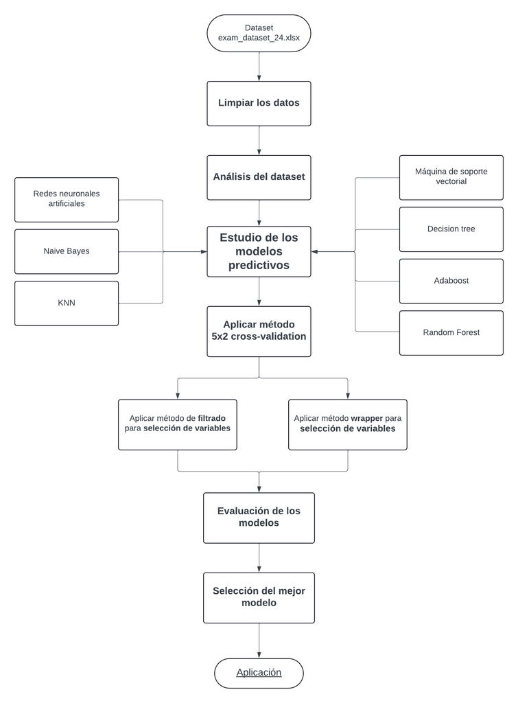

Diagrama de flujo de trabajo

## 1.4 1. Limpiar datos (eliminación de valores erroneos, imputacion de valores faltantes…)

```r
# Cargar el paquete readxl
library(readxl)
# Leer los datos del archivo .xlsx
datos_cancer <- read_excel("exam_dataset_24.xlsx")

# Mostrar las primeras 4 filas de los datos
head(datos_cancer, 4)
```

```
## # A tibble: 4 × 15
##   EDAD_DCO F.DIAG              MENOP  CIRUGIA HISTOLOGIA   TAM GRADO    RE    RP
##      <dbl> <dttm>              <chr>  <chr>   <chr>      <dbl> <dbl> <dbl> <dbl>
## 1       38 2018-08-02 00:00:00 PREME… RADICAL <NA>         4      NA    95    80
## 2       42 2017-04-24 00:00:00 PREME… CONSER… <NA>         2       3     0     0
## 3       63 2018-02-12 00:00:00 POSTM… CONSER… <NA>         1.6     1    80    70
## 4       52 2017-09-19 00:00:00 POSTM… CONSER… <NA>         1.5     3   100    70
## # ℹ 6 more variables: HER2 <chr>, KI67 <dbl>, FENOTIPO <chr>, GANGLIOS <dbl>,
## #   ESTADIO <chr>, ESTADO_ACTUAL <chr>
```

```r
# Guardar los datos iniciales en una nueva variable
datos_iniciales <- datos_cancer

#View(datos_iniciales)
```

## 1.5 Eliminación de datos erroneos:

Dado que hay algunas líneas que tienes demasiados campos vacíos. Sería beneficioso eliminarlas dado que no nos aportan información sobre la variables evento y en el peor de los casos puede empeorar nuestra predicción, debido a que realizaremos la imputación y un alto porcentaje de los campos serán rellenados por media en caso de que la variable sea numérica y moda en caso de que sea categórica.

```r
na_count_per_row <- rowSums(is.na(datos_iniciales))

# Filtrar las filas que tienen más de 5 NAs
datos_iniciales <- datos_iniciales[na_count_per_row <= 5, ]
```

Lo que acabamos de hacer es un filtrado a toda la base de datos, para que en aquellas filas que haya más de 5 campos con NA no se consideren para el dataset.

Ahora procederemos con el filtrado de algunas variables para evitar problemas al entrenar modelos más tarde.

- EDAD: La primera variable que intentaremos estratificar será la edad, por intervalos de 10 en 10 salvo 0-39, dado que a estas edades no es frecuente que se desarrollen células cancerígenas.
- F. DIAG: la fecha de diagnóstico la vamos a dividir en tantos valores como años distintos haya. En este caso, como solo hay 4 años distintos he preferido realizarlo de esta manera. En caso de que los datos tuvieran fechas con más variedad de años lo habría divido por décadas.
- ESTADO_ACTUAL: En el caso de nuestra variable evento, transformaremos todos los valores que empiecen por M en “Exitus” y todos los valores que empiecen por V en “Vivo”. Esto facilitará la predicción del modelo, ya que nos centraremos solo en saber si sobrevivirá o no.
- ESTADIO: El estadio también será importante cambiarlo para evitar tener tantos tipos de Estadios. Dado que hay valores como 0is, los sustituiré por estadio 0. Y ahora agruparemos los diferentes estadios del cáncer en categorías más amplias, lo cual nos es útil para simplificar el análisis y mejorar la interpretabilidad de los resultados. Las agrupaciones son las siguientes:
1. **0-1**: Incluye los estadios 0, I, IA e IB.
2. **II**: Incluye los estadios IIA e IIB.
3. **III**: Incluye los estadios IIIA, IIIB e IIIC.
4. **IV**: Mantiene el estadio IV sin cambios.

```r
library(dplyr)
# Categorizar Edad al diagnóstico
datos_iniciales$EDAD_DCO_CAT <- cut(datos_iniciales$EDAD_DCO,
                                    breaks = c(0, 40, 50, 60, 70, 80, 100),
                                    labels = c("0-39", "40-49", "50-59", "60-69", "70-79", "80+"),
                                    right = FALSE)

# Extraer el año y convertirlo en factor
datos_iniciales$YEAR_DIAG <- as.factor(format(datos_iniciales$F.DIAG, "%Y"))


# Codificar Estado actual
datos_iniciales$ESTADO_ACTUAL <- ifelse(grepl("^M", datos_iniciales$ESTADO_ACTUAL), "Exitus", "Vivo")

# Convertir Estadio en I, II, III y IV
# Crear una nueva categoría '0-1' para agrupar los estadios 0 y 1
# Reemplazar el estadio 'is0' con '0' en la columna ESTADIO para simplificar
datos_iniciales$ESTADIO <- gsub("0is", "0", datos_iniciales$ESTADIO)

# Inicializar la nueva columna ESTADIO_CAT como una copia de ESTADIO
datos_iniciales$ESTADIO_CAT <- datos_iniciales$ESTADIO

# Agrupar los estadios 0 y I (incluyendo IA) en la nueva categoría '0-1'
datos_iniciales$ESTADIO_CAT <- gsub("^0$", "0-1", datos_iniciales$ESTADIO_CAT)
datos_iniciales$ESTADIO_CAT <- gsub("^I$", "0-1", datos_iniciales$ESTADIO_CAT)
datos_iniciales$ESTADIO_CAT <- gsub("^IA$", "0-1", datos_iniciales$ESTADIO_CAT)
datos_iniciales$ESTADIO_CAT <- gsub("^IB$", "0-1", datos_iniciales$ESTADIO_CAT)
datos_iniciales$ESTADIO_CAT <- gsub("IIA|IIB", "II", datos_iniciales$ESTADIO_CAT)
datos_iniciales$ESTADIO_CAT <- gsub("IIIA|IIIB|IIIC", "III", datos_iniciales$ESTADIO_CAT)
datos_iniciales$ESTADIO_CAT <- gsub("IV", "IV", datos_iniciales$ESTADIO_CAT)


# Eliminar las columnas EDAD_DCO, F.DIAG, y ESTADIO
datos_cancer <- datos_iniciales %>%
  dplyr::select(-EDAD_DCO, -F.DIAG, -ESTADIO)
```

## 1.6 Cantidad de datos perdidos

Antes de llevar a cabo la imputación representaremos en una gráfica la cantidad de valores NA que hay en cada clase y ver cuanto impacto tendrá su imputación. Algunas clases debido a la gran cantidad de NA’s pueden acabar desbalanceadas.

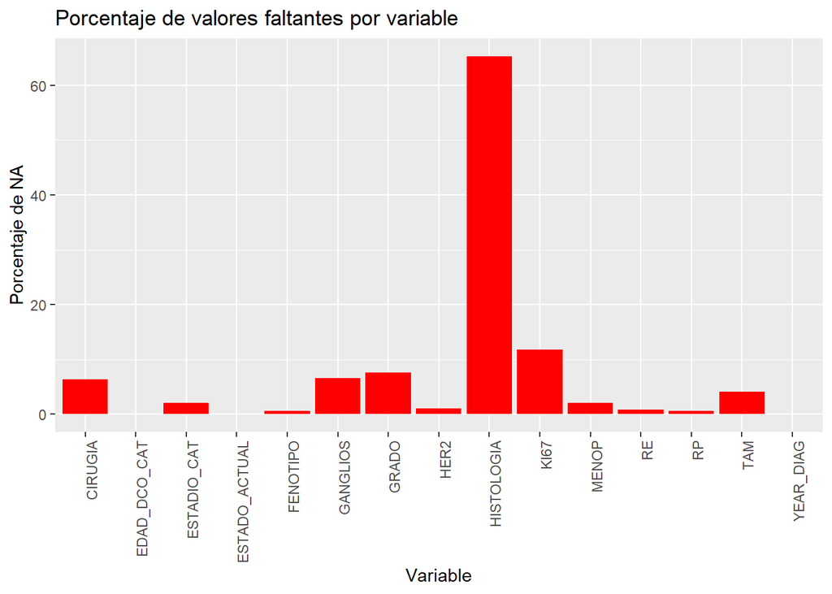

```r
# Calcula el porcentaje de valores faltantes
porcentajes_NA <-  function(datos){
  na_percentage <- colMeans(is.na(datos)) * 100

# Convierte los resultados a un data frame para ggplot
na_df <- data.frame(variable = names(na_percentage), percentage = na_percentage)

# Carga la biblioteca ggplot2
library(ggplot2)

# Crea el gráfico de barras
ggplot(na_df, aes(x = variable, y = percentage)) +
  geom_bar(stat = "identity", fill = "red") +
  theme(axis.text.x = element_text(angle = 90, hjust = 1)) +
  labs(x = "Variable", y = "Porcentaje de NA", title = "Porcentaje de valores faltantes por variable")
}

#summary(datos_cancer)
porcentajes_NA(datos_cancer)
```

Aquí ya podemos ver que HISTOLOGIA tiene varios datos faltantes que nos pueden empeorar los modelos predictivos y podríamos considerar eliminarla si al imputar se desbalancea en exceso los valores de este.

El resto tienen una cantidad de NA que no deberían provocar problemas de desbalanceo debido a la imputación.

## 1.7 Cambios para variables erróneas

La variable Grado se trata como variable numérica y dado que no tiene sentido imputar por la media en esta variable, la transformamos a factor.

La variable KI67 tiene una distribución de frecuencias muy dada para poder categorizarla por intervalos, esto nos ahorrará problemas de tipos de valores que se encuentran en el entrenamiento y no en prueba a la hora de entrenar los modelos predictivos. Con frecuencia se suele usar en medicina una estratificación parecida a la siguiente: 1. Bajo: Ki-67 ≤ 15% 2. Intermedio: Ki-67 entre 16% y 30% 3. Alto: Ki-67 > 30%

La variable GANGLIOS está sumamente desbalanceada por lo que para evitar este problema y el comentado antes para lo modelos predictivos, podríamos considerar realizar una estratificación de la variable binarizándola.

Dado que la variable RE tiene una distribución muy irregular de los datos, ya que está muy divida en extremos, podríamos considerar binarizarla.

Al igual que occurría con RE, a RP le pasa lo mismo. Por lo que podríamos considerar binarizarla tambíen.

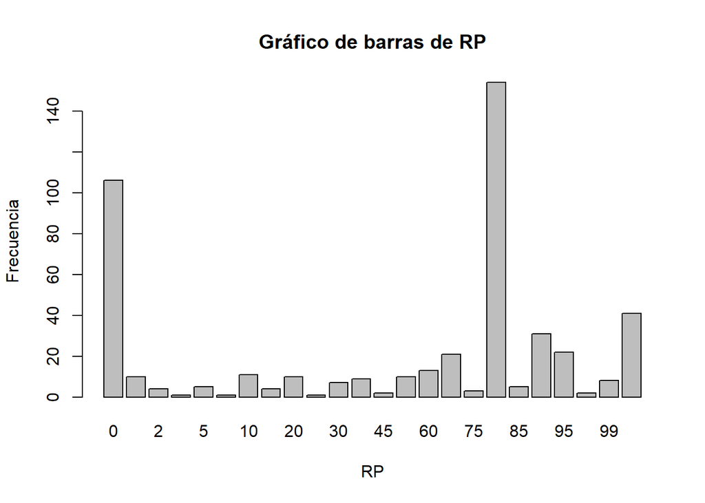

```r
## Gráfico de barras RP
barplot(table(datos_cancer$RP), main = "Gráfico de barras de RP", xlab = "RP", ylab = "Frecuencia")
```

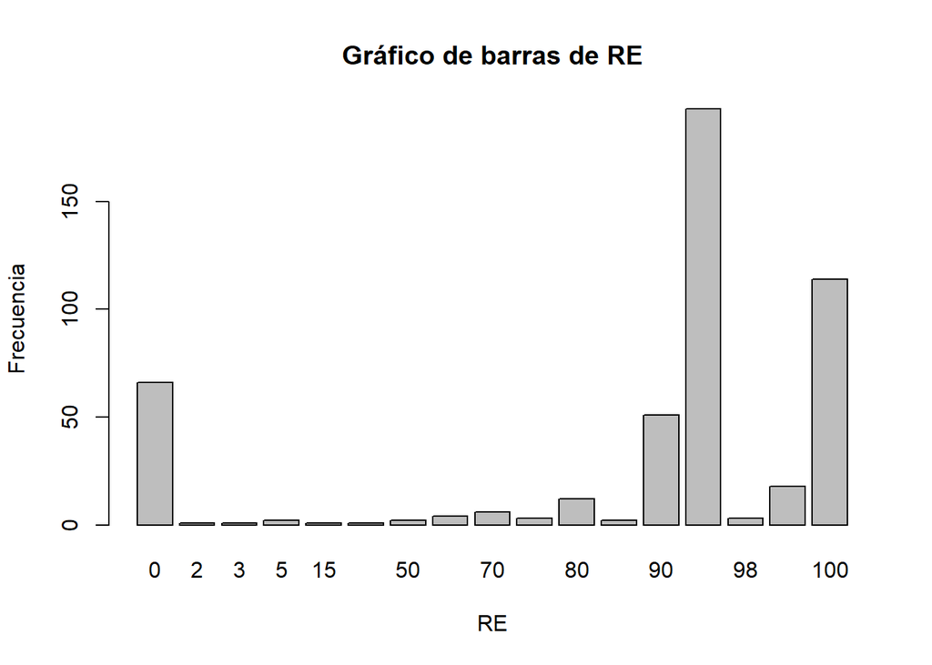

```r
## Gráfico de barras RE
barplot(table(datos_cancer$RE), main = "Gráfico de barras de RE", xlab = "RE", ylab = "Frecuencia")
```

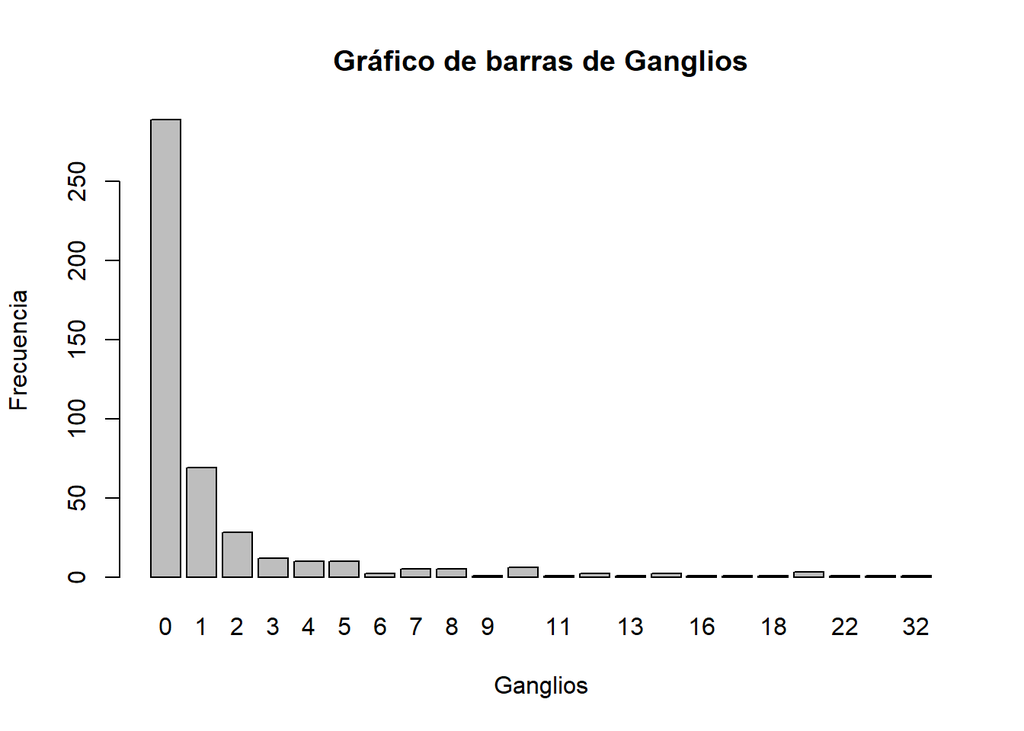

```r
## Gráfico de barras Ganglios
barplot(table(datos_cancer$GANGLIOS), main = "Gráfico de barras de Ganglios", xlab = "Ganglios", ylab = "Frecuencia")
```

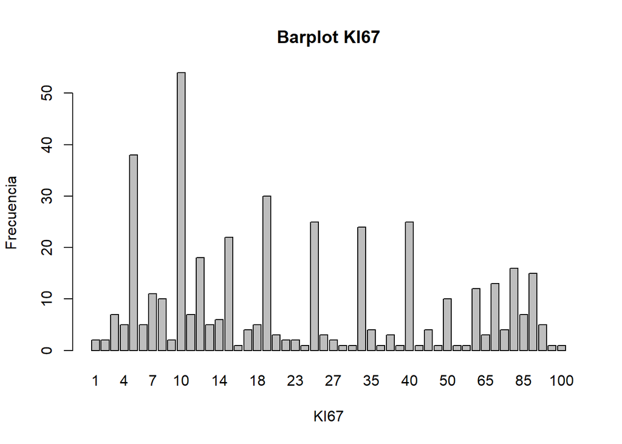

```r
## Barplot Ki-67
barplot(table(datos_cancer$KI67), main = "Barplot KI67", xlab = "KI67", ylab = "Frecuencia")
```

```r
# Reemplazar los valores NA temporalmente para la conversión
datos_cancer$GRADO[is.na(datos_cancer$GRADO)] <- -1

# Convertir la variable GRADO a tipo factor
datos_cancer$GRADO <- factor(datos_cancer$GRADO, levels = c(-1, 1, 2, 3))

# Devolver los valores NA a su lugar original
levels(datos_cancer$GRADO)[levels(datos_cancer$GRADO) == "-1"] <- NA

datos_cancer$KI67 <- cut(datos_cancer$KI67,
                             breaks = c(0, 15, 30, 100),
                             labels = c("Bajo", "Intermedio", "Alto"))
# Binarizar la variable ganglios
datos_cancer$GANGLIOS <- ifelse(datos_cancer$GANGLIOS == 0, "N0", "N+")

# Binarizar las variables RE y RP con un punto de corte del 50%
datos_cancer$RE <- ifelse(datos_cancer$RE > 50, "0-50", "51-100")
datos_cancer$RP <- ifelse(datos_cancer$RP > 50, "0-50", "51-100")

datos_cancer$TAM <- cut(datos_cancer$TAM,
                            breaks = c(0, 2, 4, 30),
                            labels = c("0.3-2", "2.1-4", ">4"))
```

## 1.8 Imputación de los datos

Tras todo este preprocesado, y dado que a nuestra variable evento (ESTADO_ACTUAL) no le faltan datos, procedemos a la imputación de los datos NA, por media en numéricos y por moda en categóricos.

```r
rellenado_NA <- function(dataset) {

  # Convertir los valores nulos "" en NA
  dataset[dataset == ""] <- NA

  # Identificar las columnas (2) con valores ausentes (anyNA)
  columnas_ausentes <- colnames(dataset)[apply(dataset, 2, anyNA)]

  # Imputar valores faltantes por la media para las variables numéricas y la moda para las variables categóricas
  dataset[columnas_ausentes] <- lapply(dataset[columnas_ausentes], function(col) {
    if (is.numeric(col)) {
      media <- mean(col, na.rm = TRUE)  # Calcular la media de la columna
      col[is.na(col)] <- media  # Reemplazar los NA con la media
    } else {
      # Convertir las columnas a factores si no lo son
      if (!is.factor(col)) {
        col <- as.factor(col)
      }
      # Calcular la moda de la columna y reemplazar los NA con la moda
      moda <- names(which.max(table(col)))
      col[is.na(col)] <- moda
    }
    return(col)
  })

  # verificación
  if (anyNA(dataset)) {
    warning("Hubo un error inesperado, por algún motivo no sé relleno correctamente")
  }
  return(dataset)
}


datos_cancer <- rellenado_NA(datos_cancer)
#View(datos_cancer)
```

## 1.9 Más modificaciones de variables

Ahora haremos algunas modificaciones recomendadas en clase, como son; cambiar la forma en la que expresamos el grado reemplazando 1 por I, 2 por II y 3 por III.

```r
# Convertir la columna Grado a tipo carácter
datos_cancer$GRADO <- as.character(datos_cancer$GRADO)

# Realizar los reemplazos
datos_cancer$GRADO <- replace(datos_cancer$GRADO, datos_cancer$GRADO == "1", "I (1)")
datos_cancer$GRADO <- replace(datos_cancer$GRADO, datos_cancer$GRADO == "2", "II (2)")
datos_cancer$GRADO <- replace(datos_cancer$GRADO, datos_cancer$GRADO == "3", "III (3)")
```

# 2 Analisis de cada variable:

```r
generador_graficas_automatico <- function(dato1, nom_col) {
 dato1 <- as.factor(dato1)

 es_cat1 <- is.factor(dato1)

 if (es_cat1) {
    # Gráfico de barras
    barplot(table(dato1), main = paste("Gráfico de barras de", nom_col), xlab = nom_col, ylab = "Frecuencia")

    # Pastel
    pie(table(dato1), cex = 1.5, main = paste("Pastel de:", nom_col))
 } else {
    # Boxplot
    boxplot(dato1, horizontal = TRUE, main = paste("Boxplot de:", nom_col))

    # Histograma
    hist(dato1, main = paste("Histograma de", nom_col), ylab = "Frecuencia", xlab = nom_col)

    # Curva de densidad
    densidad <- density(dato1)
    lines(densidad, col = "black", lwd = 2)

    # Tabla de frecuencias
    tabla_frecuencias <- data.frame(Valor = unique(dato1), Frecuencia = table(dato1))
    print(tabla_frecuencias)
 }
}

# Obtener los nombres de las columnas
nombres_columnas <- colnames(datos_cancer)

#resultados_analisis <- lapply(nombres_columnas, function(nombre_col) {
# generador_graficas_automatico(datos_cancer[[nombre_col]], nombre_col)
#})
```

Si descomentamos el view podremos ver que hay algunas variables que pueden ser interesantes ver su distribución de los datos.

## 2.1 Barplot Ki-67

Puntos de corte comunes en la literatura médica: Bajo: Ki-67 ≤ 15% Intermedio: Ki-67 entre 16% y 30% Alto: Ki-67 > 30%

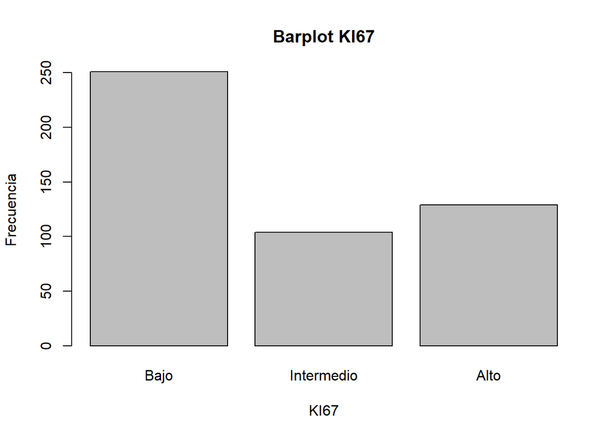

```r
barplot(table(datos_cancer$KI67), main = "Barplot KI67", xlab = "KI67", ylab = "Frecuencia")
```

Los datos de KI67 tras la estratificación salen más proporcionados y útiles para análisis.

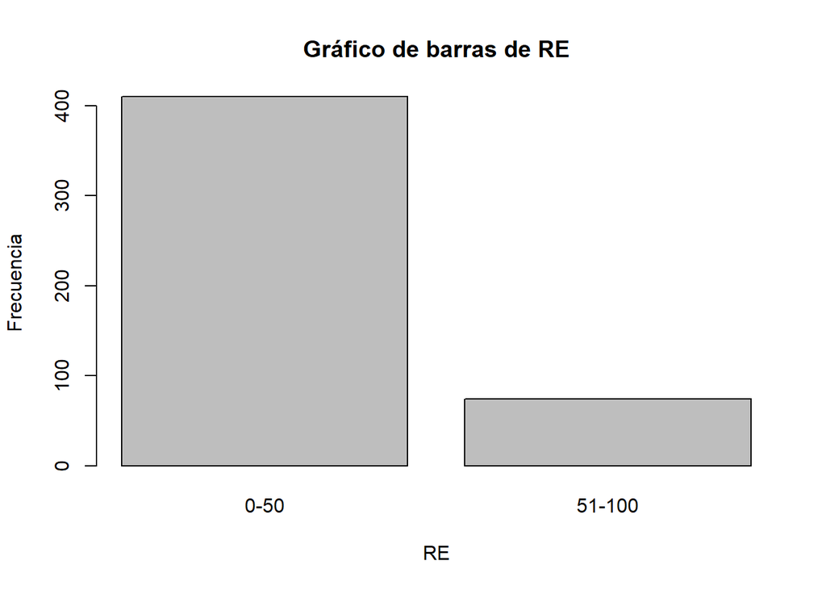

```r
## Gráfico de barras RP
barplot(table(datos_cancer$RE), main = "Gráfico de barras de RE", xlab = "RE", ylab = "Frecuencia")
```

La variable RE sigue desbalanceada, pero al binarizarla hemos conseguido hacer que pueda ser útil para el análisis, aunque podríamos plantear descartarla debido a la diferencia de frecuencia entre clases.

## 2.2 Barplot Estado ActuaL

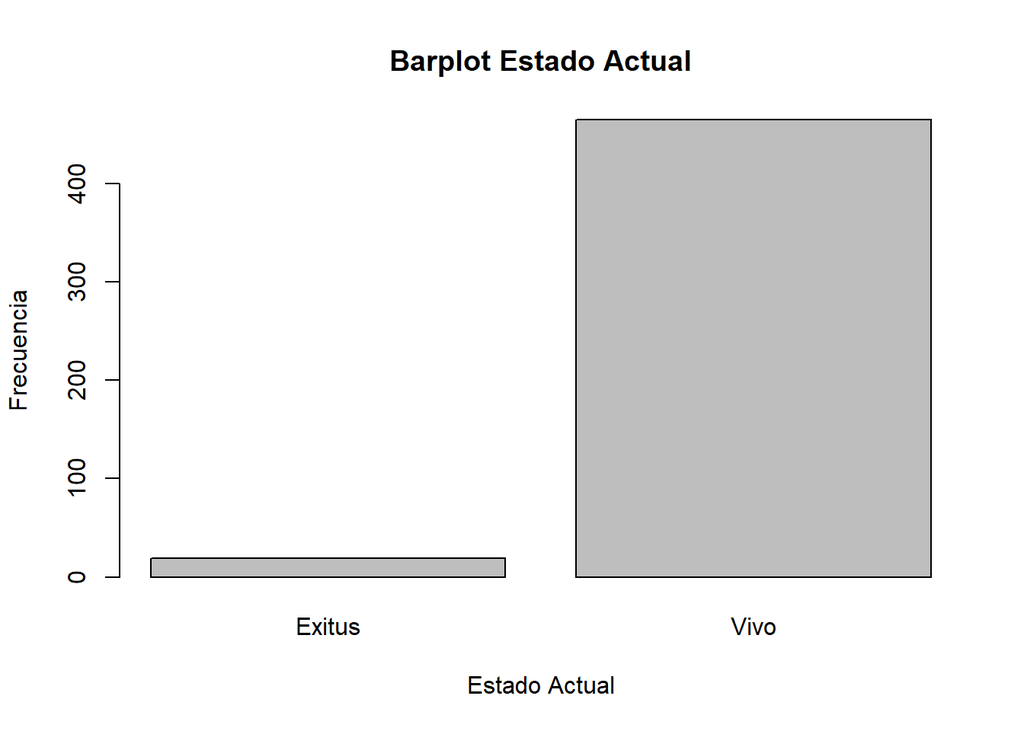

```r
barplot(table(datos_cancer$ESTADO_ACTUAL), main = "Barplot Estado Actual", xlab = "Estado Actual", ylab = "Frecuencia")
```

En ESTADO_ACTUAL es interesante ver que una gran parte de los datos es Vivo, porque nos avisa de que puede provocar errores a la hora de predecir valores con el que modelo no ha sido entrenado, como puede ocurrir cuando todos los valores de entrenamiento sean todos de tipo Vivo y al intentar predecir los de test, que contienen Existus, da error.

## 2.3 Gráfico de barras Ganglios

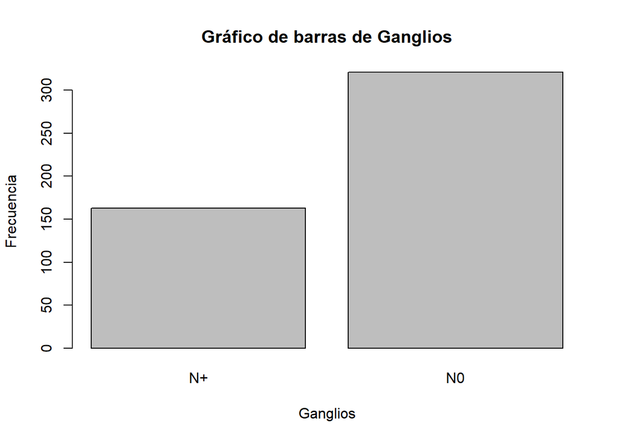

```r
barplot(table(datos_cancer$GANGLIOS), main = "Gráfico de barras de Ganglios", xlab = "Ganglios", ylab = "Frecuencia")
```

También la distribución de los ganglios afectados ha mejorado significativamente y puede llegar a ser utilizada por los modelos predictivos.

## 2.4 **Gráfico de barras Histología**

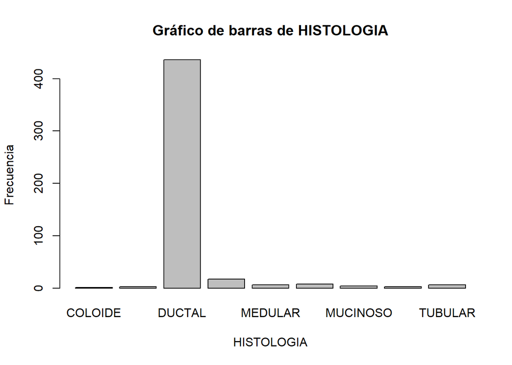

```r
barplot(table(datos_cancer$HISTOLOGIA), main = "Gráfico de barras de HISTOLOGIA", xlab = "HISTOLOGIA", ylab = "Frecuencia")
```

Histología podríamos considerar eliminarla de nuestra tabla de datos, ya que la variable estaba desbalanceada desde el principio y al imputar por la moda, ayuda a que el valor DUCTAL sea todavía más frecuente que el resto de valores, por lo que la información que nos puede aportar sobre la variable evento es prácticamente nula.

## 2.5 2. Aplicar stepAIC (el resultado de las variables correlacionadas dara lugar al modelo)

Antes de realizar este estudio, arreglaré aquellas variables que he comentado antes para intentar mejorar la predicción y rapidez de los modelos.

A parte de modificar estas variables hemos considerado eliminar histología dado a su poca aportación al estudio. Para realizar estos estudios con stepAIC es necesario binarizar numéricamente con 0 y 1 la variable evento, ya que con Vivo y Exitus no es capaz de entender que la variable está binarizada. Así que Vivo tomará el valor de 0 y Existus el valor de 1.

Antes de aplicar la función StepAIC, lo que haremos será utilizar un modelo de regresión logística que estará entrenado con el 100% de los datos de nuestra tabla y en función de nuestro modelo entrenado podremos ver que variables aportan más información en la predicción de valores de ESTADO_ACTUAL, por eso en la función stepAIC metemos como argumento el modelo.

```r
library(dplyr)

# Convertir ESTADO_ACTUAL a binario (0 para "Vivo", 1 para "Exitus")
datos_cancer$ESTADO_ACTUAL_BIN <- ifelse(datos_cancer$ESTADO_ACTUAL == "Vivo", 0, 1)

# Verificar la conversión
table(datos_cancer$ESTADO_ACTUAL, datos_cancer$ESTADO_ACTUAL_BIN)
```

```
##
##            0   1
##   Exitus   0  19
##   Vivo   465   0
```

```r
# Eliminar las columnas EDAD_DCO, F.DIAG, y ESTADIO
datos_cancer <- datos_cancer %>%
  dplyr::select( -ESTADO_ACTUAL)

# Cargar la librería MASS
library(MASS)
```

```r
# Eliminar la columna HISTOLOGIA
datos_cancer_def <- subset(datos_cancer, select = -HISTOLOGIA)

# Ajustar el modelo de regresión logística
lr.fit1 <- glm(ESTADO_ACTUAL_BIN ~ ., data = datos_cancer_def, family = binomial("logit"))

# Resumen del modelo
summary(lr.fit1)
```

```
##
## Call:
## glm(formula = ESTADO_ACTUAL_BIN ~ ., family = binomial("logit"),
##     data = datos_cancer_def)
##
## Deviance Residuals:
##      Min        1Q    Median        3Q       Max
## -1.50857  -0.10720  -0.02617  -0.00709   2.67893
##
## Coefficients: (1 not defined because of singularities)
##                           Estimate Std. Error z value Pr(>|z|)
## (Intercept)               -1.87707 3193.99580  -0.001  0.99953
## MENOPPREMENOPAUSICA       -1.07529    1.48515  -0.724  0.46905
## CIRUGIARADICAL            -0.03859    0.82160  -0.047  0.96254
## TAM2.1-4                   0.53549    1.14432   0.468  0.63981
## TAM>4                      1.39674    1.40080   0.997  0.31872
## GRADOII (2)               -0.07925    1.09113  -0.073  0.94210
## GRADOIII (3)               0.43798    1.14024   0.384  0.70090
## RE51-100                 -14.37143 2736.50785  -0.005  0.99581
## RP51-100                   0.47266    1.04145   0.454  0.64994
## HER2P                      3.24991    1.82652   1.779  0.07519 .
## KI67Intermedio            -0.64125    1.21662  -0.527  0.59814
## KI67Alto                   0.19790    1.22144   0.162  0.87129
## FENOTIPOLUMINAL A        -14.74927 2736.50825  -0.005  0.99570
## FENOTIPOLUMINAL B        -13.28780 2736.50796  -0.005  0.99613
## FENOTIPOLUMINAL HER2     -17.73140 2736.50822  -0.006  0.99483
## FENOTIPOLUMINAL ND       -14.04226 2736.50817  -0.005  0.99591
## FENOTIPOTRIPLE NEGATIVO         NA         NA      NA       NA
## GANGLIOSN0                -3.20250    1.12395  -2.849  0.00438 **
## EDAD_DCO_CAT40-49         16.68503 1647.15852   0.010  0.99192
## EDAD_DCO_CAT50-59         16.05904 1647.15883   0.010  0.99222
## EDAD_DCO_CAT60-69         17.84427 1647.15925   0.011  0.99136
## EDAD_DCO_CAT70-79         19.05134 1647.15939   0.012  0.99077
## EDAD_DCO_CAT80+           20.69818 1647.15961   0.013  0.98997
## YEAR_DIAG2006             -1.65322    0.89912  -1.839  0.06596 .
## YEAR_DIAG2017             -8.08680    1.98001  -4.084 4.42e-05 ***
## YEAR_DIAG2018             -6.84440    1.70941  -4.004 6.23e-05 ***
## ESTADIO_CATII             -1.27488    1.43972  -0.886  0.37588
## ESTADIO_CATIII            -2.14505    1.82036  -1.178  0.23865
## ESTADIO_CATIV              3.69655    1.58124   2.338  0.01940 *
## ---
## Signif. codes:  0 '***' 0.001 '**' 0.01 '*' 0.05 '.' 0.1 ' ' 1
##
## (Dispersion parameter for binomial family taken to be 1)
##
##     Null deviance: 160.275  on 483  degrees of freedom
## Residual deviance:  78.746  on 456  degrees of freedom
## AIC: 134.75
##
## Number of Fisher Scoring iterations: 18
```

```r
# Realizar selección de variables utilizando stepAIC
modelo_seleccionado <- stepAIC(lr.fit1, direction = "backward")
```

```
## Start:  AIC=134.75
## ESTADO_ACTUAL_BIN ~ MENOP + CIRUGIA + TAM + GRADO + RE + RP +
##     HER2 + KI67 + FENOTIPO + GANGLIOS + EDAD_DCO_CAT + YEAR_DIAG +
##     ESTADIO_CAT
##
##
## Step:  AIC=134.75
## ESTADO_ACTUAL_BIN ~ MENOP + CIRUGIA + TAM + GRADO + RE + RP +
##     KI67 + FENOTIPO + GANGLIOS + EDAD_DCO_CAT + YEAR_DIAG + ESTADIO_CAT
##
##                Df Deviance    AIC
## - FENOTIPO      5   84.222 130.22
## - GRADO         2   79.120 131.12
## - KI67          2   79.300 131.30
## - TAM           2   79.742 131.74
## - CIRUGIA       1   78.749 132.75
## - RE            1   78.903 132.90
## - RP            1   78.945 132.94
## - MENOP         1   79.301 133.30
## <none>              78.746 134.75
## - EDAD_DCO_CAT  5   94.423 140.42
## - ESTADIO_CAT   3   91.343 141.34
## - GANGLIOS      1   88.172 142.17
## - YEAR_DIAG     3  131.521 181.52
##
## Step:  AIC=130.22
## ESTADO_ACTUAL_BIN ~ MENOP + CIRUGIA + TAM + GRADO + RE + RP +
##     KI67 + GANGLIOS + EDAD_DCO_CAT + YEAR_DIAG + ESTADIO_CAT
##
##                Df Deviance    AIC
## - KI67          2   84.390 126.39
## - TAM           2   84.754 126.75
## - GRADO         2   84.913 126.91
## - CIRUGIA       1   84.238 128.24
## - RP            1   84.519 128.52
## - RE            1   84.589 128.59
## - MENOP         1   85.047 129.05
## <none>              84.222 130.22
## - EDAD_DCO_CAT  5  100.277 136.28
## - ESTADIO_CAT   3   96.310 136.31
```

[output cut: 84 more lines]

```
## <none>              87.269 115.27
## - ESTADIO_CAT   3  100.615 122.61
## - GANGLIOS      1   97.001 123.00
## - EDAD_DCO_CAT  5  110.146 128.15
## - YEAR_DIAG     3  144.264 166.26
##
## Step:  AIC=114.69
## ESTADO_ACTUAL_BIN ~ GANGLIOS + EDAD_DCO_CAT + YEAR_DIAG + ESTADIO_CAT
##
##                Df Deviance    AIC
## <none>              88.689 114.69
## - ESTADIO_CAT   3  101.356 121.36
## - GANGLIOS      1   98.063 122.06
## - EDAD_DCO_CAT  5  110.195 126.19
## - YEAR_DIAG     3  145.103 165.10
```

```r
# Resumen del modelo seleccionado
summary(modelo_seleccionado)
```

```
##
## Call:
## glm(formula = ESTADO_ACTUAL_BIN ~ GANGLIOS + EDAD_DCO_CAT + YEAR_DIAG +
##     ESTADIO_CAT, family = binomial("logit"), data = datos_cancer_def)
##
## Deviance Residuals:
##      Min        1Q    Median        3Q       Max
## -1.61944  -0.13795  -0.04225  -0.01734   2.79021
##
## Coefficients:
##                    Estimate Std. Error z value Pr(>|z|)
## (Intercept)        -16.3744  1746.7393  -0.009  0.99252
## GANGLIOSN0          -2.7953     0.9751  -2.867  0.00415 **
## EDAD_DCO_CAT40-49   16.5153  1746.7392   0.009  0.99246
## EDAD_DCO_CAT50-59   16.2737  1746.7391   0.009  0.99257
## EDAD_DCO_CAT60-69   17.5824  1746.7392   0.010  0.99197
## EDAD_DCO_CAT70-79   18.7089  1746.7392   0.011  0.99145
## EDAD_DCO_CAT80+     20.1670  1746.7393   0.012  0.99079
## YEAR_DIAG2006       -0.9761     0.6622  -1.474  0.14051
## YEAR_DIAG2017       -6.5047     1.6277  -3.996 6.44e-05 ***
## YEAR_DIAG2018       -5.5845     1.3703  -4.075 4.60e-05 ***
## ESTADIO_CATII       -0.7109     0.8863  -0.802  0.42249
## ESTADIO_CATIII      -1.3360     1.2260  -1.090  0.27583
## ESTADIO_CATIV        3.8090     1.3894   2.741  0.00612 **
## ---
## Signif. codes:  0 '***' 0.001 '**' 0.01 '*' 0.05 '.' 0.1 ' ' 1
##
## (Dispersion parameter for binomial family taken to be 1)
##
##     Null deviance: 160.275  on 483  degrees of freedom
## Residual deviance:  88.689  on 471  degrees of freedom
## AIC: 114.69
##
## Number of Fisher Scoring iterations: 18
```

## 2.6 3. Funcion para devolver parametros; accuracy, recall, sensibilidad y especificidad. En funcion de la matriz de confusion

Ahora procedemos a utilizar nuestro modelo para ver como es su rendimiento con la matriz de confusión. Primero utilizaremos nuestro modelo para intertar predecir el conjunto entero de datos, que habíamos utilizado para entrenarlo.

“predicciones” lo que tendrá son probabilidades de que la fila que está intentando predecir sea ESTADO_ACTUAL=1. Esas probabilidades se clasificarán en 0 (Vivo) y 1 (Exitus) dependiendo de un umbral, en caso de que la probabilidad supere 0.5 (que es comúnmente utilizado como punto de corte en problemas de clasificación binaria) el valor que tomará será 1 y de lo contrario será 0.

Posteriormente contruimos la matriz de confusión en la que iremos viendo en que ha fallado y acertado nuestro modelo, comparando los valores de predicted classes y los datos de nuestro dataset (clases reales).

Por último, desarrollamos una función que calcule los parametros accuracy, recall, precision, especificidad, f1_score y el area bajo la curva ROC (AUC).

Antes de trabajar con estos parámetros es preciso definirlos:

- Accuracy: es la proporción de predicciones correctas (verdaderos positivos más verdaderos negativos) sobre el total de predicciones.
- Recall: mide la capacidad del modelo para detectar correctamente los casos positivos. Un alto valor de recall indica que el modelo es capaz de identificar la mayoría de los casos positivos reales, lo que implica que hay pocos casos de la enfermedad que pasan desapercibidos (falsos negativos).
- Especificidad: indica la capacidad de un modelo para detectar correctamente los casos negativos.
- Precisión: mide la proporción de predicciones correctas positivas realizadas por el modelo de clasificación entre todas las predicciones positivas que hizo.

La diferencia entre el accuracy y precision, es que accuracy nos informa de como de preciso ha sido a nivel global el modelo a la hora de clasificar tanto casos positivos como negativos, mientras que precision solo se centra en los positivos, es decir, en cuántas de las instancias clasificadas como positivas realmente lo son.

- F1_Score: medida que combina la precisión y la sensibilidad de un modelo en una sola métrica. Si el valor es próximo a 1 significa, ya que indica un buen equilibrio entre precisión y sensibilidad.
- Curva ROC: es una representación gráfica de la capacidad de un modelo para discriminar entre clases positivas y negativas a varios umbrales de clasificación.Cada punto en la curva representa un umbral diferente. Cuanto más cerca esté la curva ROC del vértice superior izquierdo, mejor será el rendimiento del modelo, ya que indica una alta sensibilidad y una baja tasa de falsos positivos.
- Área bajo la curva (AUC): mide la capacidad del modelo de discriminar entre clases positivas y negativas.Un AUC de 1 indica un modelo perfecto que puede distinguir perfectamente entre las clases, mientras que un AUC de 0.5 indica un rendimiento similar al azar, donde el modelo no es capaz de hacer una distinción significativa entre las clases.

```r
crear_confusion_matrix <- function(ground_truth, predicted_classes) {
  conf_matrix <- table(ground_truth, predicted_classes)

  # Comprobar si la matriz de confusión es 2x1
  if (ncol(conf_matrix) == 1 && nrow(conf_matrix) == 2) {
    # Crear una matriz de confusión 2x2 rellenada con ceros
    new_conf_matrix <- matrix(0, nrow = 2, ncol = 2, dimnames = list(c("0", "1"), c("0", "1")))
    # Copiar los valores de la matriz original a la nueva matriz
    new_conf_matrix[, 1] <- conf_matrix[, 1]
    conf_matrix <- new_conf_matrix
  }

  return(conf_matrix)
}
```

```r
library(pROC)
# Realizar predicciones en el conjunto de prueba
predicciones <- predict(lr.fit1, newdata = datos_cancer_def, type = "response")

# Evaluar el rendimiento del modelo
predicted_classes <- ifelse(predicciones > 0.5, 1, 0)#utilizamos un umbral de 0.5 para accuracy
conf_matrix <- table(datos_cancer_def$ESTADO_ACTUAL_BIN, predicted_classes)

print("La matriz confusión:")
```

```
## [1] "La matriz confusión:"
```

```r
print(conf_matrix)
```

```
##    predicted_classes
##       0   1
##   0 461   4
##   1  14   5
```

```r
# Función para calcular los parámetros de evaluación
calcular_param_val <- function(datos_pcr, predicted_classes) {
  #EN CASO DE TENER LA SEGUNDA COLUMNA VACIA RELLENAMOS TODO CON 0.
  suppressWarnings(matriz_confusion <- crear_confusion_matrix(datos_pcr, predicted_classes))

  #TP + TN / (TP + FP + FN + TN)
  accuracy <- round(sum(diag(matriz_confusion)) / sum(matriz_confusion), digits = 2)

  #TP/(TP+FN)
  recall <- round(matriz_confusion[2, 2] / sum(matriz_confusion[2, ]), digits = 2)

  #TP/TP+FP
  precision <- round(matriz_confusion[2, 2] / sum(matriz_confusion[, 2]), digits = 2)

  #TN/TN+FP
  specificity <- round(matriz_confusion[1, 1] / sum(matriz_confusion[1, ]), digits = 2)

  # Calcular el F1-score
  f1_score <- round(2 * (precision * recall) / (precision + recall), digits = 2)

  # Calcular la curva roc
  if (length(unique(datos_pcr)) == 2) {
    roc_obj <- roc(datos_pcr, predicted_classes)
    # Valor del área bajo la curva (AUC)
    auc_value <- round(auc(roc_obj), digits = 3)
  } else {
    auc_value <- NA
  }

  return(c(accuracy, recall, specificity, f1_score, precision, auc_value))
}

# Función para imprimir los parámetros de evaluación
imprimir_param_eval <- function(calc){
    cat("Parámetros de evaluación del modelo:",
      paste("Accuracy:", calc[1]),
      paste("Recall:", calc[2]),
      paste("Specificity:", calc[3]),
      paste("F1-score:", calc[4]),
      paste("Precision:", calc[5]),
      paste("Área bajo la curva ROC (AUC):", ifelse(is.na(calc[6]), "No calculable", calc[6])),
      "\n")
}

# Calcular los parámetros de evaluación
calc <- calcular_param_val(datos_cancer_def$ESTADO_ACTUAL_BIN, predicted_classes)

# Imprimir los parámetros de evaluación
imprimir_param_eval(calc)
```

```
## Parámetros de evaluación del modelo: Accuracy: 0.96 Recall: 0.26 Specificity: 0.99 F1-score: 0.36 Precision: 0.56 Área bajo la curva ROC (AUC): 0.627
```

En la matriz de confusión nos sale un resultado que esperábamos.El modelo ha sido capaz de predecir una gran parte de las filas cuyo valor de ESTADO_ACTUAL era 0 (una tasa considerable de TN con 461 acertadas frente a las 4 falladas), pero las que tenían ESTADO_ACTUAL=1 no ha sido satisfactorio, ya que la mayoría de predicciones han fallado (5 aciertos frente a 14 fallos). Esto se debe a que la clase está desbalanceada, por lo que clasifica mejor aquellas filas que tenga valor ESTADO_ACTUAL=0, porque en nuestro dataset hay más filas con valores ESTADO_ACTUAL de 0 que de 1.

Aunque hayamos tenido un buen valor de accuracy, el valor de AUC es aceptable, lejos de ser azar, pero no es suficiente para considerarla buena, esto ocurre por lo dicho anteriormente. El dataset al no tener muchas filas con ESTADO_ACTUAL=1, el modelo no es capaz de diferenciar con exactitud entre ambas clases. Y esto no lo estaba avisando los parámetros de Recall, que era bajo (no es capaz de detectar correctamente los casos positivos) y la especificidad que era muy alta.

Creamos una función que será utilizada más adelante en la partición de los datos, para aquellos casos en los datos prueba no contemple valores 1 para ESTADO_ACTUAL. Esto puede ocurrir cuando al hacer la division, el modelo entrena con todas las filas cuyos valores de ESTADO_ACTUAL=1 y luegos los datos de prueba solo tienen ESTADO_ACTUAL=0.

Esta función en caso de que falte la columna de 1 a la matriz lo rellena todo con valor de 0, para que pueda calcular los parametros y podamos ver el rendimiento.

## 2.7 4.Oversampling

También tenemos que contemplar el oversampling para ver que ocurriría con el rendimiento del modelo si igualamos el número de ejemplos de clases minoritarias con el de las mayoritarias.

```r
oversample_data <- function(data, target_col,semilla=11) {
  set.seed(semilla)
  # Dividir el conjunto de datos en instancias positivas y negativas
  positive_instances <- data[data[[target_col]] == 1, ]
  negative_instances <- data[data[[target_col]] == 0, ]

  # Calcular el número de instancias positivas y negativas
  num_positive <- nrow(positive_instances)
  num_negative <- nrow(negative_instances)

  # Determinar cuál es la clase menos representada
  minority_class <- ifelse(num_positive < num_negative, 1, 0)

  # Determinar cuántas instancias adicionales necesitamos generar
  num_to_generate <- abs(num_positive - num_negative)

  # Realizar oversampling generando instancias adicionales aleatorias de la clase menos representada
  if (minority_class == 1) {
    additional_samples <- positive_instances[sample(num_positive, num_to_generate, replace = TRUE), ]
  } else {
    additional_samples <- negative_instances[sample(num_negative, num_to_generate, replace = TRUE), ]
  }

  # Combinar el conjunto de datos original con las instancias adicionales
  oversampled_data <- rbind(data, additional_samples)

  return(oversampled_data)
}
datos_oversampling= oversample_data(datos_cancer_def,"ESTADO_ACTUAL_BIN")
```

## 2.8 5. Método Re-HoldOut y HoldOut

Antes habíamos comprobado el rendimiento del modelo de regresión logística para todo el conjunto de datos, ahora probaremos a dividir el dataset en conjunto de entrenamiento y otro de test.

Haremos una función que permita hacer HoldOut y Re-HoldOut

El método de HoldOut consiste en dividir el conjunto de los datos en test y entrenamiento. Para ello tendremos que definir la proporcion que tenemos que utilizar para esa división. Dado que tenemos varias opciones 60/40, 70/30 y 80/20 que son las más eficaces, lo que haremos será utilizar una proporcion e ir evaluando cual tiene mejor AUC de las tres proporciones.

En la función hemos metido un parametro de entrada que sea para el número de repeticiones, esto es para el Re-HOldOut. Este método consiste en hacer el HoldOut múltiples repeticiones. Este método nos es útil dado que la partición de los datos conlleva un factor aleatorio y repetir varias veces el mismo método nos ayuda a que los resultados sean más consistentes. Entonces lo que haremos será hacer la media de las metricas cuando hay múltiples repeticiones y hacer esto mismo con las 3 distintas porciones que hay.

```r
library(MASS)
library(caret)
library(pROC)

# Definir la función HoldOut
HoldOut <- function(datos, num_repeticiones = 1, semilla = 11, mostrar_resultado = TRUE) {
  set.seed(semilla)
  proporciones <- c(0.6, 0.7, 0.8)
  mejor_proporcion <- 0
  mejor_AUC <- 0
  mejores_parametros <- NULL

  for (proporcion_entrenamiento in proporciones) {
    parametros_mejor_AUC <- NULL
    metrics <- NULL

    for (i in 1:num_repeticiones) {
      # Dividir los datos en conjuntos de entrenamiento y prueba
      indices <- createDataPartition(datos$ESTADO_ACTUAL_BIN, p = proporcion_entrenamiento, list = FALSE)
      datos_entrenamiento <- datos[indices, ]
      datos_prueba <- datos[-indices, ]

      # Entrenar el modelo de regresión logística sin la columna Muestra
      modelo <- glm(ESTADO_ACTUAL_BIN ~ ., data = datos_entrenamiento, family = "binomial")

      # Realizar predicciones en el conjunto de prueba
      predicciones <- predict(modelo, newdata = datos_prueba, type = "response")
      predicted_classes <- ifelse(predicciones > 0.5, 1, 0)

      # Calcular la matriz de confusión
      current_metrics <- calcular_param_val(datos_prueba$ESTADO_ACTUAL_BIN, predicted_classes)
      # Calcular las métricas
      # <- calcular_param_roc(conf_matrix)

      # Add current fold metrics to the overall metrics
      if (is.null(metrics)) {
        metrics <- current_metrics
      } else {
        metrics <- metrics + current_metrics
        }
    }

    # Calcular la precisión promedio para esta proporción
    AUC_promedio <- metrics[6] / num_repeticiones
    # Actualizar la mejor proporción si se encuentra una precisión mejor
    if (AUC_promedio > mejor_AUC) {
      mejor_AUC <- AUC_promedio
      mejor_proporcion <- proporcion_entrenamiento
      mejores_parametros <- metrics/num_repeticiones
    }
  }

   if (mostrar_resultado) {
    cat("La mejor proporción es", mejor_proporcion, "con un AUC promedio de", mejor_AUC, "\n")
  }
  mejores_parametros <- round(mejores_parametros, digits = 2)
  # Devolver la mejor precisión y los demás parámetros para esa precisión
  return(mejores_parametros)
}

print("Datos oversampled AUC: ")
```

```
## [1] "Datos oversampled AUC: "
```

```r
parametros <- HoldOut(datos_oversampling,num_repeticiones = 3,semilla = 11,mostrar_resultado = TRUE)
```

```
## La mejor proporción es 0.7 con un AUC promedio de 0.9676667
```

```r
imprimir_param_eval(parametros)
```

```
## Parámetros de evaluación del modelo: Accuracy: 0.97 Recall: 1 Specificity: 0.94 F1-score: 0.97 Precision: 0.94 Área bajo la curva ROC (AUC): 0.97
```

```r
print("Datos Re-HoldOut AUC: ")
```

```
## [1] "Datos Re-HoldOut AUC: "
```

```r
parametros <- HoldOut(datos_cancer_def,num_repeticiones = 3,semilla = 11,mostrar_resultado = TRUE)
```

```
## La mejor proporción es 0.6 con un AUC promedio de 0.6436667
```

```r
imprimir_param_eval(parametros)
```

```
## Parámetros de evaluación del modelo: Accuracy: 0.94 Recall: 0.33 Specificity: 0.96 F1-score: 0.23 Precision: 0.18 Área bajo la curva ROC (AUC): 0.64
```

```r
print("Datos HoldOut AUC: ")
```

```
## [1] "Datos HoldOut AUC: "
```

```r
parametros <- HoldOut(datos_cancer_def,num_repeticiones = 1,semilla = 11,mostrar_resultado = TRUE)
```

```
## La mejor proporción es 0.6 con un AUC promedio de 0.621
```

```r
imprimir_param_eval(parametros)
```

```
## Parámetros de evaluación del modelo: Accuracy: 0.93 Recall: 0.29 Specificity: 0.96 F1-score: 0.24 Precision: 0.2 Área bajo la curva ROC (AUC): 0.62
```

```r
print("Datos del modelo seleccionados AUC: ")
```

```
## [1] "Datos del modelo seleccionados AUC: "
```

```r
parametros <- HoldOut(modelo_seleccionado$model,num_repeticiones = 3,semilla = 11,mostrar_resultado = TRUE)
```

```
## La mejor proporción es 0.8 con un AUC promedio de 0.604
```

```r
imprimir_param_eval(parametros)
```

```
## Parámetros de evaluación del modelo: Accuracy: 0.95 Recall: 0.22 Specificity: 0.99 F1-score: 0.29 Precision: 0.44 Área bajo la curva ROC (AUC): 0.6
```

Hemos probado los datos oversampled, los datos sin oversampling y datos del modelo seleccionado.

Con los datos del modelo seleccionado el AUC empeora un poco con respecto al uso de todo el dataset, esto puede deberse a que hay otras variables que aunque no sean tan importantes como year_diag, estadio y ganglios, también aportan información importante para ESTADO_ACTUAL, por lo que mejor utilizaremos de aquí en adelante el dataset con todas las variables, para otros métodos de validación.

Con la prueba de oversampling, obtenemos unos muy buenos resultados, pero acosta de tener la posibilidad de dar un pronóstico fallido de la vida de la persona. El modelo está bien entrenado y sabe diferenciar bien entre clases, pero la contraparte es que los datos son generados sintéticamente, por lo que habría que pensar si realmente nos interesaría utilizar este modelo. Al final la información de la que dispongamos juega un papel importantísimo en el rendimiento de este tipo de modelos, y es por eso por lo que las compañías invierten mucho capital en conseguirla.

## 2.9 6. K-fold Cross-Validaton

La idea del método de K-fold Cross-Validaton es dividir los datos en varios trozos múltiples veces. Me explico, en el caso de que tengamos un K=5 y un dataset de 500 filas, hará un corte de 100 filas (500/k=5) que se utilizará para prueba y el resto (400) será para entrenamiento, luego hará otro corte de las siguientes 100 filas y el resto de 400 se utilizarán para entrenamiento dentro de esas 400 estarían las 100 que se han utilizado antes como prueba. En resumen, sería una ventana deslizante de 100 de espacio, en el que contuviera aquellas filas que se van a utilizar para test y el resto fuera para entrenamiento, entonces nos quedaremos con la media de las métricas de todas esas particiones de los datos.

```r
# Función para realizar k-fold cross-validation
k_fold_cross_validation <- function(data, k = 10, semilla = 11) {
  set.seed(semilla)
  shuffled_data <- data[sample(nrow(data)), ]
  fold_size <- floor(nrow(data) / k)

  metrics <- NULL

  for (i in 1:k) {
    # Definir los índices de inicio y fin para el fold actual
    start_index <- ((i - 1) * fold_size) + 1
    end_index <- min(i * fold_size, nrow(data))

    # Extraer el fold actual para validación
    validation_data <- shuffled_data[start_index:end_index, ]

    # Usar el resto de los datos para entrenamiento
    training_data <- rbind(shuffled_data[1:(start_index-1), ], shuffled_data[(end_index+1):nrow(shuffled_data), ])

    # Entrenar el modelo en los datos de entrenamiento (usando el modelo por defecto)
    model <- glm(ESTADO_ACTUAL_BIN ~ ., data = training_data, family = "binomial")

    # Realizar predicciones en el conjunto de validación
    predicted_probs <- predict(model, newdata = validation_data, type = "response")
    predicted_classes <- ifelse(predicted_probs > 0.5, 1, 0)

    # Calcular métricas
    current_metrics <- calcular_param_val(validation_data$ESTADO_ACTUAL_BIN, predicted_classes)

    # Añadir las métricas del fold actual a las métricas generales
    if (is.null(metrics)) {
      metrics <- current_metrics
    } else {
      metrics <- metrics + current_metrics
    }
  }

  # Calcular la media de las métricas
  metrics_mean <- metrics / k

  # Retornar las métricas medias
  return(metrics_mean)
}

# Asegúrate de que ESTADO_ACTUAL_BIN sea un factor binario con los niveles correctos
datos_cancer_def$ESTADO_ACTUAL_BIN <- factor(datos_cancer_def$ESTADO_ACTUAL_BIN, levels = c(0, 1))

# Realizar k-fold cross-validation
calc <- k_fold_cross_validation(datos_cancer_def)
imprimir_param_eval(calc) # Mostrar resultados
```

```
## Parámetros de evaluación del modelo: Accuracy: 0.942 Recall: 0.083 Specificity: 0.975 F1-score: NaN Precision: NaN Área bajo la curva ROC (AUC): 0.5284
```

En este caso nos ha salido un rendimiento pésimo, clasificando las clases prácticamente al azar.Esto podría producirse por que la variable evento está sumamente desbalanceada. Se necesitarían más datos para poder clasificar bien las clases.

## 2.10 7. Fuerza bruta

Por probar otros métodos por si mejora el rendimiento del modelo, probamos el de Fuerza bruta. Está función analizará todas las combinaciones posibles de variables evaluando las métricas. Nos devolverá una tabla con todas métricas.

```r
buscar_todos_modelos <- function(datos, variable_evento, num_rep=0, folds=0) {
  # Obtener todas las combinaciones de variables predictoras
  variables <- colnames(datos)
  variables <- variables[variables != variable_evento]  # Excluir la variable objetivo
  combinaciones <- lapply(1:length(variables), function(n) combn(variables, n))

  # Inicializar una lista para almacenar los resultados
  resultados <- list()

  # Iterar sobre todas las combinaciones
  for (i in 1:length(combinaciones)) {
    for (j in 1:ncol(combinaciones[[i]])) {
      predictoras <- c(combinaciones[[i]][, j], variable_evento)
      datos_filtrados <- datos[, predictoras]

        if (num_rep != 0) {
         # Llamar a la función HoldOut con num_repeticiones=num_rep
          parametros <- HoldOut(datos_filtrados, num_repeticiones = num_rep, mostrar_resultado = FALSE)
        } else if (folds != 0) {
         # Llamar a la función k_fold_cross_validation con k=k
           parametros <- k_fold_cross_validation(data = datos_filtrados, k = folds)
        } else {
         # Salir y finalizar la ejecución de la función
          stop("Los parámetros de entrada no son correctos.")
        }


      accuracy <- parametros[1]
      precision <- parametros[5]
      sensibilidad <- parametros[2]
      especificidad <- parametros[3]
      f1_score <- parametros[4]
       AUC <- parametros[6]


      # Guardar los resultados en la lista
      resultados[[length(resultados) + 1]] <- c(paste(predictoras[-length(predictoras)], collapse = ", "), accuracy, precision, sensibilidad, especificidad, f1_score, AUC)
    }
  }

  # Convertir la lista de resultados en un dataframe
  resultados_df <- do.call(rbind, resultados)
  colnames(resultados_df) <- c("Variables",  "Accuracy", "Precision", "Sensibilidad","Especificidad", "F1_score", "AUC")

  return(resultados_df)
}


# Ejemplo de uso
resultados_tabla <- buscar_todos_modelos(datos = datos_cancer_def, variable_evento = "ESTADO_ACTUAL_BIN", num_rep=3)
View(resultados_tabla)
```

El método de fuerza bruta considero que es una buena técnica para seleccionar variables aunque en mi caso, tarda demasiado tiempo en probar todas las combinaciones, ya que este dataset tiene 14 variables lo que da lugar a un número de combinaciones exponencial, lo que resulta en días de computo.

## 2.11 8. Undersampling

La última herramienta para explorar sería los datos por undersampling. Reduciendo el número de filas de la clase mayoritaria al mismo nivel que la minoritaria.

```r
undersample_data <- function(dataset, target_col, event_posi=1, event_nega=0) {
  # Divide the dataset into positive and negative instances
  positive <- dataset[dataset[[target_col]] == event_posi, ]
  negative <- dataset[dataset[[target_col]] == event_nega, ]

  # Calculate the number of positive and negative instances
  num_positive <- nrow(positive)
  num_negative <- nrow(negative)

  # Determine the majority class
  majority <- ifelse(num_positive > num_negative, 1, 0)

  # Determine how many instances to remove from the majority class
  num_to_remove <- abs(num_positive - num_negative)

  # Perform undersampling by randomly removing instances from the majority class
  if (majority == 1) {
    to_remove <- sample(nrow(positive), num_to_remove, replace = FALSE)
    positive <- positive[-to_remove, ]
  } else {
    to_remove <- sample(nrow(negative), num_to_remove, replace = FALSE)
    negative <- negative[-to_remove, ]
  }

  # Combine the undersampled dataset
  undersampled_dataset <- rbind(positive, negative)

  return(undersampled_dataset)
}

datos_undersampling <- undersample_data(datos_cancer_def, "ESTADO_ACTUAL_BIN")
cat("Filas de datos_undersampling es ", nrow(datos_undersampling))

print("Datos undersampled AUC: ")
parametros <- HoldOut(datos_undersampling,num_repeticiones = 3,semilla = 11,mostrar_resultado = TRUE)
imprimir_param_eval(parametros)
```

# 3 Modelos predictivos

## 3.1 Objetivo

Hacer un estudio de los modelos predictivos propuestos intentando seleccionar aquellos parámetros de cada modelo que tengan el mejor rendimiento con respecto a la métrica de AUC. También haremos una selección de variables en estos modelos para saber cuales influyen significativamente en ESTADO_ACTUAL para cada fold de los 5x2.

## 3.2 Explicación de la dinámica de los códigos 5x2

En el código se lleva a cabo el concepto de 5x2, en el que se realizará una división del dataset (en este caso: datos_cancer_def) en 5 folds, cada uno de estos contienen los datos que se guardarán como test_data_outer y el resto serán train_data_outer. Este train_data_outer a su vez se divirá en 2 subsets 1 que será el train_inner y el otro val_inner. En el bucle inner se realizará un entrenamiento con el train inner y una predicción con val_inner para cada combinación de los valores de los parámetros propuestos, se medirá el AUC del modelo y se guardará en la variables results con la combinación de parámetros, en caso de que tenga un AUC mejor que el que ya estaba guardado en best_inner_result se sustituye.

En el bucle outer realizaremos un filtrado sobre train_data_outer utilizando la prueba de chi_cuadrado devolviendo las 5 variables que tengan mejor valor en la pruea chi_cuadrado.

Una vez que hayamos recogido todas las combinaciones de los parámetros, escogemos aquellos que tengan mejor AUC. Con estos parámetros y las variables que habíamos seleccionado antes hacemos otro rendimiento de AUC y lo guardamos. Así procederemos con los 5 folds.

Por último, fuera del outer loop, veremos que cambinación de parámetros y variables de los 5 folds es mejor y ese será nuestro modelo final para cada modelo predictivo.

# 4 Filtrado de Variables en cada modelo

Llevaremos a cabo un filtrado de varios tipos para ver que selección de variables produce mejor rendimiento en cada modelo. Los tipos de filtrado con los que contamos son de tipo Filter y Wrapper. Intentaremos realizar en algunos modelos otro filtro, el embbeded.

## 4.1 5x2 Modelo Neuronal usando Filter de chi.squared

El modelo de neuronal, consiste en capas de nodos que están conectadas entre sí. Cada nodo recibe una entrada, realiza una operación matemática (mediante los pesos y una función de activación) y pasa el resultado a la siguiente capa.

**Hablemos de los parámetros utilizados:**

- Size: especifica cuantas neuronas hay en la capa oculta. En caso de que hayas insuficientes neuronas en esta capa no se podrán detectar patrones y la red neuronal no será capaz de diferencia entre clases positivas y negativas de ESTADO_ACTUAL, mientras que si hay un exceso, podría haber un sobreajuste, provocando que solo pueda clasificar los datos con los que se haya entrenado la red.
- Decay: es una forma de regularización que penaliza los pesos grandes en una red neuronal se incentiva a que los pesos del modelo sean lo más pequeños posible.

0: Sin regularización. Los pesos no son penalizados.

0.0001 y 0.001: Valores muy pequeños de regularización. Estos valores introducen una pequeña penalización a los pesos, ayudando a evitar el sobreajuste. 0.01: Valor moderado de regularización. Este valor penaliza los pesos de manera más significativa, incentivando al modelo a mantener los pesos más pequeños y, por lo tanto, reduciendo la complejidad del modelo. Esto ayuda a prevenir el sobreajuste de manera más efectiva.

0.1: Valor alto de regularización. Este valor impone una penalización fuerte a los pesos, lo que puede resultar en un modelo mucho más simple. Si la regularización es demasiado fuerte, el modelo podría no aprender correctamente los patrones de los datos, resultando en un subajuste.

Modificamos los pesos de la siguiente manera: wi=wi−η( (gradiente de la funcion de pérdida respecto a wi)+2λwi). Donde η es la tasa de aprendizaje y λ es el weight decay.

**Prueba de chi_squared**

Como método filter se realizará uno de tipo chi_squared, en el que se realizará la prueba chi_squared para cada variable, obteniendo las variables con mayor asociación a la variable evento ESTADO_ACTUAL. Ponemos un máximo de variables con mayor asociación a 5 (resultantes del filtrado en cada fold).

```r
library(FSelector)
library(caret)
library(pROC)
library(nnet)
library(ggplot2)
library(dplyr)

# Convertir la variable objetivo a factor si no lo está
datos_cancer_def$ESTADO_ACTUAL_BIN <- as.factor(datos_cancer_def$ESTADO_ACTUAL_BIN)

# Definir el rango de búsqueda de los parámetros
sizes <- c(1, 5, 10, 15, 20, 25, 30, 35)  # Número de neuronas en la capa oculta
weight_decays <- c(0, 0.0001, 0.001, 0.01, 0.1)  # Parámetro de regularización
max_iterations <- 100  # Número máximo de iteraciones

# Crear las combinaciones de los parámetros
parametros <- expand.grid(size = sizes, decay = weight_decays)

# Crear las cajas de test y entrenamiento para el outer-loop
set.seed(123)
folds_outer <- createFolds(datos_cancer_def$ESTADO_ACTUAL_BIN, k = 5)

# Inicializar la matriz para almacenar los resultados del outer-loop
results <- data.frame(size = integer(), decay = numeric(), AUC = numeric(), fold = integer(), variables = character())

# Realizar la validación cruzada 5x2
# Outer-loop
for(i in 1:5){
  # Obtener índices para entrenamiento y prueba en el outer-loop
  test_indices_outer <- folds_outer[[i]]
  train_data_outer <- datos_cancer_def[-test_indices_outer, ]
  test_data_outer <- datos_cancer_def[test_indices_outer, ]

  # Crear las cajas de validación y entrenamiento para el inner-loop
  folds_inner <- createFolds(train_data_outer$ESTADO_ACTUAL_BIN, k = 2)

  best_inner_result <- NULL
  # Selección de variables usando el método de chi-cuadrado
  weights <- chi.squared(ESTADO_ACTUAL_BIN ~ ., data = train_data_outer)
  top_vars <- cutoff.k(weights, 5)  # Seleccionar las 5 mejores variables
  # Inner-loop
  for(j in 1:2){
    # Separar los datos en conjuntos de entrenamiento y validación
    val_indices_inner <- folds_inner[[j]]
    train_data_inner <- train_data_outer[-val_indices_inner, ]
    val_data_inner <- train_data_outer[val_indices_inner, ]

    # Crear fórmula con las variables seleccionadas
    formula <- as.formula(paste("ESTADO_ACTUAL_BIN ~", paste(top_vars, collapse = " + ")))

    # Ajustar el modelo para cada combinación de parámetros
    for(k in 1:nrow(parametros)){
      # Entrenar el modelo con la combinación de parámetros
      modelo <- nnet(formula, data=train_data_inner, size=parametros$size[k],
                     decay=parametros$decay[k], maxit=max_iterations, trace=FALSE)

      # Predecir en los datos de validación
      pred <- predict(modelo, newdata=val_data_inner, type="raw")
      pred <- ifelse(pred > 0.5, 1, 0)  # Convertir probabilidades a clases

      # Calcular el AUC
      auc_value <- auc(as.numeric(val_data_inner$ESTADO_ACTUAL_BIN), pred)

      # Almacenar los resultados
      results <- rbind(results, data.frame(size = parametros$size[k],
                                           decay = parametros$decay[k], AUC = auc_value,
                                           fold = i, variables = paste(top_vars, collapse = ", ")))

      # Guardar el mejor resultado del inner-loop
      if (is.null(best_inner_result) || auc_value > best_inner_result$AUC) {
        best_inner_result <- data.frame(size = parametros$size[k],
                                        decay = parametros$decay[k], AUC = auc_value,
                                        fold = i, variables = paste(top_vars, collapse = ", "))
      }
    }
  }

  # Entrenar el modelo en el outer-loop con los mejores parámetros del inner-loop
  best_vars <- unlist(strsplit(best_inner_result$variables, ", "))
  final_formula <- as.formula(paste("ESTADO_ACTUAL_BIN ~", paste(best_vars, collapse = " + ")))

  modelo_final <- nnet(final_formula, data=train_data_outer,
                       size=best_inner_result$size, decay=best_inner_result$decay,
                       maxit=max_iterations, trace=FALSE)

  # Evaluar el modelo en los datos de prueba del outer-loop
  pred_outer <- predict(modelo_final, newdata=test_data_outer, type="raw")
  pred_outer <- ifelse(pred_outer > 0.5, 1, 0)
  auc_outer <- auc(as.numeric(test_data_outer$ESTADO_ACTUAL_BIN), pred_outer)

  # Almacenar el AUC del outer-loop
  results <- rbind(results, data.frame(size = best_inner_result$size,
                                       decay = best_inner_result$decay, AUC = auc_outer,
                                       fold = i, variables = best_inner_result$variables))
}

# Calcular el promedio del AUC para cada combinación de parámetros
results_summary <- aggregate(AUC ~ size + decay, data = results, FUN = mean)

# Mostrar la tabla de resumen
print(results_summary)
```

```
##    size decay       AUC
## 1     1 0e+00 0.5878744
## 2     5 0e+00 0.5660042
## 3    10 0e+00 0.5622600
## 4    15 0e+00 0.6067588
## 5    20 0e+00 0.5705645
## 6    25 0e+00 0.5767281
## 7    30 0e+00 0.5886041
## 8    35 0e+00 0.5871212
## 9     1 1e-04 0.5793796
## 10    5 1e-04 0.5816340
## 11   10 1e-04 0.5777170
## 12   15 1e-04 0.5516417
## 13   20 1e-04 0.5568164
## 14   25 1e-04 0.5505664
```

[output cut: 26 more lines]

```r
# Identificar la mejor combinación de parámetros
best_params <- results_summary[which.max(results_summary$AUC), ]
print(best_params)
```

```
##   size decay       AUC
## 4   15     0 0.6067588
```

```r
# Obtener las mejores variables asociadas a los mejores parámetros
best_result <- results[which.max(results$AUC), ]
best_iteration <- best_result$fold
best_variables <- strsplit(best_result$variables, ", ")[[1]]

print(paste("Mejores variables:", paste(best_variables, collapse = ", ")))
```

```
## [1] "Mejores variables: YEAR_DIAG, FENOTIPO, EDAD_DCO_CAT, GANGLIOS, CIRUGIA"
```

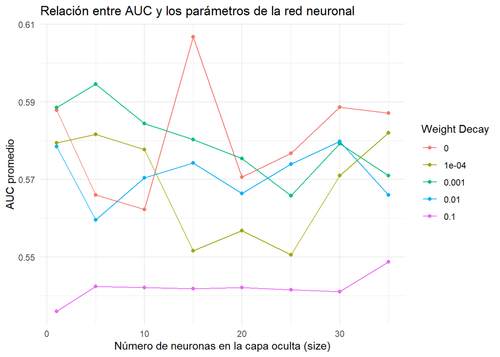

```r
# Generar gráficos ilustrativos
ggplot(results_summary, aes(x = size, y = AUC, color = as.factor(decay))) +
  geom_line() +
  geom_point() +
  labs(title = "Relación entre AUC y los parámetros de la red neuronal",
       x = "Número de neuronas en la capa oculta (size)",
       y = "AUC promedio",
       color = "Weight Decay") +
  theme_minimal()
```

```r
# Entrenar el modelo final con los mejores parámetros y variables en todo el conjunto de datos
final_formula <- as.formula(paste("ESTADO_ACTUAL_BIN ~", paste(best_variables, collapse = " + ")))
modelo_final_neuronas_chi <- nnet(final_formula, data=datos_cancer_def,
                     size=best_params$size, decay=best_params$decay,
                     maxit=max_iterations, trace=FALSE)

save(modelo_final_neuronas_chi, file = "modelo_final_neuronas.RData")

# Evaluar el modelo final
pred_final <- predict(modelo_final_neuronas_chi, newdata=datos_cancer_def, type="raw")
pred_final <- ifelse(pred_final > 0.5, 1, 0)
auc_final <- auc(as.numeric(datos_cancer_def$ESTADO_ACTUAL_BIN), pred_final)

print(paste("AUC del modelo final:", auc_final))
```

```
## [1] "AUC del modelo final: 0.944142614601019"
```

```r
# Crear la matriz de confusión
conf_matrix <- confusionMatrix(as.factor(pred_final), datos_cancer_def$ESTADO_ACTUAL_BIN)
print(conf_matrix)
```

```
## Confusion Matrix and Statistics
##
##           Reference
## Prediction   0   1
##          0 462   2
##          1   3  17
##
##                Accuracy : 0.9897
##                  95% CI : (0.9761, 0.9966)
##     No Information Rate : 0.9607
##     P-Value [Acc > NIR] : 0.0001241
##
##                   Kappa : 0.8664
##
##  Mcnemar's Test P-Value : 1.0000000
##
##             Sensitivity : 0.9935
##             Specificity : 0.8947
##          Pos Pred Value : 0.9957
##          Neg Pred Value : 0.8500
##              Prevalence : 0.9607
##          Detection Rate : 0.9545
##    Detection Prevalence : 0.9587
##       Balanced Accuracy : 0.9441
##
##        'Positive' Class : 0
##
```

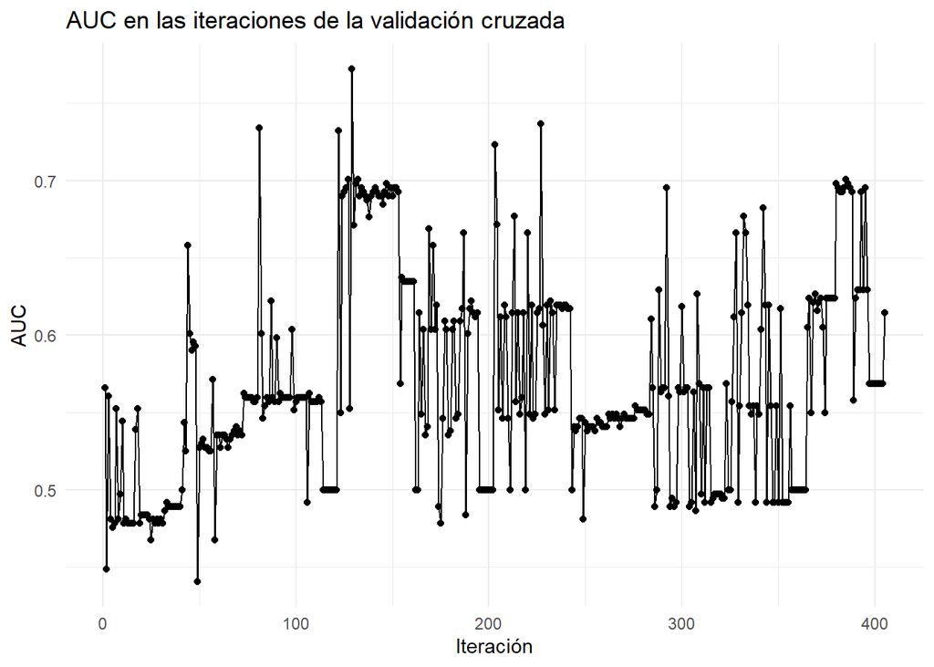

```r
# Generar gráfico del AUC
ggplot(results, aes(x = 1:nrow(results), y = AUC)) +
  geom_line() +
  geom_point() +
  labs(title = "AUC en las iteraciones de la validación cruzada",
       x = "Iteración",
       y = "AUC") +
  theme_minimal()
```

En el caso de que con el weight decay haya salido un valor de 0 como el mejor, es probabilidad, al final puede que los pesos al cambiar tanto den con un valor mejor para clasificar, pero no es seguro utilizar un weight decay 0 debido a su inestabilidad, ya que puede provocar errores de clasificación.

El mejor AUC obtenido es de 0.6 lo que nos puede sugerir que las redes neuronales no son un buen modelo para predecir este tipo de datos. Se podría deber a varios factores; las clases están súmamente desbalanceadas y los datos son insuficientes como para que pueda detectar patrones dentro de la red. Esto podría plantear la posibilidad de realizar un oversampling dentro de cada train_outer lo que ayudaría significativamente a obtener mejores resultados, pero dado que los datos serían artificiales no procederé con esa opción.

## 4.2 5x2 Redes neuronales Metodo Wrapper fuerza bruta

Probaremos con el método wrapper de tipo fuerza bruta, para ver cuales de ellas nos ofrece un mejor rendimiento de AUC.

La idea del método por fuerza bruta es probar todas las combinaciones de variables con todas las combinaciones de parámetros y ver el rendimiento del AUC para cada una.

```r
library(FSelector)
library(caret)
library(pROC)
library(nnet)
library(ggplot2)
library(dplyr)

# Convertir la variable objetivo a factor si no lo está
datos_cancer_def$ESTADO_ACTUAL_BIN <- as.factor(datos_cancer_def$ESTADO_ACTUAL_BIN)

# Definir el rango de búsqueda de los parámetros
sizes <- c(10, 15, 20, 25, 30)  # Número de neuronas en la capa oculta
weight_decays <- c(0, 0.0001, 0.001, 0.01, 0.1)  # Parámetro de regularización
max_iterations <- 100  # Número máximo de iteraciones

# Crear las combinaciones de los parámetros
parametros <- expand.grid(size = sizes, decay = weight_decays)

# Crear las cajas de test y entrenamiento para el outer-loop
set.seed(123)
folds_outer <- createFolds(datos_cancer_def$ESTADO_ACTUAL_BIN, k = 5)

# Inicializar la matriz para almacenar los resultados del outer-loop
results <- data.frame(size = integer(), decay = numeric(), AUC = numeric(), fold = integer(), variables = character())

# Función para calcular el AUC en la validación cruzada
calc_auc <- function(vars, train_data, val_data, params) {
  formula <- as.formula(paste("ESTADO_ACTUAL_BIN ~", paste(vars, collapse = " + ")))
  modelo <- nnet(formula, data=train_data, size=params$size, decay=params$decay, maxit=max_iterations, trace=FALSE)
  pred <- predict(modelo, newdata=val_data, type="raw")
  pred <- ifelse(pred > 0.5, 1, 0)
  return(auc(as.numeric(val_data$ESTADO_ACTUAL_BIN), pred))
}

# Realizar la validación cruzada 5x2
# Outer-loop
for(i in 1:5){
  # Obtener índices para entrenamiento y prueba en el outer-loop
  test_indices_outer <- folds_outer[[i]]
  train_data_outer <- datos_cancer_def[-test_indices_outer, ]
  test_data_outer <- datos_cancer_def[test_indices_outer, ]

  # Crear las cajas de validación y entrenamiento para el inner-loop
  folds_inner <- createFolds(train_data_outer$ESTADO_ACTUAL_BIN, k = 2)

  best_inner_result <- NULL

  # Selección de variables usando fuerza bruta (wrapper)
  all_vars <- colnames(train_data_outer)[-which(colnames(train_data_outer) == "ESTADO_ACTUAL_BIN")]
  subsets <- list()

  # Inner-loop
  for(j in 1:2){
    # Separar los datos en conjuntos de entrenamiento y validación
    val_indices_inner <- folds_inner[[j]]
    train_data_inner <- train_data_outer[-val_indices_inner, ]
    val_data_inner <- train_data_outer[val_indices_inner, ]



    # Crear todas las combinaciones posibles de variables (subconjuntos)
    for (n in 1:length(all_vars)) {
      subsets <- c(subsets, combn(all_vars, n, simplify = FALSE))
    }

    best_subset <- NULL
    best_auc <- 0

    # Evaluar cada subconjunto de variables
    for (subset in subsets) {
      for(k in 1:nrow(parametros)){
        auc_value <- calc_auc(subset, train_data_inner, val_data_inner, parametros[k, ])

        if (auc_value > best_auc) {
          best_auc <- auc_value
          best_subset <- subset
          best_params <- parametros[k, ]
        }
      }
    }

    # Almacenar el mejor resultado del inner-loop
    best_inner_result <- data.frame(size = best_params$size,
                                    decay = best_params$decay, AUC = best_auc,
                                    fold = i, variables = paste(best_subset, collapse = ", "))
  }

  # Entrenar el modelo en el outer-loop con los mejores parámetros y variables del inner-loop
  best_vars <- unlist(strsplit(best_inner_result$variables, ", "))
  final_formula <- as.formula(paste("ESTADO_ACTUAL_BIN ~", paste(best_vars, collapse = " + ")))

  modelo_final <- nnet(final_formula, data=train_data_outer,
                       size=best_inner_result$size, decay=best_inner_result$decay,
                       maxit=max_iterations, trace=FALSE)

  # Evaluar el modelo en los datos de prueba del outer-loop
  pred_outer <- predict(modelo_final, newdata=test_data_outer, type="raw")
  pred_outer <- ifelse(pred_outer > 0.5, 1, 0)
  auc_outer <- auc(as.numeric(test_data_outer$ESTADO_ACTUAL_BIN), pred_outer)

  # Almacenar el AUC del outer-loop
  results <- rbind(results, data.frame(size = best_inner_result$size,
                                       decay = best_inner_result$decay, AUC = auc_outer,
                                       fold = i, variables = best_inner_result$variables))
}

# Calcular el promedio del AUC para cada combinación de parámetros
results_summary <- aggregate(AUC ~ size + decay, data = results, FUN = mean)

# Mostrar la tabla de resumen
print(results_summary)

# Identificar la mejor combinación de parámetros
best_params <- results_summary[which.max(results_summary$AUC), ]
print(best_params)

# Obtener las mejores variables asociadas a los mejores parámetros
best_result <- results[which.max(results$AUC), ]
best_iteration <- best_result$fold
best_variables <- strsplit(best_result$variables, ", ")[[1]]

print(paste("Mejores variables:", paste(best_variables, collapse = ", ")))

# Generar gráficos ilustrativos
ggplot(results_summary, aes(x = size, y = AUC, color = as.factor(decay))) +
  geom_line() +
  geom_point() +
  labs(title = "Relación entre AUC y los parámetros de la red neuronal",
       x = "Número de neuronas en la capa oculta (size)",
       y = "AUC promedio",
       color = "Weight Decay") +
  theme_minimal()

# Entrenar el modelo final con los mejores parámetros y variables en todo el conjunto de datos
final_formula <- as.formula(paste("ESTADO_ACTUAL_BIN ~", paste(best_variables, collapse = " + ")))
modelo_final_neuronas <- nnet(final_formula, data=datos_cancer_def,
                     size=best_params$size, decay=best_params$decay,
                     maxit=max_iterations, trace=FALSE)



# Evaluar el modelo final
pred_final <- predict(modelo_final_neuronas, newdata=datos_cancer_def, type="raw")
pred_final <- ifelse(pred_final > 0.5, 1, 0)
auc_final <- auc(as.numeric(datos_cancer_def$ESTADO_ACTUAL_BIN), pred_final)

print(paste("AUC del modelo final:", auc_final))

# Crear la matriz de confusión
conf_matrix <- confusionMatrix(as.factor(pred_final), datos_cancer_def$ESTADO_ACTUAL_BIN)
print(conf_matrix)

# Generar gráfico del AUC
ggplot(results, aes(x = 1:nrow(results), y = AUC)) +
  geom_line() +
  geom_point() +
  labs(title = "AUC en las iteraciones de la validación cruzada",
       x = "Iteración",
       y = "AUC") +
  theme_minimal()
```

Tras dejar una noche el código ejecutándose, llegamos a las conclusiones de que el método wrapper por fuerza bruta es inviable para redes neuronales y muy posiblemente para el resto de modelos, ya que las combinaciones de parámetros y variables son exponenciales lo que exige un nivel de tiempo de ejecución y recursos computacionales muy altos, de los cuales no dispongo.

Por lo que optaremos por una alternativa con mucho menos gasto computacional y tiempo. Utilizaremos stepAIC backward para analizar la dependencia de las variables en cada train_outer de cada fold con respecto a ESTADO_ACTUAL_BIN.

## 4.3 5x2 Neuronas.Wrapper stepAIC

Realizaremos un filtrado de tipo stepAIC tipo backward para las variables, comenzando con un modelo completo que incluye todas las variables y las elimina una por una, seleccionando en cada paso la variable cuya eliminación reduce más el AIC.

```r
library(FSelector)
library(caret)
library(pROC)
library(nnet)
library(ggplot2)
library(dplyr)
library(MASS)

# Convertir la variable objetivo a factor si no lo está
datos_cancer_def$ESTADO_ACTUAL_BIN <- as.factor(datos_cancer_def$ESTADO_ACTUAL_BIN)

# Definir el rango de búsqueda de los parámetros
sizes <- c(1, 5, 10, 15, 20, 25, 30, 35)  # Número de neuronas en la capa oculta
weight_decays <- c(0, 0.0001, 0.001, 0.01, 0.1)  # Parámetro de regularización
max_iterations <- 100  # Número máximo de iteraciones

# Crear las combinaciones de los parámetros
parametros <- expand.grid(size = sizes, decay = weight_decays)

# Crear las cajas de test y entrenamiento para el outer-loop
set.seed(123)
folds_outer <- createFolds(datos_cancer_def$ESTADO_ACTUAL_BIN, k = 5)

# Inicializar la matriz para almacenar los resultados del outer-loop
results <- data.frame(size = integer(), decay = numeric(), AUC = numeric(), fold = integer(), variables = character())

# Realizar la validación cruzada 5x2
# Outer-loop
for(i in 1:5){
  # Obtener índices para entrenamiento y prueba en el outer-loop
  test_indices_outer <- folds_outer[[i]]
  train_data_outer <- datos_cancer_def[-test_indices_outer, ]
  test_data_outer <- datos_cancer_def[test_indices_outer, ]

  # Crear las cajas de validación y entrenamiento para el inner-loop
  folds_inner <- createFolds(train_data_outer$ESTADO_ACTUAL_BIN, k = 2)

  best_inner_result <- NULL

  # Selección de variables usando stepAIC (backward)
  full_model <- glm(ESTADO_ACTUAL_BIN ~ ., data = train_data_outer, family = binomial)
  step_model <- stepAIC(full_model, direction = "backward", trace = FALSE)

  print(names(step_model$model)[-1])
  top_vars <- names(step_model$model)[-1]  # Seleccionar las mejores variables

  # Inner-loop
  for(j in 1:2){
    # Separar los datos en conjuntos de entrenamiento y validación
    val_indices_inner <- folds_inner[[j]]
    train_data_inner <- train_data_outer[-val_indices_inner, ]
    val_data_inner <- train_data_outer[val_indices_inner, ]

    # Crear fórmula con las variables seleccionadas
    formula <- as.formula(paste("ESTADO_ACTUAL_BIN ~", paste(top_vars, collapse = " + ")))

    # Ajustar el modelo para cada combinación de parámetros
    for(k in 1:nrow(parametros)){
      # Entrenar el modelo con la combinación de parámetros
      modelo <- nnet(formula, data=train_data_inner, size=parametros$size[k],
                     decay=parametros$decay[k], maxit=max_iterations, trace=FALSE)

      # Predecir en los datos de validación
      pred <- predict(modelo, newdata=val_data_inner, type="raw")
      pred <- ifelse(pred > 0.5, 1, 0)  # Convertir probabilidades a clases

      # Calcular el AUC
      auc_value <- auc(as.numeric(val_data_inner$ESTADO_ACTUAL_BIN), pred)

      # Almacenar los resultados
      results <- rbind(results, data.frame(size = parametros$size[k],
                                           decay = parametros$decay[k], AUC = auc_value,
                                           fold = i, variables = paste(top_vars, collapse = ", ")))

      # Guardar el mejor resultado del inner-loop
      if (is.null(best_inner_result) || auc_value > best_inner_result$AUC) {
        best_inner_result <- data.frame(size = parametros$size[k],
                                        decay = parametros$decay[k], AUC = auc_value,
                                        fold = i, variables = paste(top_vars, collapse = ", "))
      }
    }
  }

  # Entrenar el modelo en el outer-loop con los mejores parámetros del inner-loop
  best_vars <- unlist(strsplit(best_inner_result$variables, ", "))
  final_formula <- as.formula(paste("ESTADO_ACTUAL_BIN ~", paste(best_vars, collapse = " + ")))

  modelo_final <- nnet(final_formula, data=train_data_outer,
                       size=best_inner_result$size, decay=best_inner_result$decay,
                       maxit=max_iterations, trace=FALSE)

  # Evaluar el modelo en los datos de prueba del outer-loop
  pred_outer <- predict(modelo_final, newdata=test_data_outer, type="raw")
  pred_outer <- ifelse(pred_outer > 0.5, 1, 0)
  auc_outer <- auc(as.numeric(test_data_outer$ESTADO_ACTUAL_BIN), pred_outer)

  # Almacenar el AUC del outer-loop
  results <- rbind(results, data.frame(size = best_inner_result$size,
                                       decay = best_inner_result$decay, AUC = auc_outer,
                                       fold = i, variables = best_inner_result$variables))
}
```

```
## [1] "RP"           "GANGLIOS"     "EDAD_DCO_CAT" "YEAR_DIAG"    "ESTADIO_CAT"
## [1] "CIRUGIA"      "TAM"          "GRADO"        "FENOTIPO"     "GANGLIOS"
## [6] "EDAD_DCO_CAT" "YEAR_DIAG"    "ESTADIO_CAT"
## [1] "RP"           "GANGLIOS"     "EDAD_DCO_CAT" "YEAR_DIAG"    "ESTADIO_CAT"
## [1] "MENOP"       "FENOTIPO"    "YEAR_DIAG"   "ESTADIO_CAT"
## [1] "TAM"          "KI67"         "FENOTIPO"     "GANGLIOS"     "EDAD_DCO_CAT"
## [6] "YEAR_DIAG"    "ESTADIO_CAT"
```

```r
# Calcular el promedio del AUC para cada combinación de parámetros
results_summary <- aggregate(AUC ~ size + decay, data = results, FUN = mean)

# Mostrar la tabla de resumen
print(results_summary)
```

```
##    size decay       AUC
## 1     1 0e+00 0.5666379
## 2     5 0e+00 0.5485983
## 3    10 0e+00 0.5428859
## 4    15 0e+00 0.5448637
## 5    20 0e+00 0.5607431
## 6    25 0e+00 0.5677131
## 7    30 0e+00 0.5626248
## 8    35 0e+00 0.5508449
## 9     1 1e-04 0.5647954
## 10    5 1e-04 0.5587942
## 11   10 1e-04 0.5646889
## 12   15 1e-04 0.5465630
## 13   20 1e-04 0.5408637
## 14   25 1e-04 0.5468318
```

[output cut: 26 more lines]

```r
# Identificar la mejor combinación de parámetros
best_params <- results_summary[which.max(results_summary$AUC), ]
print(best_params)
```

```
##   size decay       AUC
## 6   25     0 0.5677131
```

```r
# Obtener las mejores variables asociadas a los mejores parámetros
best_result <- results[which.max(results$AUC), ]
best_iteration <- best_result$fold
best_variables <- strsplit(best_result$variables, ", ")[[1]]

print(paste("Mejores variables:", paste(best_variables, collapse = ", ")))
```

```
## [1] "Mejores variables: TAM, KI67, FENOTIPO, GANGLIOS, EDAD_DCO_CAT, YEAR_DIAG, ESTADIO_CAT"
```

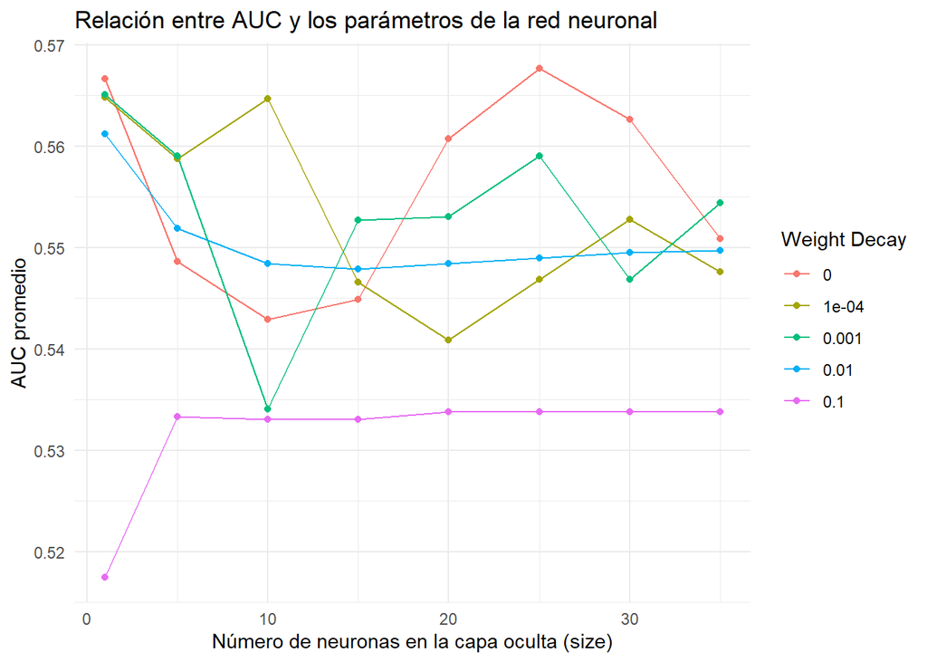

```r
# Generar gráficos ilustrativos
ggplot(results_summary, aes(x = size, y = AUC, color = as.factor(decay))) +
  geom_line() +
  geom_point() +
  labs(title = "Relación entre AUC y los parámetros de la red neuronal",
       x = "Número de neuronas en la capa oculta (size)",
       y = "AUC promedio",
       color = "Weight Decay") +
  theme_minimal()
```

```r
# Entrenar el modelo final con los mejores parámetros y variables en todo el conjunto de datos
final_formula <- as.formula(paste("ESTADO_ACTUAL_BIN ~", paste(best_variables, collapse = " + ")))
modelo_final_neuronas_chi <- nnet(final_formula, data=datos_cancer_def,
                     size=best_params$size, decay=best_params$decay,
                     maxit=max_iterations, trace=FALSE)

save(modelo_final_neuronas_chi, file = "modelo_final_neuronas.RData")

# Evaluar el modelo final
pred_final <- predict(modelo_final_neuronas_chi, newdata=datos_cancer_def, type="raw")
pred_final <- ifelse(pred_final > 0.5, 1, 0)
auc_final <- auc(as.numeric(datos_cancer_def$ESTADO_ACTUAL_BIN), pred_final)

print(paste("AUC del modelo final:", auc_final))
```

```
## [1] "AUC del modelo final: 0.972608941709111"
```

```r
# Crear la matriz de confusión
conf_matrix <- confusionMatrix(as.factor(pred_final), datos_cancer_def$ESTADO_ACTUAL_BIN)
print(conf_matrix)
```

```
## Confusion Matrix and Statistics
##
##           Reference
## Prediction   0   1
##          0 464   1
##          1   1  18
##
##                Accuracy : 0.9959
##                  95% CI : (0.9852, 0.9995)
##     No Information Rate : 0.9607
##     P-Value [Acc > NIR] : 8.249e-07
##
##                   Kappa : 0.9452
##
##  Mcnemar's Test P-Value : 1
##
##             Sensitivity : 0.9978
##             Specificity : 0.9474
##          Pos Pred Value : 0.9978
##          Neg Pred Value : 0.9474
##              Prevalence : 0.9607
##          Detection Rate : 0.9587
##    Detection Prevalence : 0.9607
##       Balanced Accuracy : 0.9726
##
##        'Positive' Class : 0
##
```

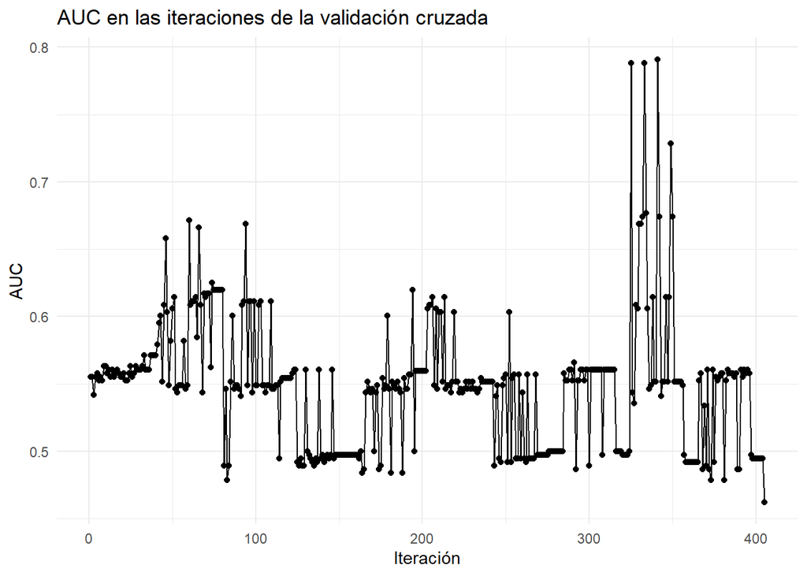

```r
# Generar gráfico del AUC
ggplot(results, aes(x = 1:nrow(results), y = AUC)) +
  geom_line() +
  geom_point() +
  labs(title = "AUC en las iteraciones de la validación cruzada",
       x = "Iteración",
       y = "AUC") +
  theme_minimal()
```

En cuanto al rendimiento del modelo final. Es bueno, pero no es consistente con el mejor modelo que hemos encontrado. En este tipo de pruebas hay que esperar que los resultados entre el modelo final y el mejor sean parecidos, ya que si el modelo final es muy superior al mejor, con suma probabilidad, se ha producido overfitting, habiéndose aprendido el dataset de entrenamiento.

## 4.4 5x2 SVM. Filtrado chi_squared

Realizaremos el mismo procedimiento de filter chi_cuadrado con el modelo SVM

El objetivo del modelo SVM es crear un hiperplano que mejor separe las clases de ESTADO_ACTUAL_BIN, que maxime el margen entre las dos clases.

Dentro de este modelo encontramos los siguientes **parámetros**:

- C_value: es el que controla el equilibrio entre el margen y clasificar correctamente los puntos. Esto quiere decir que cuanto mayor sea el valor de C, habrá menor margen entre clases y se clasificará correctamente (esto puede derivar a overfitting), en el caso de que sea menor habrá mayor margen entre las clases lo que provoca que haya un error en la diferenciación entre clases.
- Gamma: mide el nivel de alcance de influencia de los puntos en el espacio. Si tiene un valor bajo se consideran los puntos más lejanos, lo que puede dar lugar a underfitting, en caso de que sea alto sucederá lo contrario.

```r
library(e1071)
library(caret)
library(pROC)
library(ggplot2)
library(dplyr)
library(FSelector)

# Definir el rango de búsqueda de los parámetros
C_values <- c(1, 10, 50, 100, 150,200)
gamma_values <- c(0.001, 0.01, 0.1, 1)

# Crear las combinaciones de los parámetros
parametros <- expand.grid(C = C_values, gamma = gamma_values)

# Crear las cajas de test y entrenamiento para el outer-loop
set.seed(123)
folds_outer <- createFolds(datos_cancer_def$ESTADO_ACTUAL_BIN, k = 5)

# Inicializar la matriz para almacenar los resultados del outer-loop
results <- data.frame(C = numeric(), gamma = numeric(), AUC = numeric(), fold = integer(), variables = character())

# Realizar la validación cruzada 5x2
# Outer-loop
for(i in 1:5){
  # Obtener índices para entrenamiento y prueba en el outer-loop
  test_indices_outer <- folds_outer[[i]]
  train_data_outer <- datos_cancer_def[-test_indices_outer, ]
  test_data_outer <- datos_cancer_def[test_indices_outer, ]

  # Crear las cajas de validación y entrenamiento para el inner-loop
  folds_inner <- createFolds(train_data_outer$ESTADO_ACTUAL_BIN, k = 2)

  best_inner_result <- NULL
  # Selección de variables usando el método de chi-cuadrado
  weights <- chi.squared(ESTADO_ACTUAL_BIN ~ ., data = train_data_outer)
  top_vars <- cutoff.k(weights, 5)  # Seleccionar las 5 mejores variables

  # Inner-loop
  for(j in 1:2){
    # Separar los datos en conjuntos de entrenamiento y validación
    val_indices_inner <- folds_inner[[j]]
    train_data_inner <- train_data_outer[-val_indices_inner, ]
    val_data_inner <- train_data_outer[val_indices_inner, ]



    # Crear fórmula con las variables seleccionadas
    formula <- as.formula(paste("ESTADO_ACTUAL_BIN ~", paste(top_vars, collapse = " + ")))

    # Ajustar el modelo para cada combinación de parámetros
    for(k in 1:nrow(parametros)){
      # Entrenar el modelo SVM con la combinación de parámetros
      modelo <- svm(formula, data = train_data_inner, kernel = "radial",
                    cost = parametros$C[k], gamma = parametros$gamma[k], probability = TRUE)

      # Predecir en los datos de validación
      pred <- predict(modelo, newdata = val_data_inner, probability = TRUE)
      prob <- attr(pred, "probabilities")[,2]

      # Calcular el AUC
      auc_value <- auc(as.numeric(val_data_inner$ESTADO_ACTUAL_BIN), prob)

      # Almacenar los resultados
      results <- rbind(results, data.frame(C = parametros$C[k], gamma = parametros$gamma[k],
                                           AUC = auc_value, fold = i, variables = paste(top_vars, collapse = ", ")))

      # Guardar el mejor resultado del inner-loop
      if (is.null(best_inner_result) || auc_value > best_inner_result$AUC) {
        best_inner_result <- data.frame(C = parametros$C[k],
                                        gamma = parametros$gamma[k], AUC = auc_value,
                                        fold = i, variables = paste(top_vars, collapse = ", "))
      }
    }
  }

  # Entrenar el modelo en el outer-loop con los mejores parámetros y variables del inner-loop
  best_vars <- unlist(strsplit(best_inner_result$variables, ", "))
  final_formula <- as.formula(paste("ESTADO_ACTUAL_BIN ~", paste(best_vars, collapse = " + ")))

  modelo_final <- svm(final_formula, data=train_data_outer,
                      kernel = "radial", cost=best_inner_result$C, gamma=best_inner_result$gamma,
                      probability=TRUE)

  # Evaluar el modelo en los datos de prueba del outer-loop
  pred_outer <- predict(modelo_final, newdata=test_data_outer, probability=TRUE)
  prob_outer <- attr(pred_outer, "probabilities")[,2]
  auc_outer <- auc(as.numeric(test_data_outer$ESTADO_ACTUAL_BIN), prob_outer)

  # Almacenar el AUC del outer-loop
  results <- rbind(results, data.frame(C = best_inner_result$C,
                                       gamma = best_inner_result$gamma, AUC = auc_outer,
                                       fold = i, variables = best_inner_result$variables))
}

# Calcular el promedio del AUC para cada combinación de parámetros
results_summary <- aggregate(AUC ~ C + gamma, data = results, FUN = mean)

# Mostrar la tabla de resumen
print(results_summary)
```

```
##      C gamma       AUC
## 1    1 0.001 0.7311540
## 2   10 0.001 0.7473598
## 3   50 0.001 0.7553589
## 4  100 0.001 0.7493472
## 5  150 0.001 0.7492416
## 6  200 0.001 0.7495008
## 7    1 0.010 0.7498848
## 8   10 0.010 0.7519777
## 9   50 0.010 0.7532162
## 10 100 0.010 0.7503744
## 11 150 0.010 0.7552035
## 12 200 0.010 0.7578053
## 13   1 0.100 0.7454493
## 14  10 0.100 0.7429243
## 15  50 0.100 0.7036866
## 16 100 0.100 0.7022561
## 17 150 0.100 0.7022561
## 18 200 0.100 0.7022561
## 19   1 1.000 0.7482965
## 20  10 1.000 0.7516845
## 21  50 1.000 0.7542723
## 22 100 1.000 0.7542723
## 23 150 1.000 0.7542723
## 24 200 1.000 0.7542723
```

```r
# Identificar la mejor combinación de parámetros
best_params <- results_summary[which.max(results_summary$AUC), ]
print(best_params)
```

```
##      C gamma       AUC
## 12 200  0.01 0.7578053
```

```r
# Obtener las mejores variables asociadas a los mejores parámetros
best_result <- results[which.max(results$AUC), ]
best_iteration <- best_result$fold
best_variables <- strsplit(best_result$variables, ", ")[[1]]

print(paste("Mejores variables:", paste(best_variables, collapse = ", ")))
```

```
## [1] "Mejores variables: YEAR_DIAG, EDAD_DCO_CAT, ESTADIO_CAT, FENOTIPO, GANGLIOS"
```

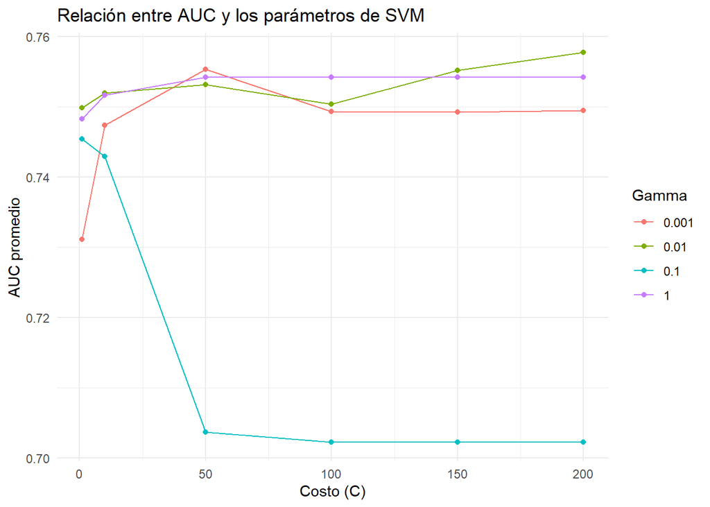

```r
# Generar gráficos ilustrativos
ggplot(results_summary, aes(x = C, y = AUC, color = as.factor(gamma))) +
  geom_line() +
  geom_point() +
  labs(title = "Relación entre AUC y los parámetros de SVM",
       x = "Costo (C)",
       y = "AUC promedio",
       color = "Gamma") +
  theme_minimal()
```

```r
# Entrenar el modelo final con los mejores parámetros y variables en todo el conjunto de datos
final_formula <- as.formula(paste("ESTADO_ACTUAL_BIN ~", paste(best_variables, collapse = " + ")))
modelo_final <- svm(final_formula, data=datos_cancer_def,
                    kernel="radial", cost=best_params$C, gamma=best_params$gamma,
                    probability=TRUE)

# Evaluar el modelo final
pred_final <- predict(modelo_final, newdata=datos_cancer_def, probability=TRUE)
prob_final <- attr(pred_final, "probabilities")[,2]
auc_final <- auc(as.numeric(datos_cancer_def$ESTADO_ACTUAL_BIN), prob_final)

print(paste("AUC del modelo final:", auc_final))
```

```
## [1] "AUC del modelo final: 0.969779286926995"
```

Como vemos en las gráficas al considerar valores altos de C (como 100 y 200), al haber un coste grande reducimos los margenes entre clases pudiendo clasificar excesivamente los puntos y al juntarse con un gamma tan alto hace que se consideren solo los puntos cercanos y los casos aislados se descarten, debería salir un AUC más bajo, debido a que estamos clasificando grupos de puntos demasiado específicos, pero como observamos en la gráfica la combinación del gamma más elevados con el coste más elevado dan un resultado sorprendentemente bueno a pesar de que la clasficación que hace es demasiado retrictiva a los grupos, puede ser que tenga estos resultados debido a que los puntos no tienen valores muy distintos los unos de los otros pudiendo diferenciar clases con facilidad. En estos casos, es mejor utilizar parámetros que promuevan la generalización para obtener mejores resultados, ya que con otros podemos provocar overfitting en grupos de puntos sin contar otro tipos de datos más aislados, que brindan variedad de datos.

El rendimiento en cuanto a AUC mejora significativamente, cuando tenemos en cuenta puntos que no están cercanos lo que reduce bastante las posibilidades de overfitting. Esto podría justificar porqué la mejor combinación de parámetros es el costo más elevado (200) con un gamma pequeño (0.01). Un costo grande puede provocar overfitting pero se contrarresta con un gamma pequeño.

El rendimiendo del modelo es lo suficientemente bueno como para considerar desplegarlo en la aplicación, aunque no es muy coherente con los resultados del modelo final.

## 4.5 5x2 SVM.Wrapper StepAIC

```r
library(e1071)
library(caret)
library(pROC)
library(ggplot2)
library(dplyr)
library(MASS)

# Definir el rango de búsqueda de los parámetros
C_values <- c(1, 10, 50, 100, 150,200)
gamma_values <- c(0.001, 0.01, 0.1, 1)

# Crear las combinaciones de los parámetros
parametros <- expand.grid(C = C_values, gamma = gamma_values)

# Crear las cajas de test y entrenamiento para el outer-loop
set.seed(123)
folds_outer <- createFolds(datos_cancer_def$ESTADO_ACTUAL_BIN, k = 5)

# Inicializar la matriz para almacenar los resultados del outer-loop
results <- data.frame(C = numeric(), gamma = numeric(), AUC = numeric(), fold = integer(), variables = character())

# Realizar la validación cruzada 5x2
# Outer-loop
for(i in 1:5){
  # Obtener índices para entrenamiento y prueba en el outer-loop
  test_indices_outer <- folds_outer[[i]]
  train_data_outer <- datos_cancer_def[-test_indices_outer, ]
  test_data_outer <- datos_cancer_def[test_indices_outer, ]

  # Selección de variables usando stepAIC (backward)
  full_model <- glm(ESTADO_ACTUAL_BIN ~ ., data = train_data_outer, family = binomial)
  step_model <- stepAIC(full_model, direction = "backward", trace = FALSE)
  top_vars <- names(step_model$model)[-1]  # Seleccionar las mejores variables

  # Crear las cajas de validación y entrenamiento para el inner-loop
  folds_inner <- createFolds(train_data_outer$ESTADO_ACTUAL_BIN, k = 2)

  best_inner_result <- NULL

  # Inner-loop
  for(j in 1:2){
    # Separar los datos en conjuntos de entrenamiento y validación
    val_indices_inner <- folds_inner[[j]]
    train_data_inner <- train_data_outer[-val_indices_inner, ]
    val_data_inner <- train_data_outer[val_indices_inner, ]

    # Crear fórmula con las variables seleccionadas
    formula <- as.formula(paste("ESTADO_ACTUAL_BIN ~", paste(top_vars, collapse = " + ")))

    # Ajustar el modelo para cada combinación de parámetros
    for(k in 1:nrow(parametros)){
      # Entrenar el modelo SVM con la combinación de parámetros
      modelo <- svm(formula, data = train_data_inner, kernel = "radial",
                    cost = parametros$C[k], gamma = parametros$gamma[k], probability = TRUE)

      # Predecir en los datos de validación
      pred <- predict(modelo, newdata = val_data_inner, probability = TRUE)
      prob <- attr(pred, "probabilities")[,2]

      # Calcular el AUC
      auc_value <- auc(as.numeric(val_data_inner$ESTADO_ACTUAL_BIN), prob)

      # Almacenar los resultados
      results <- rbind(results, data.frame(C = parametros$C[k], gamma = parametros$gamma[k],
                                           AUC = auc_value, fold = i, variables = paste(top_vars, collapse = ", ")))

      # Guardar el mejor resultado del inner-loop
      if (is.null(best_inner_result) || auc_value > best_inner_result$AUC) {
        best_inner_result <- data.frame(C = parametros$C[k],
                                        gamma = parametros$gamma[k], AUC = auc_value,
                                        fold = i, variables = paste(top_vars, collapse = ", "))
      }
    }
  }

  # Entrenar el modelo en el outer-loop con los mejores parámetros y variables del inner-loop
  best_vars <- unlist(strsplit(best_inner_result$variables, ", "))
  final_formula <- as.formula(paste("ESTADO_ACTUAL_BIN ~", paste(best_vars, collapse = " + ")))

  modelo_final <- svm(final_formula, data=train_data_outer,
                      kernel = "radial", cost=best_inner_result$C, gamma=best_inner_result$gamma,
                      probability=TRUE)

  # Evaluar el modelo en los datos de prueba del outer-loop
  pred_outer <- predict(modelo_final, newdata=test_data_outer, probability=TRUE)
  prob_outer <- attr(pred_outer, "probabilities")[,2]
  auc_outer <- auc(as.numeric(test_data_outer$ESTADO_ACTUAL_BIN), prob_outer)

  # Almacenar el AUC del outer-loop
  results <- rbind(results, data.frame(C = best_inner_result$C,
                                       gamma = best_inner_result$gamma, AUC = auc_outer,
                                       fold = i, variables = best_inner_result$variables))
}

# Calcular el promedio del AUC para cada combinación de parámetros
results_summary <- aggregate(AUC ~ C + gamma, data = results, FUN = mean)

# Mostrar la tabla de resumen
print(results_summary)
```

```
##      C gamma       AUC
## 1    1 0.001 0.7197437
## 2   10 0.001 0.7635325
## 3   50 0.001 0.7658774
## 4  100 0.001 0.7366599
## 5  150 0.001 0.7368520
## 6  200 0.001 0.7373800
## 7    1 0.010 0.7471342
## 8   10 0.010 0.7257728
## 9   50 0.010 0.7289507
## 10 100 0.010 0.7326373
## 11 150 0.010 0.7301219
## 12 200 0.010 0.7487301
## 13   1 0.100 0.7039795
## 14  10 0.100 0.7226719
## 15  50 0.100 0.7169870
## 16 100 0.100 0.7248128
## 17 150 0.100 0.7251200
## 18 200 0.100 0.7251200
## 19   1 1.000 0.6668892
## 20  10 1.000 0.6893193
## 21  50 1.000 0.6893193
## 22 100 1.000 0.6893193
## 23 150 1.000 0.6893193
## 24 200 1.000 0.6893193
```

```r
# Identificar la mejor combinación de parámetros
best_params <- results_summary[which.max(results_summary$AUC), ]
print(best_params)
```

```
##    C gamma       AUC
## 3 50 0.001 0.7658774
```

```r
# Obtener las mejores variables asociadas a los mejores parámetros
best_result <- results[which.max(results$AUC), ]
best_iteration <- best_result$fold
best_variables <- strsplit(best_result$variables, ", ")[[1]]

print(paste("Mejores variables:", paste(best_variables, collapse = ", ")))
```

```
## [1] "Mejores variables: RP, GANGLIOS, EDAD_DCO_CAT, YEAR_DIAG, ESTADIO_CAT"
```

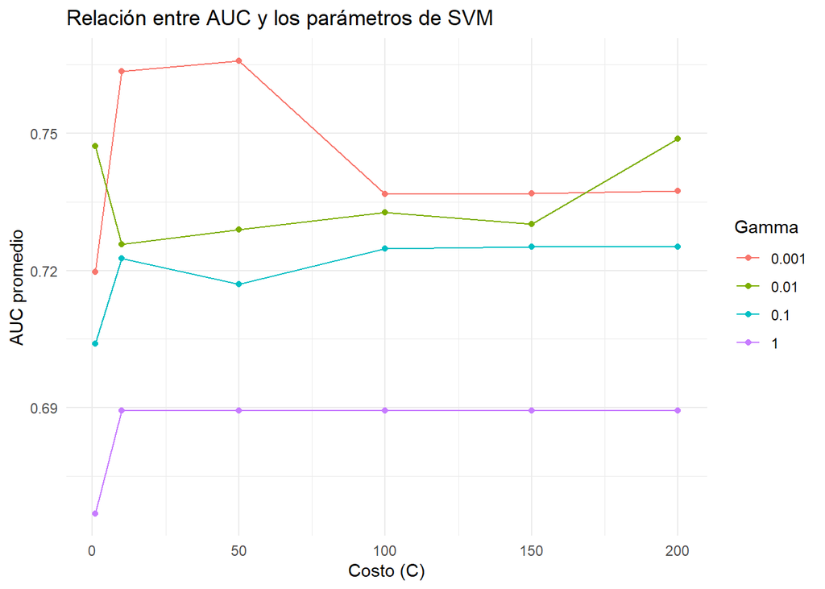

```r
# Generar gráficos ilustrativos
ggplot(results_summary, aes(x = C, y = AUC, color = as.factor(gamma))) +
  geom_line() +
  geom_point() +
  labs(title = "Relación entre AUC y los parámetros de SVM",
       x = "Costo (C)",
       y = "AUC promedio",
       color = "Gamma") +
  theme_minimal()
```

```r
# Entrenar el modelo final con los mejores parámetros y variables en todo el conjunto de datos
final_formula <- as.formula(paste("ESTADO_ACTUAL_BIN ~", paste(best_variables, collapse = " + ")))
modelo_final <- svm(final_formula, data=datos_cancer_def,
                    kernel="radial", cost=best_params$C, gamma=best_params$gamma,
                    probability=TRUE)

# Evaluar el modelo final
pred_final <- predict(modelo_final, newdata=datos_cancer_def, probability=TRUE)
prob_final <- attr(pred_final, "probabilities")[,2]
auc_final <- auc(as.numeric(datos_cancer_def$ESTADO_ACTUAL_BIN), prob_final)

print(paste("AUC del modelo final:", auc_final))
```

```
## [1] "AUC del modelo final: 0.949292586304471"
```

Podemos ver que los resultados se mantienen parecidos a los de filter chi_cuadrado, aunque podemos destacar varias observaciones. El valor para gamma=1 provoca que para la selección de variables de wrapper se obtenga un rendimiento notablemente inferior que con chi_squared. Podría deberse a que en este caso las variables presentan más variabilidad en sus valores.

5x2 SVM. Wrapper fuerza bruta

```r
library(e1071)
library(caret)
library(pROC)
library(ggplot2)
library(dplyr)

# Definir el rango de búsqueda de los parámetros
C_values <- c(1, 10, 100, 200)
gamma_values <- c(0.001, 0.01, 0.1, 1)

# Crear las combinaciones de los parámetros
parametros <- expand.grid(C = C_values, gamma = gamma_values)

# Crear las cajas de test y entrenamiento para el outer-loop
set.seed(123)
folds_outer <- createFolds(datos_cancer_def$ESTADO_ACTUAL_BIN, k = 5)

# Inicializar la matriz para almacenar los resultados del outer-loop
results <- data.frame(C = numeric(), gamma = numeric(), AUC = numeric(), fold = integer(), variables = character())

# Función para calcular el AUC en la validación cruzada
calc_auc <- function(vars, train_data, val_data, params) {
  formula <- as.formula(paste("ESTADO_ACTUAL_BIN ~", paste(vars, collapse = " + ")))
  modelo <- svm(formula, data=train_data, kernel="radial", cost=params$C, gamma=params$gamma, probability=TRUE)
  pred <- predict(modelo, newdata=val_data, probability=TRUE)
  prob <- attr(pred, "probabilities")[,2]
  return(auc(as.numeric(val_data$ESTADO_ACTUAL_BIN), prob))
}

# Realizar la validación cruzada 5x2
# Outer-loop
for(i in 1:5){
  # Obtener índices para entrenamiento y prueba en el outer-loop
  test_indices_outer <- folds_outer[[i]]
  train_data_outer <- datos_cancer_def[-test_indices_outer, ]
  test_data_outer <- datos_cancer_def[test_indices_outer, ]

  # Crear las cajas de validación y entrenamiento para el inner-loop
  folds_inner <- createFolds(train_data_outer$ESTADO_ACTUAL_BIN, k = 2)

  best_inner_result <- NULL
  # Selección de variables usando fuerza bruta (wrapper)
  all_vars <- colnames(train_data_inner)[-which(colnames(train_data_inner) == "ESTADO_ACTUAL_BIN")]
  subsets <- list()

  # Inner-loop
  for(j in 1:2){
    # Separar los datos en conjuntos de entrenamiento y validación
    val_indices_inner <- folds_inner[[j]]
    train_data_inner <- train_data_outer[-val_indices_inner, ]
    val_data_inner <- train_data_outer[val_indices_inner, ]



    # Crear todas las combinaciones posibles de variables (subconjuntos)
    for (n in 1:length(all_vars)) {
      subsets <- c(subsets, combn(all_vars, n, simplify = FALSE))
    }

    best_subset <- NULL
    best_auc <- 0

    # Evaluar cada subconjunto de variables
    for (subset in subsets) {
      for(k in 1:nrow(parametros)){
        auc_value <- calc_auc(subset, train_data_inner, val_data_inner, parametros[k, ])

        if (auc_value > best_auc) {
          best_auc <- auc_value
          best_subset <- subset
          best_params <- parametros[k, ]
        }
      }
    }

    # Almacenar el mejor resultado del inner-loop
    best_inner_result <- data.frame(C = best_params$C,
                                    gamma = best_params$gamma, AUC = best_auc,
                                    fold = i, variables = paste(best_subset, collapse = ", "))
  }

  # Entrenar el modelo en el outer-loop con los mejores parámetros y variables del inner-loop
  best_vars <- unlist(strsplit(best_inner_result$variables, ", "))
  final_formula <- as.formula(paste("ESTADO_ACTUAL_BIN ~", paste(best_vars, collapse = " + ")))

  modelo_final <- svm(final_formula, data=train_data_outer,
                      kernel = "radial", cost=best_inner_result$C, gamma=best_inner_result$gamma,
                      probability=TRUE)

  # Evaluar el modelo en los datos de prueba del outer-loop
  pred_outer <- predict(modelo_final, newdata=test_data_outer, probability=TRUE)
  prob_outer <- attr(pred_outer, "probabilities")[,2]
  auc_outer <- auc(as.numeric(test_data_outer$ESTADO_ACTUAL_BIN), prob_outer)

  # Almacenar el AUC del outer-loop
  results <- rbind(results, data.frame(C = best_inner_result$C,
                                       gamma = best_inner_result$gamma, AUC = auc_outer,
                                       fold = i, variables = best_inner_result$variables))
}

# Calcular el promedio del AUC para cada combinación de parámetros
results_summary <- aggregate(AUC ~ C + gamma, data = results, FUN = mean)

# Mostrar la tabla de resumen
print(results_summary)

# Identificar la mejor combinación de parámetros
best_params <- results_summary[which.max(results_summary$AUC), ]
print(best_params)

# Obtener las mejores variables asociadas a los mejores parámetros
best_result <- results[which.max(results$AUC), ]
best_iteration <- best_result$fold
best_variables <- strsplit(best_result$variables, ", ")[[1]]

print(paste("Mejores variables:", paste(best_variables, collapse = ", ")))

# Generar gráficos ilustrativos
ggplot(results_summary, aes(x = C, y = AUC, color = as.factor(gamma))) +
  geom_line() +
  geom_point() +
  labs(title = "Relación entre AUC y los parámetros de SVM",
       x = "Costo (C)",
       y = "AUC promedio",
       color = "Gamma") +
  theme_minimal()

# Entrenar el modelo final con los mejores parámetros y variables en todo el conjunto de datos
final_formula <- as.formula(paste("ESTADO_ACTUAL_BIN ~", paste(best_variables, collapse = " + ")))
modelo_final_svm_fb <- svm(final_formula, data=datos_cancer_def,
                    kernel="radial", cost=best_params$C, gamma=best_params$gamma,
                    probability=TRUE)
save(modelo_final_svm_fb, file = "modelo_final_svm_fb.RData")
# Evaluar el modelo final
pred_final <- predict(modelo_final_svm_fb, newdata=datos_cancer_def, probability=TRUE)
prob_final <- attr(pred_final, "probabilities")[,2]
auc_final <- auc(as.numeric(datos_cancer_def$ESTADO_ACTUAL_BIN), prob_final)

print(paste("AUC del modelo final:", auc_final))
```

## 4.6 5x2 SVM. Embedded Lasso

La filtrado por embedding es más difícil de implementar, ya que habría que trabajar con variables one hot, así que dado que me da mucho problemas no podré implementarlo.

```r
library(e1071)
library(caret)
library(pROC)
library(ggplot2)
library(dplyr)
library(glmnet)

# Convertir la variable objetivo a factor si no lo está
datos_cancer_def$ESTADO_ACTUAL_BIN <- as.factor(datos_cancer_def$ESTADO_ACTUAL_BIN)

# Definir el rango de búsqueda de los parámetros
C_values <- c(1, 10, 100, 200)
gamma_values <- c(0.001, 0.01, 0.1, 1)

# Crear las combinaciones de los parámetros
parametros <- expand.grid(C = C_values, gamma = gamma_values)

# Crear las cajas de test y entrenamiento para el outer-loop
set.seed(123)
folds_outer <- createFolds(datos_cancer_def$ESTADO_ACTUAL_BIN, k = 5)

# Inicializar la matriz para almacenar los resultados del outer-loop
results <- data.frame(C = numeric(), gamma = numeric(), AUC = numeric(), fold = integer(), variables = character())

# Realizar la validación cruzada 5x2
# Outer-loop
for(i in 1:5){
  # Obtener índices para entrenamiento y prueba en el outer-loop
  test_indices_outer <- folds_outer[[i]]
  train_data_outer <- datos_cancer_def[-test_indices_outer, ]
  test_data_outer <- datos_cancer_def[test_indices_outer, ]

  # Selección de variables usando Lasso (L1)
  x_train <- model.matrix(ESTADO_ACTUAL_BIN ~ ., train_data_outer)[,-1]
  y_train <- train_data_outer$ESTADO_ACTUAL_BIN

  lasso_model <- cv.glmnet(x_train, y_train, alpha = 1, family = "binomial")
  best_lambda <- lasso_model$lambda.min

  lasso_coef <- coef(lasso_model, s = best_lambda)
  top_vars <- rownames(lasso_coef)[lasso_coef[,1] != 0][-1]  # Seleccionar las variables no eliminadas por Lasso
  print(top_vars)
  # Convertir nombres de variables a sus nombres originales
  top_vars_original <- colnames(train_data_outer)[match(top_vars, colnames(x_train))]
  print(top_vars_original)

  # Crear las cajas de validación y entrenamiento para el inner-loop
  folds_inner <- createFolds(train_data_outer$ESTADO_ACTUAL_BIN, k = 2)

  best_inner_result <- NULL

  # Inner-loop
  for(j in 1:2){
    # Separar los datos en conjuntos de entrenamiento y validación
    val_indices_inner <- folds_inner[[j]]
    train_data_inner <- train_data_outer[-val_indices_inner, ]
    val_data_inner <- train_data_outer[val_indices_inner, ]

    # Crear fórmula con las variables seleccionadas
    formula <- as.formula(paste("ESTADO_ACTUAL_BIN ~", paste(top_vars_original, collapse = " + ")))

    # Ajustar el modelo para cada combinación de parámetros
    for(k in 1:nrow(parametros)){
      # Entrenar el modelo SVM con la combinación de parámetros
      modelo <- svm(formula, data = train_data_inner, kernel = "radial",
                    cost = parametros$C[k], gamma = parametros$gamma[k], probability = TRUE)

      # Predecir en los datos de validación
      pred <- predict(modelo, newdata = val_data_inner, probability = TRUE)
      prob <- attr(pred, "probabilities")[,2]

      # Calcular el AUC
      auc_value <- auc(as.numeric(val_data_inner$ESTADO_ACTUAL_BIN), prob)

      # Almacenar los resultados
      results <- rbind(results, data.frame(C = parametros$C[k], gamma = parametros$gamma[k],
                                           AUC = auc_value, fold = i, variables = paste(top_vars_original, collapse = ", ")))

      # Guardar el mejor resultado del inner-loop
      if (is.null(best_inner_result) || auc_value > best_inner_result$AUC) {
        best_inner_result <- data.frame(C = parametros$C[k],
                                        gamma = parametros$gamma[k], AUC = auc_value,
                                        fold = i, variables = paste(top_vars_original, collapse = ", "))
      }
    }
  }

  # Entrenar el modelo en el outer-loop con los mejores parámetros y variables del inner-loop
  best_vars <- unlist(strsplit(best_inner_result$variables, ", "))
  final_formula <- as.formula(paste("ESTADO_ACTUAL_BIN ~", paste(best_vars, collapse = " + ")))

  modelo_final <- svm(final_formula, data=train_data_outer,
                      kernel = "radial", cost=best_inner_result$C, gamma=best_inner_result$gamma,
                      probability=TRUE)

  # Evaluar el modelo en los datos de prueba del outer-loop
  pred_outer <- predict(modelo_final, newdata=test_data_outer, probability=TRUE)
  prob_outer <- attr(pred_outer, "probabilities")[,2]
  auc_outer <- auc(as.numeric(test_data_outer$ESTADO_ACTUAL_BIN), prob_outer)

  # Almacenar el AUC del outer-loop
  results <- rbind(results, data.frame(C = best_inner_result$C,
                                       gamma = best_inner_result$gamma, AUC = auc_outer,
                                       fold = i, variables = best_inner_result$variables))
}

# Calcular el promedio del AUC para cada combinación de parámetros
results_summary <- aggregate(AUC ~ C + gamma, data = results, FUN = mean)

# Mostrar la tabla de resumen
print(results_summary)

# Identificar la mejor combinación de parámetros
best_params <- results_summary[which.max(results_summary$AUC), ]
print(best_params)

# Obtener las mejores variables asociadas a los mejores parámetros
best_result <- results[which.max(results$AUC), ]
best_iteration <- best_result$fold
best_variables <- strsplit(best_result$variables, ", ")[[1]]

print(paste("Mejores variables:", paste(best_variables, collapse = ", ")))

# Generar gráficos ilustrativos
ggplot(results_summary, aes(x = C, y = AUC, color = as.factor(gamma))) +
  geom_line() +
  geom_point() +
  labs(title = "Relación entre AUC y los parámetros de SVM",
       x = "Costo (C)",
       y = "AUC promedio",
       color = "Gamma") +
  theme_minimal()

# Entrenar el modelo final con los mejores parámetros y variables en todo el conjunto de datos
final_formula <- as.formula(paste("ESTADO_ACTUAL_BIN ~", paste(best_variables, collapse = " + ")))
modelo_final <- svm(final_formula, data=datos_cancer_def,
                    kernel="radial", cost=best_params$C, gamma=best_params$gamma,
                    probability=TRUE)

# Evaluar el modelo final
pred_final <- predict(modelo_final, newdata=datos_cancer_def, probability=TRUE)
prob_final <- attr(pred_final, "probabilities")[,2]
auc_final <- auc(as.numeric(datos_cancer_def$ESTADO_ACTUAL_BIN), prob_final)

print(paste("AUC del modelo final:", auc_final))
```

## 4.7 5x2 Arbol de decisión. chi_squared

El modelo de decision tree tiene una estructura similar a un diagrama de flujo, donde cada nodo interno representa una “prueba” en una característica (por ejemplo, si Estadio es igual a T3, T4), cada rama representa el resultado de la prueba, y cada hoja representa una etiqueta de clase. La rama izquierda representa que se ha pasado la prueba y la izquierda es que no.

Los parámetros utilizados son:

- cp: Un valor más alto de cp lleva a árboles más simples. Esto ayuda a prevenir el sobreajuste, evitando que se formen árboles muy complejos.

-minsplit: número mínimo de “pruebas” para dividir un nodo.

-maxdepth: profundidad máxima del árbol

```r
# Cargar las librerías necesarias
library(caret)
library(pROC)
library(rpart)
library(rpart.plot)
library(ggplot2)
library(FSelector)


# Definir el rango de búsqueda de los parámetros
cp_values <- seq(0, 0.1, by=0.01)
minsplit_values <- c(1, 5, 10, 20, 30)
maxdepth_values <- c(5, 10, 20, 30)

# Crear las combinaciones de los parámetros
parametros <- expand.grid(cp = cp_values, minsplit = minsplit_values, maxdepth = maxdepth_values)

# Crear las cajas de test y entrenamiento para el outer-loop
set.seed(123)
folds_outer <- createFolds(datos_cancer_def$ESTADO_ACTUAL_BIN, k = 5)

# Inicializar la matriz para almacenar los resultados del outer-loop
results <- data.frame(cp = numeric(), minsplit = numeric(), maxdepth = numeric(), AUC = numeric(), fold = integer(), variables = character())

# Realizar la validación cruzada 5x2
# Outer-loop
for(i in 1:5){
  # Obtener índices para entrenamiento y prueba en el outer-loop
  test_indices_outer <- folds_outer[[i]]
  train_data_outer <- datos_cancer_def[-test_indices_outer, ]
  test_data_outer <- datos_cancer_def[test_indices_outer, ]

  # Crear las cajas de validación y entrenamiento para el inner-loop
  folds_inner <- createFolds(train_data_outer$ESTADO_ACTUAL_BIN, k = 2)

  best_inner_result <- NULL
  # Selección de variables usando el método de chi-cuadrado
  weights <- chi.squared(ESTADO_ACTUAL_BIN ~ ., data = train_data_outer)
  top_vars <- cutoff.k(weights, 5)  # Seleccionar las 5 mejores variables

  # Inner-loop
  for(j in 1:2){
    # Separar los datos en conjuntos de entrenamiento y validación
    val_indices_inner <- folds_inner[[j]]
    train_data_inner <- train_data_outer[-val_indices_inner, ]
    val_data_inner <- train_data_outer[val_indices_inner, ]

    # Crear fórmula con las variables seleccionadas
    formula <- as.formula(paste("ESTADO_ACTUAL_BIN ~", paste(top_vars, collapse = " + ")))

    # Ajustar el modelo para cada combinación de parámetros
    for(k in 1:nrow(parametros)){
      # Entrenar el modelo con la combinación de parámetros
      modelo <- rpart(formula, data=train_data_inner, method="class",
                      control=rpart.control(cp=parametros$cp[k],
                                            minsplit=parametros$minsplit[k],
                                            maxdepth=parametros$maxdepth[k]))

      # Predecir en los datos de validación
      pred <- predict(modelo, newdata=val_data_inner, type="prob")[,2]

      # Calcular el AUC
      auc_value <- auc(as.numeric(val_data_inner$ESTADO_ACTUAL_BIN), pred)

      # Almacenar los resultados
      results <- rbind(results, data.frame(cp = parametros$cp[k],
                                           minsplit = parametros$minsplit[k],
                                           maxdepth = parametros$maxdepth[k],
                                           AUC = auc_value, fold = i, variables = paste(top_vars, collapse = ", ")))

      # Guardar el mejor resultado del inner-loop
      if (is.null(best_inner_result) || auc_value > best_inner_result$AUC) {
        best_inner_result <- data.frame(cp = parametros$cp[k],
                                        minsplit = parametros$minsplit[k],
                                        maxdepth = parametros$maxdepth[k],
                                        AUC = auc_value,
                                        fold = i, variables = paste(top_vars, collapse = ", "))
      }
    }
  }

  # Entrenar el modelo en el outer-loop con los mejores parámetros y variables del inner-loop
  best_vars <- unlist(strsplit(best_inner_result$variables, ", "))
  final_formula <- as.formula(paste("ESTADO_ACTUAL_BIN ~", paste(best_vars, collapse = " + ")))

  modelo_final <- rpart(final_formula, data=train_data_outer, method="class",
                        control=rpart.control(cp=best_inner_result$cp,
                                              minsplit=best_inner_result$minsplit,
                                              maxdepth=best_inner_result$maxdepth))

  # Evaluar el modelo en los datos de prueba del outer-loop
  pred_outer <- predict(modelo_final, newdata=test_data_outer, type="prob")[,2]
  auc_outer <- auc(as.numeric(test_data_outer$ESTADO_ACTUAL_BIN), pred_outer)

  # Almacenar el AUC del outer-loop
  results <- rbind(results, data.frame(cp = best_inner_result$cp,
                                       minsplit = best_inner_result$minsplit,
                                       maxdepth = best_inner_result$maxdepth,
                                       AUC = auc_outer,
                                       fold = i, variables = best_inner_result$variables))
}

# Calcular el promedio del AUC para cada combinación de parámetros
results_summary <- aggregate(AUC ~ cp + minsplit + maxdepth, data = results, FUN = mean)

# Mostrar la tabla de resumen
print(results_summary)
```

```
##       cp minsplit maxdepth       AUC
## 1   0.00        1        5 0.6057508
## 2   0.01        1        5 0.6057508
## 3   0.02        1        5 0.6057508
## 4   0.03        1        5 0.6057508
## 5   0.04        1        5 0.5953053
## 6   0.05        1        5 0.5987423
## 7   0.06        1        5 0.6034466
## 8   0.07        1        5 0.6041579
## 9   0.08        1        5 0.6505952
## 10  0.09        1        5 0.6482383
## 11  0.10        1        5 0.5895083
## 12  0.00        5        5 0.6256960
## 13  0.01        5        5 0.6256960
## 14  0.02        5        5 0.6256960
```

[output cut: 206 more lines]

```r
# Identificar la mejor combinación de parámetros
best_params <- results_summary[which.max(results_summary$AUC), ]
print(best_params)
```

```
##    cp minsplit maxdepth       AUC
## 23  0       10        5 0.6707229
```

```r
# Obtener las mejores variables asociadas a los mejores parámetros
best_result <- results[which.max(results$AUC), ]
best_iteration <- best_result$fold
best_variables <- strsplit(best_result$variables, ", ")[[1]]

print(paste("Mejores variables:", paste(best_variables, collapse = ", ")))
```

```
## [1] "Mejores variables: YEAR_DIAG, EDAD_DCO_CAT, ESTADIO_CAT, FENOTIPO, GANGLIOS"
```

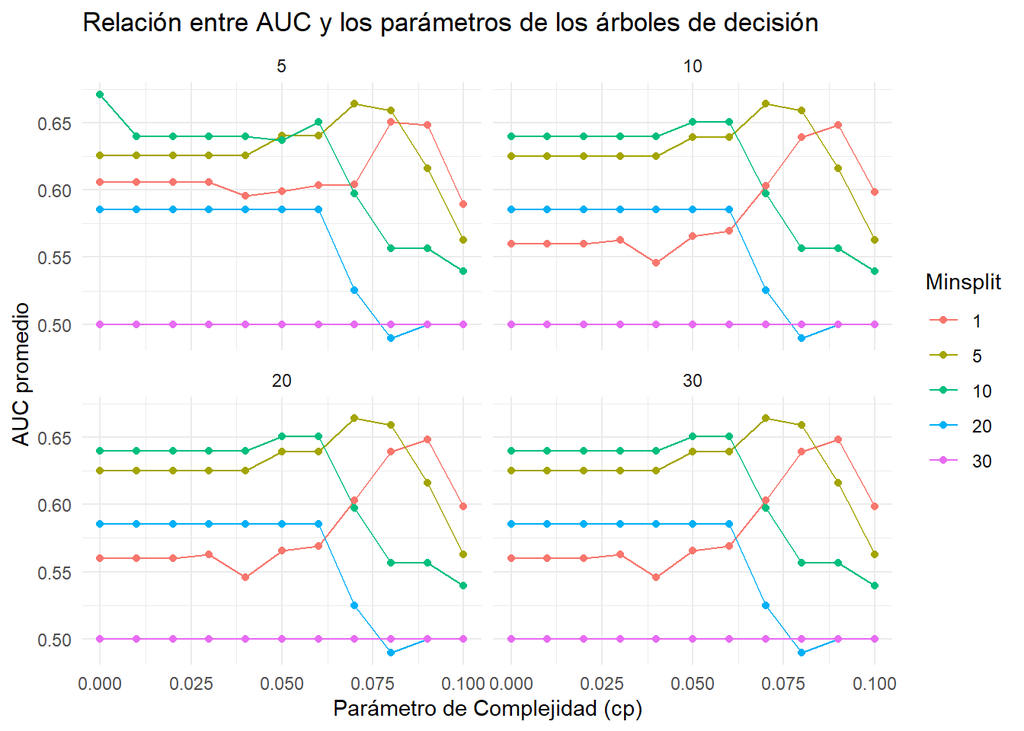

```r
# Generar gráficos ilustrativos
ggplot(results_summary, aes(x = cp, y = AUC, color = as.factor(minsplit))) +
  geom_line() +
  geom_point() +
  facet_wrap(~ maxdepth) +
  labs(title = "Relación entre AUC y los parámetros de los árboles de decisión",
       x = "Parámetro de Complejidad (cp)",
       y = "AUC promedio",
       color = "Minsplit") +
  theme_minimal()
```

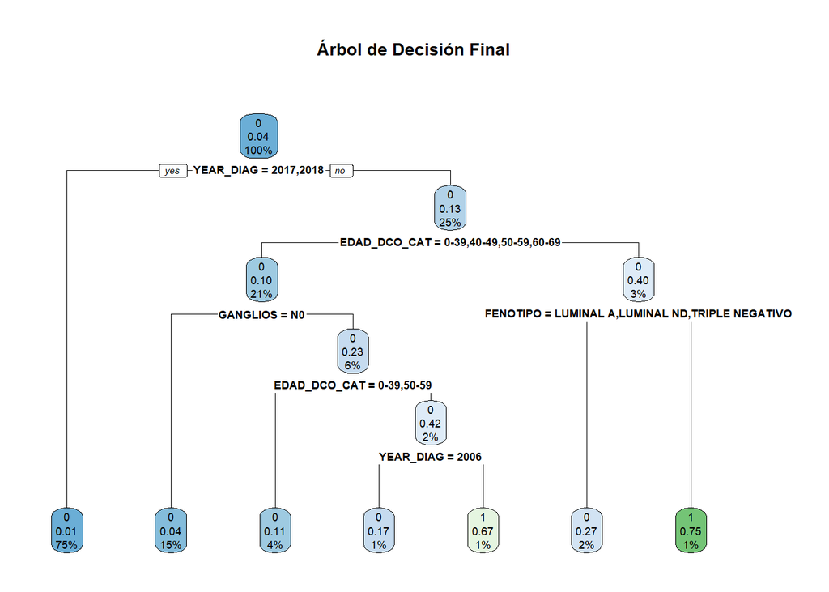

```r
# Entrenar el modelo final con la mejor combinación de parámetros y variables en todo el conjunto de datos
final_formula <- as.formula(paste("ESTADO_ACTUAL_BIN ~", paste(best_variables, collapse = " + ")))
modelo_final <- rpart(final_formula, data=datos_cancer_def, method="class",
                      control=rpart.control(cp=best_params$cp,
                                            minsplit=best_params$minsplit,
                                            maxdepth=best_params$maxdepth))

# Visualizar el árbol de decisión
rpart.plot(modelo_final, main="Árbol de Decisión Final")
```

```r
# Evaluar el modelo final
pred_final <- predict(modelo_final, newdata=datos_cancer_def, type="prob")[,2]
auc_final <- auc(as.numeric(datos_cancer_def$ESTADO_ACTUAL_BIN), pred_final)

print(paste("AUC del modelo final:", auc_final))
```

```
## [1] "AUC del modelo final: 0.870232031692133"
```

La selección de variables en este caso ayuda bastante a que la complejidad del árbol se reduzca y no sea tan extenso.

Mejores parámetros cp =0, minsplit =10 y maxdepth=5. En este caso tener más profundidad en el árbol podría provocar que fuera excesivamente complejo y el árbol se centrara más en clasificar las clases negativas en vez de positivas.

El resultado del modelo final es decente para clasificar clases de ESTADO_ACTUAL

## 4.8 5x2 Decision tree. Wrapper StepAIC

```r
# Cargar las librerías necesarias
library(caret)
library(pROC)
library(rpart)
library(rpart.plot)
library(ggplot2)
library(dplyr)
library(MASS)

# Definir el rango de búsqueda de los parámetros
cp_values <- seq(0, 0.1, by=0.01)
minsplit_values <- c(1, 5, 10, 20, 30)
maxdepth_values <- c(5, 10, 20, 30)

# Crear las combinaciones de los parámetros
parametros <- expand.grid(cp = cp_values, minsplit = minsplit_values, maxdepth = maxdepth_values)

# Crear las cajas de test y entrenamiento para el outer-loop
set.seed(123)
folds_outer <- createFolds(datos_cancer_def$ESTADO_ACTUAL_BIN, k = 5)

# Inicializar la matriz para almacenar los resultados del outer-loop
results <- data.frame(cp = numeric(), minsplit = numeric(), maxdepth = numeric(), AUC = numeric(), fold = integer(), variables = character())

# Realizar la validación cruzada 5x2
# Outer-loop
for(i in 1:5){
  # Obtener índices para entrenamiento y prueba en el outer-loop
  test_indices_outer <- folds_outer[[i]]
  train_data_outer <- datos_cancer_def[-test_indices_outer, ]
  test_data_outer <- datos_cancer_def[test_indices_outer, ]

  # Selección de variables usando stepAIC (backward)
  full_model <- glm(ESTADO_ACTUAL_BIN ~ ., data = train_data_outer, family = binomial)
  step_model <- stepAIC(full_model, direction = "backward", trace = FALSE)
  top_vars <- names(step_model$model)[-1]  # Seleccionar las mejores variables

  # Crear las cajas de validación y entrenamiento para el inner-loop
  folds_inner <- createFolds(train_data_outer$ESTADO_ACTUAL_BIN, k = 2)

  best_inner_result <- NULL

  # Inner-loop
  for(j in 1:2){
    # Separar los datos en conjuntos de entrenamiento y validación
    val_indices_inner <- folds_inner[[j]]
    train_data_inner <- train_data_outer[-val_indices_inner, ]
    val_data_inner <- train_data_outer[val_indices_inner, ]

    # Crear fórmula con las variables seleccionadas
    formula <- as.formula(paste("ESTADO_ACTUAL_BIN ~", paste(top_vars, collapse = " + ")))

    # Ajustar el modelo para cada combinación de parámetros
    for(k in 1:nrow(parametros)){
      # Entrenar el modelo con la combinación de parámetros
      modelo <- rpart(formula, data=train_data_inner, method="class",
                      control=rpart.control(cp=parametros$cp[k],
                                            minsplit=parametros$minsplit[k],
                                            maxdepth=parametros$maxdepth[k]))

      # Predecir en los datos de validación
      pred <- predict(modelo, newdata=val_data_inner, type="prob")[,2]

      # Calcular el AUC
      auc_value <- auc(as.numeric(val_data_inner$ESTADO_ACTUAL_BIN), pred)

      # Almacenar los resultados
      results <- rbind(results, data.frame(cp = parametros$cp[k],
                                           minsplit = parametros$minsplit[k],
                                           maxdepth = parametros$maxdepth[k],
                                           AUC = auc_value, fold = i, variables = paste(top_vars, collapse = ", ")))

      # Guardar el mejor resultado del inner-loop
      if (is.null(best_inner_result) || auc_value > best_inner_result$AUC) {
        best_inner_result <- data.frame(cp = parametros$cp[k],
                                        minsplit = parametros$minsplit[k],
                                        maxdepth = parametros$maxdepth[k],
                                        AUC = auc_value,
                                        fold = i, variables = paste(top_vars, collapse = ", "))
      }
    }
  }

  # Entrenar el modelo en el outer-loop con los mejores parámetros y variables del inner-loop
  best_vars <- unlist(strsplit(best_inner_result$variables, ", "))
  final_formula <- as.formula(paste("ESTADO_ACTUAL_BIN ~", paste(best_vars, collapse = " + ")))

  modelo_final <- rpart(final_formula, data=train_data_outer, method="class",
                        control=rpart.control(cp=best_inner_result$cp,
                                              minsplit=best_inner_result$minsplit,
                                              maxdepth=best_inner_result$maxdepth))

  # Evaluar el modelo en los datos de prueba del outer-loop
  pred_outer <- predict(modelo_final, newdata=test_data_outer, type="prob")[,2]
  auc_outer <- auc(as.numeric(test_data_outer$ESTADO_ACTUAL_BIN), pred_outer)

  # Almacenar el AUC del outer-loop
  results <- rbind(results, data.frame(cp = best_inner_result$cp,
                                       minsplit = best_inner_result$minsplit,
                                       maxdepth = best_inner_result$maxdepth,
                                       AUC = auc_outer,
                                       fold = i, variables = best_inner_result$variables))
}

# Calcular el promedio del AUC para cada combinación de parámetros
results_summary <- aggregate(AUC ~ cp + minsplit + maxdepth, data = results, FUN = mean)

# Mostrar la tabla de resumen
print(results_summary)
```

```
##       cp minsplit maxdepth       AUC
## 1   0.00        1        5 0.6459725
## 2   0.01        1        5 0.6459725
## 3   0.02        1        5 0.6459725
## 4   0.03        1        5 0.6459725
## 5   0.04        1        5 0.6459725
## 6   0.05        1        5 0.6147177
## 7   0.06        1        5 0.6147177
## 8   0.07        1        5 0.5922819
## 9   0.08        1        5 0.6015985
## 10  0.09        1        5 0.5817300
## 11  0.10        1        5 0.5391531
## 12  0.00        5        5 0.6650564
## 13  0.01        5        5 0.6489007
## 14  0.02        5        5 0.6489007
```

[output cut: 206 more lines]

```r
# Identificar la mejor combinación de parámetros
best_params <- results_summary[which.max(results_summary$AUC), ]
print(best_params)
```

```
##    cp minsplit maxdepth       AUC
## 12  0        5        5 0.6650564
```

```r
# Obtener las mejores variables asociadas a los mejores parámetros
best_result <- results[which.max(results$AUC), ]
best_iteration <- best_result$fold
best_variables <- strsplit(best_result$variables, ", ")[[1]]

print(paste("Mejores variables:", paste(best_variables, collapse = ", ")))
```

```
## [1] "Mejores variables: CIRUGIA, TAM, GRADO, FENOTIPO, GANGLIOS, EDAD_DCO_CAT, YEAR_DIAG, ESTADIO_CAT"
```

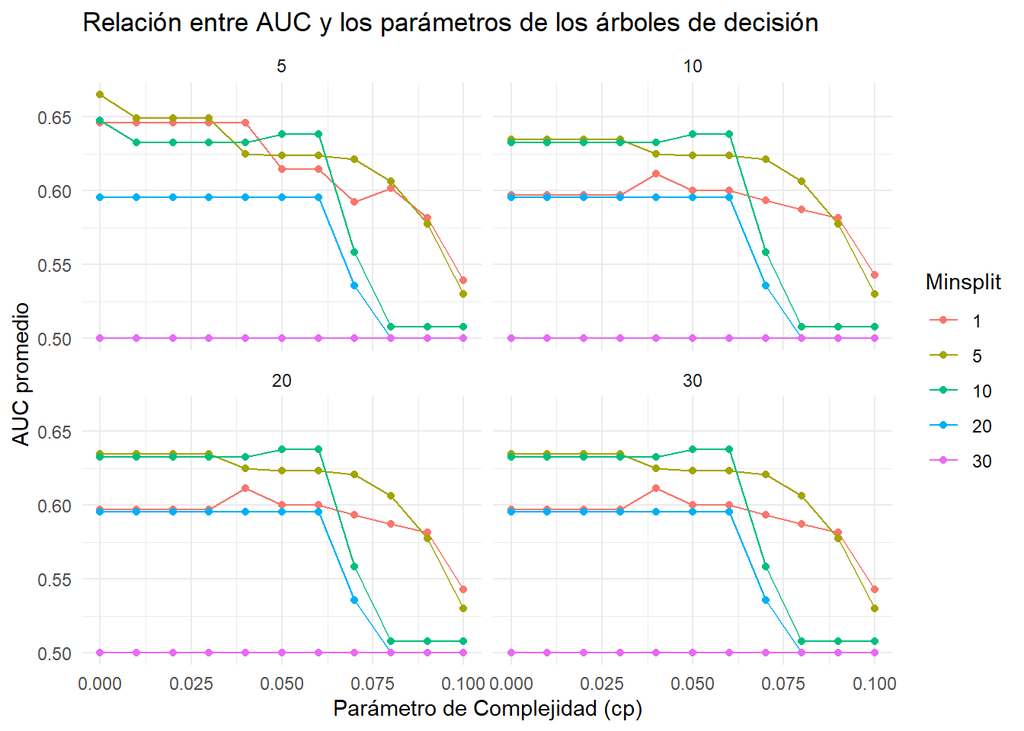

```r
# Generar gráficos ilustrativos
ggplot(results_summary, aes(x = cp, y = AUC, color = as.factor(minsplit))) +
  geom_line() +
  geom_point() +
  facet_wrap(~ maxdepth) +
  labs(title = "Relación entre AUC y los parámetros de los árboles de decisión",
       x = "Parámetro de Complejidad (cp)",
       y = "AUC promedio",
       color = "Minsplit") +
  theme_minimal()
```

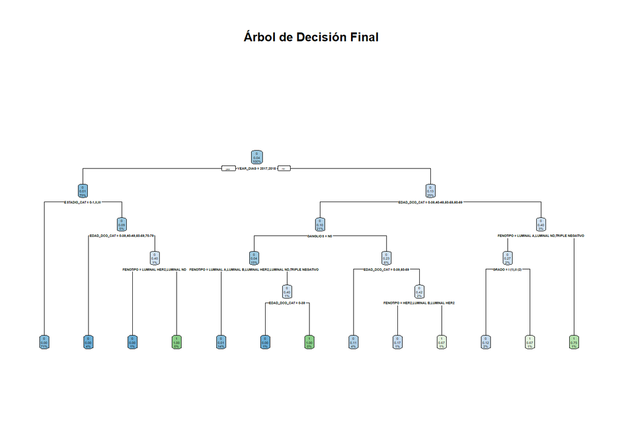

```r
# Entrenar el modelo final con la mejor combinación de parámetros y variables en todo el conjunto de datos
final_formula <- as.formula(paste("ESTADO_ACTUAL_BIN ~", paste(best_variables, collapse = " + ")))
modelo_final <- rpart(final_formula, data=datos_cancer_def, method="class",
                      control=rpart.control(cp=best_params$cp,
                                            minsplit=best_params$minsplit,
                                            maxdepth=best_params$maxdepth))

# Visualizar el árbol de decisión
rpart.plot(modelo_final, main="Árbol de Decisión Final")
```

```r
# Evaluar el modelo final
pred_final <- predict(modelo_final, newdata=datos_cancer_def, type="prob")[,2]
auc_final <- auc(as.numeric(datos_cancer_def$ESTADO_ACTUAL_BIN), pred_final)

print(paste("AUC del modelo final:", auc_final))
```

```
## [1] "AUC del modelo final: 0.952405206564799"
```

Los mismo parámetros que tenía relevancia antes, la tienen con el filtrado de StepAIC. Tener un cp como 0, puede dar pie a que la complejidad sea excesiva para el dataset. El árbol del modelo es más complejo que el de chi_cuadrado y realmente era lo se esperaba teniendo en cuenta que el número de variables seleccionadas en stepAIC es muy superior a chi_cuadraddo.

Al entrenar el modelo final con todo el dataset con los mejores parámetros y variables sale un resultado (al igual que los anteriores modelos predictivo) demasiado elevado, pudiéndose tratar de overfitting por el aprendizaje de los datos de entrenamiento.

## 4.9 5x2 KNN. Normal

La idea del modelo de knn es clasificar los datos como puntos en el espacion n-dimensional (siendo n el número de variables), cuando estén posicionados en el espacio knn intentará agrupar puntos que estén cercanos entre sí para clasificar las clases de ESTADO_ACTUAL_BIN.

Para ello tendremos que pasar todas las variables a tipo dummy para que se puedan posicionar en el espacio. Además de que para saber como de cercanos están los puntos para clasificarlos por otros puntos con las mismas características tenemos que calcular la distancia entre ellos.

Parámetros utilizados:

- k: número de vecinos para considerar clasificarlos. Con valores muy pequeños, puede ser sensible al ruido en los datos. Con valores grandes, pueden suavizar demasiado las fronteras de decisión y perder detalles importantes para la clasificación de los puntos.
- l: es la métrica utilizada para calcular la distancia entre vecinos más cercanos. Hay dos tipos; 1: distancia Manhattan suma de las distancias absolutas entre las coordenadas de los puntos y 2: distancia recta entre dos puntos en el espacio.

```r
library(class)
library(caret)
library(pROC)
library(e1071)
library(ggplot2)
library(dplyr)

# Convertir la variable objetivo a factor si no lo está
datos_cancer_def$ESTADO_ACTUAL_BIN <- as.factor(datos_cancer_def$ESTADO_ACTUAL_BIN)

# Listado de variables a convertir a dummies
variables_a_dummy <- c("RP", "RE", "GRADO", "FENOTIPO", "GANGLIOS", "ESTADIO_CAT", "YEAR_DIAG", "MENOP", "CIRUGIA", "YEAR_DIAG", "TAM", "KI67", "EDAD_DCO_CAT")

# Crear un modelo de dummyVars con las variables indicadas
dummy_model <- dummyVars(~ RP + RE + GRADO + FENOTIPO + GANGLIOS + ESTADIO_CAT + YEAR_DIAG + MENOP + CIRUGIA + YEAR_DIAG + TAM + KI67 + EDAD_DCO_CAT,
                         data = datos_cancer_def, fullRank = TRUE)

# Aplicar el modelo a los datos
datos_dummy <- predict(dummy_model, newdata = datos_cancer_def)

# Convertir a data frame y añadir la variable objetivo
datos_dummy <- as.data.frame(datos_dummy)
datos_dummy$ESTADO_ACTUAL_BIN <- datos_cancer_def$ESTADO_ACTUAL_BIN

# Normalizar las variables numéricas
datos_normalizados <- datos_dummy %>%
  mutate_if(is.numeric, scale)

# Definir el rango de búsqueda de los parámetros
k_values <- seq(1, 25, by=1)  # Valores impares de k para evitar empates
l_values <- c(1, 2)  # l = 1 para Manhattan, l = 2 para Euclidiana

# Crear las combinaciones de los parámetros
parametros <- expand.grid(k = k_values, l = l_values)

# Crear las cajas de test y entrenamiento para el outer-loop
set.seed(123)
folds_outer <- createFolds(datos_normalizados$ESTADO_ACTUAL_BIN, k = 5)

# Inicializar la matriz para almacenar los resultados del outer-loop
results <- data.frame(k = integer(), l = numeric(), AUC = numeric())

# Realizar la validación cruzada 5x2
# Outer-loop
for(i in 1:5){
  # Obtener índices para entrenamiento y prueba en el outer-loop
  test_indices_outer <- folds_outer[[i]]
  train_data_outer <- datos_normalizados[-test_indices_outer, ]
  test_data_outer <- datos_normalizados[test_indices_outer, ]

  # Crear las cajas de validación y entrenamiento para el inner-loop
  folds_inner <- createFolds(train_data_outer$ESTADO_ACTUAL_BIN, k = 2)

  # Inner-loop
  for(j in 1:2){
    # Separar los datos en conjuntos de entrenamiento y validación
    val_indices_inner <- folds_inner[[j]]
    train_data_inner <- train_data_outer[-val_indices_inner, ]
    val_data_inner <- train_data_outer[val_indices_inner, ]

    # Ajustar el modelo para cada combinación de parámetros
    for(k in 1:nrow(parametros)){
      # Entrenar y predecir usando KNN con la combinación de parámetros
      knn_model <- knn(train = train_data_inner[, -ncol(train_data_inner)],
                       test = val_data_inner[, -ncol(val_data_inner)],
                       cl = train_data_inner$ESTADO_ACTUAL_BIN,
                       k = parametros$k[k],
                       prob = TRUE,
                       use.all = TRUE,
                       l = parametros$l[k])

      # Obtener las probabilidades de la clase positiva
      probs <- attr(knn_model, "prob")
      probs <- ifelse(knn_model == levels(train_data_inner$ESTADO_ACTUAL_BIN)[2], probs, 1 - probs)

      # Calcular el AUC
      auc_value <- auc(val_data_inner$ESTADO_ACTUAL_BIN, probs)

      # Almacenar los resultados
      results <- rbind(results, data.frame(k = parametros$k[k],
                                           l = parametros$l[k], AUC = auc_value))
    }
  }
}

# Calcular el promedio del AUC para cada combinación de parámetros
results_summary <- aggregate(AUC ~ k + l, data = results, FUN = mean)

# Mostrar la tabla de resumen
print(results_summary)

# Identificar la mejor combinación de parámetros
best_params <- results_summary[which.max(results_summary$AUC), ]
print(best_params)

# Generar gráficos ilustrativos
ggplot(results_summary, aes(x = k, y = AUC, color = as.factor(l))) +
  geom_line() +
  geom_point() +
  labs(title = "Relación entre AUC y los parámetros de KNN",
       x = "Número de Vecinos (k)",
       y = "AUC promedio",
       color = "Parámetro de Distancia (l)") +
  theme_minimal()

# Entrenar el modelo final con la mejor combinación de parámetros en todo el conjunto de datos
knn_final <- knn(train = datos_normalizados[, -ncol(datos_normalizados)],
                 test = datos_normalizados[, -ncol(datos_normalizados)],
                 cl = datos_normalizados$ESTADO_ACTUAL_BIN,
                 k = best_params$k,
                 prob = TRUE,
                 use.all = TRUE,
                 l = best_params$l)

# Obtener las probabilidades de la clase positiva
probs_final <- attr(knn_final, "prob")
probs_final <- ifelse(knn_final == levels(datos_normalizados$ESTADO_ACTUAL_BIN)[2], probs_final, 1 - probs_final)

# Evaluar el modelo final
auc_final <- auc(datos_normalizados$ESTADO_ACTUAL_BIN, probs_final)

print(paste("AUC del modelo final:", auc_final))
```

El código nos devuelve el error “no case observation”, que nos informa que en la división de los datos, las clases de ESTADO_ACTUAL_BIN no se han repartido correctamente entre entrenamiento y prueba, dando lugar a que dentro de prueba esten clases que no estaban en entrenamiento.

## 4.10 5x2 KNN. Filtrado chi_squared

He intentado realizar aplicar el método Filter sin éxito tras estar intentando arreglarlo durante horas, no consigo saber porqué no funciona.

```r
library(class)
library(caret)
library(pROC)
library(e1071)
library(ggplot2)
library(dplyr)
library(FSelector)

# Convertir la variable objetivo a factor si no lo está
datos_cancer_def$ESTADO_ACTUAL_BIN <- as.factor(datos_cancer_def$ESTADO_ACTUAL_BIN)

# Listado de variables a convertir a dummies
variables_a_dummy <- c("RP", "RE", "GRADO", "FENOTIPO", "GANGLIOS", "ESTADIO_CAT", "YEAR_DIAG", "MENOP", "CIRUGIA", "YEAR_DIAG", "TAM", "KI67", "EDAD_DCO_CAT")

# Crear un modelo de dummyVars con las variables indicadas
dummy_model <- dummyVars(~ RP + RE + GRADO + FENOTIPO + GANGLIOS + ESTADIO_CAT + YEAR_DIAG + MENOP + CIRUGIA + YEAR_DIAG + TAM + KI67 + EDAD_DCO_CAT,
                         data = datos_cancer_def, fullRank = TRUE)

# Aplicar el modelo a los datos
datos_dummy <- predict(dummy_model, newdata = datos_cancer_def)

# Convertir a data frame y añadir la variable objetivo
datos_dummy <- as.data.frame(datos_dummy)
datos_dummy$ESTADO_ACTUAL_BIN <- datos_cancer_def$ESTADO_ACTUAL_BIN

# Normalizar las variables numéricas
datos_normalizados <- datos_dummy %>%
  mutate_if(is.numeric, scale)

# Definir el rango de búsqueda de los parámetros
k_values <- seq(1, 25, by=1)  # Valores impares de k para evitar empates
l_values <- c(1, 2)  # l = 1 para Manhattan, l = 2 para Euclidiana

# Crear las combinaciones de los parámetros
parametros <- expand.grid(k = k_values, l = l_values)

# Crear las cajas de test y entrenamiento para el outer-loop
set.seed(123)
folds_outer <- createFolds(datos_normalizados$ESTADO_ACTUAL_BIN, k = 5)

# Inicializar la matriz para almacenar los resultados del outer-loop
results <- data.frame(k = integer(), l = numeric(), AUC = numeric(), fold = integer(), variables = character())

# Función para calcular el AUC en la validación cruzada
calc_auc <- function(train_data, val_data, params, vars) {
  knn_model <- knn(train = train_data[, vars],
                   test = val_data[, vars],
                   cl = train_data$ESTADO_ACTUAL_BIN,
                   k = params$k,
                   prob = TRUE,
                   use.all = TRUE,
                   l = params$l)

  # Verificar si ambas clases están presentes
  if (length(unique(train_data$ESTADO_ACTUAL_BIN)) < 2 || length(unique(val_data$ESTADO_ACTUAL_BIN)) < 2) {
    return(NA)  # Si no hay ambas clases, devolver NA
  }

  # Obtener las probabilidades de la clase positiva
  probs <- attr(knn_model, "prob")
  probs <- ifelse(knn_model == levels(train_data$ESTADO_ACTUAL_BIN)[2], probs, 1 - probs)

  # Calcular el AUC
  auc_value <- auc(as.numeric(val_data$ESTADO_ACTUAL_BIN), probs)
  return(auc_value)
}

# Realizar la validación cruzada 5x2
# Outer-loop
for(i in 1:5){
  # Obtener índices para entrenamiento y prueba en el outer-loop
  test_indices_outer <- folds_outer[[i]]
  train_data_outer <- datos_normalizados[-test_indices_outer, ]
  test_data_outer <- datos_normalizados[test_indices_outer, ]

  train_data_outer_over <- oversample_data(train_data_outer,"ESTADO_ACTUAL_BIN")

  # Selección de variables usando chi_squared en el outer-loop
  chi_weights <- chi.squared(ESTADO_ACTUAL_BIN ~ ., data = train_data_outer_over)
  top_vars <- cutoff.k(chi_weights, 5)  # Seleccionar las 10 mejores variables

  # Convertir nombres de columnas dummy a nombres de variables originales
  top_vars_original <- unique(sapply(top_vars, function(x) unlist(strsplit(x, split = "\\."))[1]))

  best_inner_result <- NULL

  # Crear las cajas de validación y entrenamiento para el inner-loop
  folds_inner <- createFolds(train_data_outer_over$ESTADO_ACTUAL_BIN, k = 2)

  # Inner-loop
  for(j in 1:2){
    # Separar los datos en conjuntos de entrenamiento y validación
    val_indices_inner <- folds_inner[[j]]
    train_data_inner <- train_data_outer_over[-val_indices_inner, ]
    val_data_inner <- train_data_outer_over[val_indices_inner, ]

    best_auc <- 0

    # Evaluar cada combinación de parámetros
    for(k in 1:nrow(parametros)){
      auc_value <- calc_auc(train_data_inner, val_data_inner, parametros[k, ], top_vars)

      if (!is.na(auc_value) && auc_value > best_auc) {
        best_auc <- auc_value
        best_params <- parametros[k, ]
      }
    }

    # Almacenar el mejor resultado del inner-loop
    best_inner_result <- data.frame(k = best_params$k,
                                    l = best_params$l, AUC = best_auc,
                                    fold = i, variables = paste(top_vars, collapse = ", "))
  }

  # Entrenar el modelo en el outer-loop con los mejores parámetros y variables del inner-loop
  knn_final <- knn(train = train_data_outer_over[, top_vars],
                   test = test_data_outer[, top_vars],
                   cl = train_data_outer_over$ESTADO_ACTUAL_BIN,
                   k = best_inner_result$k,
                   prob = TRUE,
                   use.all = TRUE,
                   l = best_inner_result$l)

  # Obtener las probabilidades de la clase positiva
  prob_outer <- attr(knn_final, "prob")
  prob_outer <- ifelse(knn_final == levels(train_data_outer_over$ESTADO_ACTUAL_BIN)[2], prob_outer, 1 - prob_outer)

  # Verificar que las longitudes coinciden
  if (length(prob_outer) == length(test_data_outer$ESTADO_ACTUAL_BIN)) {
    auc_outer <- auc(as.numeric(test_data_outer$ESTADO_ACTUAL_BIN), prob_outer)
  } else {
    auc_outer <- NA
  }

  # Almacenar el AUC del outer-loop
  results <- rbind(results, data.frame(k = best_inner_result$k,
                                       l = best_inner_result$l, AUC = auc_outer,
                                       fold = i, variables = paste(top_vars_original, collapse = ", ")))
}

# Calcular el promedio del AUC para cada combinación de parámetros
results_summary <- aggregate(AUC ~ k + l, data = results, FUN = mean, na.rm = TRUE)

# Mostrar la tabla de resumen
print(results_summary)

# Identificar la mejor combinación de parámetros
best_params <- results_summary[which.max(results_summary$AUC), ]
print(best_params)

# Filtrar resultados para eliminar NAs
results_filtered <- results[!is.na(results$AUC), ]

# Obtener las mejores variables asociadas a los mejores parámetros
best_result <- results_filtered[which.max(results_filtered$AUC), ]
best_iteration <- best_result$fold
best_variables <- strsplit(best_result$variables, ", ")[[1]]

print(paste("Mejores variables:", paste(best_variables, collapse = ", ")))

# Generar gráficos ilustrativos
ggplot(results_summary, aes(x = k, y = AUC, color = as.factor(l))) +
  geom_line() +
  geom_point() +
  labs(title = "Relación entre AUC y los parámetros de KNN",
       x = "Número de Vecinos (k)",
       y = "AUC promedio",
       color = "Parámetro de Distancia (l)") +
  theme_minimal()

# Entrenar el modelo final con la mejor combinación de parámetros en todo el conjunto de datos
knn_final <- knn(train = datos_normalizados[, best_variables],
                 test = datos_normalizados[, best_variables],
                 cl = datos_normalizados$ESTADO_ACTUAL_BIN,
                 k = best_params$k,
                 prob = TRUE,
                 use.all = TRUE,
                 l = best_params$l)

# Obtener las probabilidades de la clase positiva
probs_final <- attr(knn_final, "prob")
probs_final <- ifelse(knn_final == levels(datos_normalizados$ESTADO_ACTUAL_BIN)[2], probs_final, 1 - probs_final)

# Evaluar el modelo final
auc_final <- auc(as.numeric(datos_normalizados$ESTADO_ACTUAL_BIN), probs_final)

print(paste("AUC del modelo final:", auc_final))
```

Al ejecutarlo me devuelve Error in roc.default(response, predictor, auc = TRUE, …) : No case observation. Que según parece no es capaz de detectar clases positivas en alguno de los folds después de hacer la selección de variables, y aunque he realizado un oversampling en cada train_data_outer me sigue dando el mismo error.

## 4.11 5x2 KNN.Filtrado wrapper StepAIC

```r
library(class)
library(caret)
library(pROC)
library(e1071)
library(ggplot2)
library(dplyr)
library(MASS)

# Convertir la variable objetivo a factor si no lo está
datos_cancer_def$ESTADO_ACTUAL_BIN <- as.factor(datos_cancer_def$ESTADO_ACTUAL_BIN)

# Listado de variables a convertir a dummies
variables_a_dummy <- c("RP", "RE", "GRADO", "FENOTIPO", "GANGLIOS", "ESTADIO_CAT", "YEAR_DIAG", "MENOP", "CIRUGIA", "YEAR_DIAG", "TAM", "KI67", "EDAD_DCO_CAT")

# Crear un modelo de dummyVars con las variables indicadas
dummy_model <- dummyVars(~ RP + RE + GRADO + FENOTIPO + GANGLIOS + ESTADIO_CAT + YEAR_DIAG + MENOP + CIRUGIA + YEAR_DIAG + TAM + KI67 + EDAD_DCO_CAT,
                         data = datos_cancer_def, fullRank = TRUE)

# Aplicar el modelo a los datos
datos_dummy <- predict(dummy_model, newdata = datos_cancer_def)

# Convertir a data frame y añadir la variable objetivo
datos_dummy <- as.data.frame(datos_dummy)
datos_dummy$ESTADO_ACTUAL_BIN <- datos_cancer_def$ESTADO_ACTUAL_BIN

# Normalizar las variables numéricas
datos_normalizados <- datos_dummy %>%
  mutate_if(is.numeric, scale)

# Definir el rango de búsqueda de los parámetros
k_values <- seq(1, 25, by=1)  # Valores impares de k para evitar empates
l_values <- c(1, 2)  # l = 1 para Manhattan, l = 2 para Euclidiana

# Crear las combinaciones de los parámetros
parametros <- expand.grid(k = k_values, l = l_values)

# Crear las cajas de test y entrenamiento para el outer-loop
set.seed(123)
folds_outer <- createFolds(datos_normalizados$ESTADO_ACTUAL_BIN, k = 5)

# Inicializar la matriz para almacenar los resultados del outer-loop
results <- data.frame(k = integer(), l = numeric(), AUC = numeric(), fold = integer(), variables = character())

# Realizar la validación cruzada 5x2
# Outer-loop
for(i in 1:5){
  # Obtener índices para entrenamiento y prueba en el outer-loop
  test_indices_outer <- folds_outer[[i]]
  train_data_outer <- datos_normalizados[-test_indices_outer, ]
  test_data_outer <- datos_normalizados[test_indices_outer, ]

  # Selección de variables usando StepAIC (forward)
  full_model <- glm(ESTADO_ACTUAL_BIN ~ ., data = train_data_outer, family = binomial)
  step_model <- stepAIC(full_model, direction = "forward", trace = FALSE)
  top_vars <- names(step_model$model)[-1]  # Seleccionar las mejores variables

  # Crear las cajas de validación y entrenamiento para el inner-loop
  folds_inner <- createFolds(train_data_outer$ESTADO_ACTUAL_BIN, k = 2)

  best_inner_result <- NULL

  # Inner-loop
  for(j in 1:2){
    # Separar los datos en conjuntos de entrenamiento y validación
    val_indices_inner <- folds_inner[[j]]
    train_data_inner <- train_data_outer[-val_indices_inner, ]
    val_data_inner <- train_data_outer[val_indices_inner, ]

    # Ajustar el modelo para cada combinación de parámetros
    for(k in 1:nrow(parametros)){
      # Entrenar y predecir usando KNN con la combinación de parámetros
      knn_model <- knn(train = train_data_inner[, top_vars],
                       test = val_data_inner[, top_vars],
                       cl = train_data_inner$ESTADO_ACTUAL_BIN,
                       k = parametros$k[k],
                       prob = TRUE,
                       use.all = TRUE,
                       l = parametros$l[k])

      # Obtener las probabilidades de la clase positiva
      probs <- attr(knn_model, "prob")
      probs <- ifelse(knn_model == levels(train_data_inner$ESTADO_ACTUAL_BIN)[2], probs, 1 - probs)

      # Calcular el AUC
      auc_value <- auc(val_data_inner$ESTADO_ACTUAL_BIN, probs)

      # Almacenar los resultados
      results <- rbind(results, data.frame(k = parametros$k[k],
                                           l = parametros$l[k], AUC = auc_value, fold = i, variables = paste(top_vars, collapse = ", ")))

      # Guardar el mejor resultado del inner-loop
      if (is.null(best_inner_result) || auc_value > best_inner_result$AUC) {
        best_inner_result <- data.frame(k = parametros$k[k],
                                        l = parametros$l[k], AUC = auc_value,
                                        fold = i, variables = paste(top_vars, collapse = ", "))
      }
    }
  }

  # Entrenar el modelo en el outer-loop con los mejores parámetros y variables del inner-loop
  best_vars <- unlist(strsplit(best_inner_result$variables, ", "))
  final_formula <- as.formula(paste("ESTADO_ACTUAL_BIN ~", paste(best_vars, collapse = " + ")))

  # Ajustar el modelo final usando las mejores variables y parámetros
  modelo_final <- knn(train = train_data_outer[, best_vars],
                      test = test_data_outer[, best_vars],
                      cl = train_data_outer$ESTADO_ACTUAL_BIN,
                      k = best_inner_result$k,
                      prob = TRUE,
                      use.all = TRUE,
                      l = best_inner_result$l)

  # Obtener las probabilidades de la clase positiva
  probs_outer <- attr(modelo_final, "prob")
  probs_outer <- ifelse(modelo_final == levels(train_data_outer$ESTADO_ACTUAL_BIN)[2], probs_outer, 1 - probs_outer)

  # Calcular el AUC
  auc_outer <- auc(test_data_outer$ESTADO_ACTUAL_BIN, probs_outer)

  # Almacenar el AUC del outer-loop
  results <- rbind(results, data.frame(k = best_inner_result$k,
                                       l = best_inner_result$l, AUC = auc_outer,
                                       fold = i, variables = best_inner_result$variables))
}

# Calcular el promedio del AUC para cada combinación de parámetros
results_summary <- aggregate(AUC ~ k + l, data = results, FUN = mean)

# Mostrar la tabla de resumen
print(results_summary)

# Identificar la mejor combinación de parámetros
best_params <- results_summary[which.max(results_summary$AUC), ]
print(best_params)

# Obtener las mejores variables asociadas a los mejores parámetros
best_result <- results[which.max(results$AUC), ]
best_iteration <- best_result$fold
best_variables <- strsplit(best_result$variables, ", ")[[1]]

print(paste("Mejores variables:", paste(best_variables, collapse = ", ")))

# Generar gráficos ilustrativos
ggplot(results_summary, aes(x = k, y = AUC, color = as.factor(l))) +
  geom_line() +
  geom_point() +
  labs(title = "Relación entre AUC y los parámetros de KNN",
       x = "Número de Vecinos (k)",
       y = "AUC promedio",
       color = "Parámetro de Distancia (l)") +
  theme_minimal()

# Entrenar el modelo final con los mejores parámetros y variables en todo el conjunto de datos
knn_final <- knn(train = datos_normalizados[, best_variables],
                 test = datos_normalizados[, best_variables],
                 cl = datos_normalizados$ESTADO_ACTUAL_BIN,
                 k = best_params$k,
                 prob = TRUE,
                 use.all = TRUE,
                 l = best_params$l)

# Obtener las probabilidades de la clase positiva
probs_final <- attr(knn_final, "prob")
probs_final <- ifelse(knn_final == levels(datos_normalizados$ESTADO_ACTUAL_BIN)[2], probs_final, 1 - probs_final)

# Evaluar el modelo final
auc_final <- auc(datos_normalizados$ESTADO_ACTUAL_BIN, probs_final)

print(paste("AUC del modelo final:", auc_final))
```

El error que devuelve es el mismo que los anteriores.

## 4.12 5x2 Naive Bayes. Chi_squared

Se basa en la aplicación del teorema de Bayes, que calcula la probabilidad de un evento, basándose en el conocimiento previo de condiciones que podrían estar relacionadas con el evento.

Parámetros utilizados:

- laplace: Se usa para manejar el problema de probabilidad cero en Naive Bayes. 1: Se aplica suavización de Laplace, lo que añade 1 a las frecuencias de conteo, asegurando que ninguna probabilidad sea cero. 0: No se aplica suavización.
- usekernel: para la gestion de los datos continuos y normalizarlos para saber cual es su distribución normal. FALSE: Se asume que los datos están normalizados. TRUE: No se asume y se normalizan.
- adjust: Ajusta la suavización de la densidad de kernel. Cuanto más grande el valor más suavización

```r
library(e1071)
library(caret)
library(pROC)
library(ggplot2)
library(dplyr)
library(FSelector)

# Convertir la variable objetivo a factor si no lo está
datos_cancer_def$ESTADO_ACTUAL_BIN <- as.factor(datos_cancer_def$ESTADO_ACTUAL_BIN)

# Definir el rango de búsqueda de los parámetros
laplace_values <- c(0, 1)
usekernel_values <- c(TRUE, FALSE)
adjust_values <- c(1, 1.5, 2)

# Crear las combinaciones de los parámetros
parametros <- expand.grid(laplace = laplace_values, usekernel = usekernel_values, adjust = adjust_values)

# Crear las cajas de test y entrenamiento para el outer-loop
set.seed(123)
folds_outer <- createFolds(datos_cancer_def$ESTADO_ACTUAL_BIN, k = 5)

# Inicializar la matriz para almacenar los resultados del outer-loop
results <- data.frame(laplace = numeric(), usekernel = logical(), adjust = numeric(), AUC = numeric(), fold = integer(), variables = character())

# Realizar la validación cruzada 5x2
# Outer-loop
for(i in 1:5){
  # Obtener índices para entrenamiento y prueba en el outer-loop
  test_indices_outer <- folds_outer[[i]]
  train_data_outer <- datos_cancer_def[-test_indices_outer, ]
  test_data_outer <- datos_cancer_def[test_indices_outer, ]

  # Crear las cajas de validación y entrenamiento para el inner-loop
  folds_inner <- createFolds(train_data_outer$ESTADO_ACTUAL_BIN, k = 2)

  best_inner_result <- NULL
  # Selección de variables usando el método de chi-cuadrado
  weights <- chi.squared(ESTADO_ACTUAL_BIN ~ ., data = train_data_outer)
  top_vars <- cutoff.k(weights, 5)  # Seleccionar las 5 mejores variables

  # Inner-loop
  for(j in 1:2){
    # Separar los datos en conjuntos de entrenamiento y validación
    val_indices_inner <- folds_inner[[j]]
    train_data_inner <- train_data_outer[-val_indices_inner, ]
    val_data_inner <- train_data_outer[val_indices_inner, ]

    # Crear fórmula con las variables seleccionadas
    formula <- as.formula(paste("ESTADO_ACTUAL_BIN ~", paste(top_vars, collapse = " + ")))

    # Ajustar el modelo para cada combinación de parámetros
    for(k in 1:nrow(parametros)){
      # Entrenar el modelo Naive Bayes con la combinación de parámetros
      modelo <- naiveBayes(formula, data = train_data_inner,
                           laplace = parametros$laplace[k],
                           usekernel = parametros$usekernel[k],
                           adjust = parametros$adjust[k])

      # Predecir en los datos de validación
      pred <- predict(modelo, newdata = val_data_inner, type = "raw")[,2]

      # Calcular el AUC
      auc_value <- auc(as.numeric(val_data_inner$ESTADO_ACTUAL_BIN), pred)

      # Almacenar los resultados
      results <- rbind(results, data.frame(laplace = parametros$laplace[k],
                                           usekernel = parametros$usekernel[k],
                                           adjust = parametros$adjust[k],
                                           AUC = auc_value, fold = i, variables = paste(top_vars, collapse = ", ")))

      # Guardar el mejor resultado del inner-loop
      if (is.null(best_inner_result) || auc_value > best_inner_result$AUC) {
        best_inner_result <- data.frame(laplace = parametros$laplace[k],
                                        usekernel = parametros$usekernel[k],
                                        adjust = parametros$adjust[k],
                                        AUC = auc_value, fold = i, variables = paste(top_vars, collapse = ", "))
      }
    }
  }

  # Entrenar el modelo en el outer-loop con los mejores parámetros y variables del inner-loop
  best_vars <- unlist(strsplit(best_inner_result$variables, ", "))
  final_formula <- as.formula(paste("ESTADO_ACTUAL_BIN ~", paste(best_vars, collapse = " + ")))

  modelo_final <- naiveBayes(final_formula, data=train_data_outer,
                             laplace=best_inner_result$laplace,
                             usekernel=best_inner_result$usekernel,
                             adjust=best_inner_result$adjust)

  # Evaluar el modelo en los datos de prueba del outer-loop
  pred_outer <- predict(modelo_final, newdata=test_data_outer, type="raw")[,2]
  auc_outer <- auc(as.numeric(test_data_outer$ESTADO_ACTUAL_BIN), pred_outer)

  # Almacenar el AUC del outer-loop
  results <- rbind(results, data.frame(laplace = best_inner_result$laplace,
                                       usekernel = best_inner_result$usekernel,
                                       adjust = best_inner_result$adjust,
                                       AUC = auc_outer,
                                       fold = i, variables = best_inner_result$variables))
}

# Calcular el promedio del AUC para cada combinación de parámetros
results_summary <- aggregate(AUC ~ laplace + usekernel + adjust, data = results, FUN = mean)

# Mostrar la tabla de resumen
print(results_summary)
```

```
##    laplace usekernel adjust       AUC
## 1        0     FALSE    1.0 0.6422619
## 2        1     FALSE    1.0 0.7896793
## 3        0      TRUE    1.0 0.6422619
## 4        1      TRUE    1.0 0.7897145
## 5        0     FALSE    1.5 0.6422619
## 6        1     FALSE    1.5 0.7896793
## 7        0      TRUE    1.5 0.6422619
## 8        1      TRUE    1.5 0.7896793
## 9        0     FALSE    2.0 0.6422619
## 10       1     FALSE    2.0 0.7896793
## 11       0      TRUE    2.0 0.6422619
## 12       1      TRUE    2.0 0.7896793
```

```r
# Identificar la mejor combinación de parámetros
best_params <- results_summary[which.max(results_summary$AUC), ]
print(best_params)
```

```
##   laplace usekernel adjust       AUC
## 4       1      TRUE      1 0.7897145
```

```r
# Obtener las mejores variables asociadas a los mejores parámetros
best_result <- results[which.max(results$AUC), ]
best_iteration <- best_result$fold
best_variables <- strsplit(best_result$variables, ", ")[[1]]

print(paste("Mejores variables:", paste(best_variables, collapse = ", ")))
```

```
## [1] "Mejores variables: YEAR_DIAG, EDAD_DCO_CAT, ESTADIO_CAT, FENOTIPO, GANGLIOS"
```

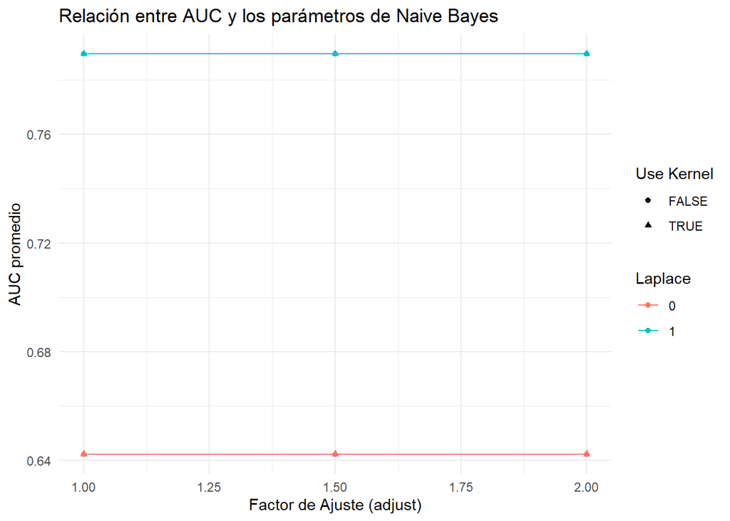

```r
# Generar gráficos ilustrativos
ggplot(results_summary, aes(x = adjust, y = AUC, color = as.factor(laplace), shape = as.factor(usekernel))) +
  geom_line() +
  geom_point() +
  labs(title = "Relación entre AUC y los parámetros de Naive Bayes",
       x = "Factor de Ajuste (adjust)",
       y = "AUC promedio",
       color = "Laplace",
       shape = "Use Kernel") +
  theme_minimal()
```

```r
# Entrenar el modelo final con la mejor combinación de parámetros y variables en todo el conjunto de datos
final_formula <- as.formula(paste("ESTADO_ACTUAL_BIN ~", paste(best_variables, collapse = " + ")))
modelo_final <- naiveBayes(final_formula, data=datos_cancer_def,
                           laplace=best_params$laplace,
                           usekernel=best_params$usekernel,
                           adjust=best_params$adjust)

# Evaluar el modelo final
pred_final_prob <- predict(modelo_final, newdata=datos_cancer_def, type="raw")[,2]
pred_final_class <- predict(modelo_final, newdata=datos_cancer_def)

# Calcular AUC del modelo final
auc_final <- auc(as.numeric(datos_cancer_def$ESTADO_ACTUAL_BIN), pred_final_prob)
print(paste("AUC del modelo final:", auc_final))
```

```
## [1] "AUC del modelo final: 0.915902659875495"
```

```r
# Crear la matriz de confusión
conf_matrix <- confusionMatrix(pred_final_class, datos_cancer_def$ESTADO_ACTUAL_BIN)
print(conf_matrix)
```

```
## Confusion Matrix and Statistics
##
##           Reference
## Prediction   0   1
##          0 463  15
##          1   2   4
##
##                Accuracy : 0.9649
##                  95% CI : (0.9444, 0.9794)
##     No Information Rate : 0.9607
##     P-Value [Acc > NIR] : 0.374888
##
##                   Kappa : 0.3069
##
##  Mcnemar's Test P-Value : 0.003609
##
##             Sensitivity : 0.9957
##             Specificity : 0.2105
##          Pos Pred Value : 0.9686
##          Neg Pred Value : 0.6667
##              Prevalence : 0.9607
##          Detection Rate : 0.9566
##    Detection Prevalence : 0.9876
##       Balanced Accuracy : 0.6031
##
##        'Positive' Class : 0
##
```

El rendimiento del modelo final es bueno con un valor de 0.91, pero no es consistente con el mejor modelo (0.78). Además evitaremos escogerlo como modelo definitivo para el despliegue de la aplicación, ya que puede no ser la opción más adecuada para conjuntos de datos muy desbalanceados, debido a que el modelo se basa en probabilidades anteriores y puede estar sesgado hacia las clases más frecuentes en el conjunto de datos de entrenamiento.

Para ver como había clasificado los datos decidí hacer una matriz de confusión del modelo y no clasifica las clases positivas correctamente.

El parámetro usekernel no es útil aquí, ya que no tenemos variables continuas. Todas son discretas.

## 4.13 5x2 Naive Bayes. StepAIC

```r
library(e1071)
library(caret)
library(pROC)
library(ggplot2)
library(dplyr)
library(MASS)

# Convertir la variable objetivo a factor si no lo está
datos_cancer_def$ESTADO_ACTUAL_BIN <- as.factor(datos_cancer_def$ESTADO_ACTUAL_BIN)

# Definir el rango de búsqueda de los parámetros
laplace_values <- c(0, 1)
usekernel_values <- c(TRUE, FALSE)
adjust_values <- c(1, 1.5, 2)

# Crear las combinaciones de los parámetros
parametros <- expand.grid(laplace = laplace_values, usekernel = usekernel_values, adjust = adjust_values)

# Crear las cajas de test y entrenamiento para el outer-loop
set.seed(123)
folds_outer <- createFolds(datos_cancer_def$ESTADO_ACTUAL_BIN, k = 5)

# Inicializar la matriz para almacenar los resultados del outer-loop
results <- data.frame(laplace = numeric(), usekernel = logical(), adjust = numeric(), AUC = numeric(), fold = integer(), variables = character())

# Realizar la validación cruzada 5x2
# Outer-loop
for(i in 1:5){
  # Obtener índices para entrenamiento y prueba en el outer-loop
  test_indices_outer <- folds_outer[[i]]
  train_data_outer <- datos_cancer_def[-test_indices_outer, ]
  test_data_outer <- datos_cancer_def[test_indices_outer, ]

  # Selección de variables usando stepAIC en el outer-loop
  full_model <- glm(ESTADO_ACTUAL_BIN ~ ., data=train_data_outer, family=binomial)
  step_model <- stepAIC(full_model, direction="backward", trace=FALSE)
  top_vars <- names(step_model$model)[-1]  # Obtener las mejores variables
  print(top_vars)

  # Crear las cajas de validación y entrenamiento para el inner-loop
  folds_inner <- createFolds(train_data_outer$ESTADO_ACTUAL_BIN, k = 2)

  best_inner_result <- NULL

  # Inner-loop
  for(j in 1:2){
    # Separar los datos en conjuntos de entrenamiento y validación
    val_indices_inner <- folds_inner[[j]]
    train_data_inner <- train_data_outer[-val_indices_inner, ]
    val_data_inner <- train_data_outer[val_indices_inner, ]

    # Crear fórmula con las variables seleccionadas
    formula <- as.formula(paste("ESTADO_ACTUAL_BIN ~", paste(top_vars, collapse = " + ")))

    # Ajustar el modelo para cada combinación de parámetros
    for(k in 1:nrow(parametros)){
      # Entrenar el modelo Naive Bayes con la combinación de parámetros
      modelo <- naiveBayes(formula, data = train_data_inner,
                           laplace = parametros$laplace[k],
                           usekernel = parametros$usekernel[k],
                           adjust = parametros$adjust[k])

      # Predecir en los datos de validación
      pred <- predict(modelo, newdata = val_data_inner, type = "raw")[,2]

      # Calcular el AUC
      auc_value <- auc(as.numeric(val_data_inner$ESTADO_ACTUAL_BIN), pred)

      # Almacenar los resultados
      results <- rbind(results, data.frame(laplace = parametros$laplace[k],
                                           usekernel = parametros$usekernel[k],
                                           adjust = parametros$adjust[k],
                                           AUC = auc_value, fold = i, variables = paste(top_vars, collapse = ", ")))

      # Guardar el mejor resultado del inner-loop
      if (is.null(best_inner_result) || auc_value > best_inner_result$AUC) {
        best_inner_result <- data.frame(laplace = parametros$laplace[k],
                                        usekernel = parametros$usekernel[k],
                                        adjust = parametros$adjust[k],
                                        AUC = auc_value, fold = i, variables = paste(top_vars, collapse = ", "))
      }
    }
  }

  # Entrenar el modelo en el outer-loop con los mejores parámetros y variables del inner-loop
  best_vars <- unlist(strsplit(best_inner_result$variables, ", "))
  final_formula <- as.formula(paste("ESTADO_ACTUAL_BIN ~", paste(best_vars, collapse = " + ")))

  modelo_final <- naiveBayes(final_formula, data=train_data_outer,
                             laplace=best_inner_result$laplace,
                             usekernel=best_inner_result$usekernel,
                             adjust=best_inner_result$adjust)

  # Evaluar el modelo en los datos de prueba del outer-loop
  pred_outer <- predict(modelo_final, newdata=test_data_outer, type="raw")[,2]
  auc_outer <- auc(as.numeric(test_data_outer$ESTADO_ACTUAL_BIN), pred_outer)

  # Almacenar el AUC del outer-loop
  results <- rbind(results, data.frame(laplace = best_inner_result$laplace,
                                       usekernel = best_inner_result$usekernel,
                                       adjust = best_inner_result$adjust,
                                       AUC = auc_outer,
                                       fold = i, variables = best_inner_result$variables))
}
```

```
## [1] "RP"           "GANGLIOS"     "EDAD_DCO_CAT" "YEAR_DIAG"    "ESTADIO_CAT"
## [1] "CIRUGIA"      "TAM"          "GRADO"        "FENOTIPO"     "GANGLIOS"
## [6] "EDAD_DCO_CAT" "YEAR_DIAG"    "ESTADIO_CAT"
## [1] "RP"           "GANGLIOS"     "EDAD_DCO_CAT" "YEAR_DIAG"    "ESTADIO_CAT"
## [1] "MENOP"       "FENOTIPO"    "YEAR_DIAG"   "ESTADIO_CAT"
## [1] "TAM"          "KI67"         "FENOTIPO"     "GANGLIOS"     "EDAD_DCO_CAT"
## [6] "YEAR_DIAG"    "ESTADIO_CAT"
```

```r
# Calcular el promedio del AUC para cada combinación de parámetros
results_summary <- aggregate(AUC ~ laplace + usekernel + adjust, data = results, FUN = mean)

# Mostrar la tabla de resumen
print(results_summary)
```

```
##    laplace usekernel adjust       AUC
## 1        0     FALSE    1.0 0.6793155
## 2        1     FALSE    1.0 0.7871112
## 3        0      TRUE    1.0 0.6793155
## 4        1      TRUE    1.0 0.7872856
## 5        0     FALSE    1.5 0.6793155
## 6        1     FALSE    1.5 0.7871112
## 7        0      TRUE    1.5 0.6793155
## 8        1      TRUE    1.5 0.7871112
## 9        0     FALSE    2.0 0.6793155
## 10       1     FALSE    2.0 0.7871112
## 11       0      TRUE    2.0 0.6793155
## 12       1      TRUE    2.0 0.7871112
```

```r
# Identificar la mejor combinación de parámetros
best_params <- results_summary[which.max(results_summary$AUC), ]
print(best_params)
```

```
##   laplace usekernel adjust       AUC
## 4       1      TRUE      1 0.7872856
```

```r
# Obtener las mejores variables asociadas a los mejores parámetros
best_result <- results[which.max(results$AUC), ]
best_iteration <- best_result$fold
best_variables <- strsplit(best_result$variables, ", ")[[1]]

print(paste("Mejores variables:", paste(best_variables, collapse = ", ")))
```

```
## [1] "Mejores variables: RP, GANGLIOS, EDAD_DCO_CAT, YEAR_DIAG, ESTADIO_CAT"
```

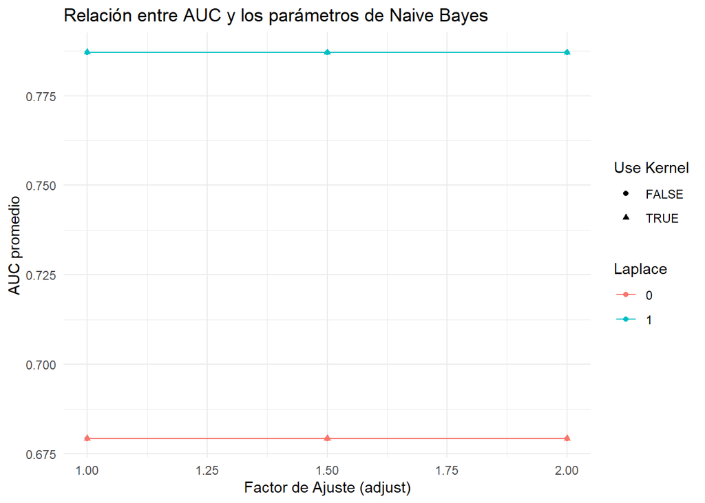

```r
# Generar gráficos ilustrativos
ggplot(results_summary, aes(x = adjust, y = AUC, color = as.factor(laplace), shape = as.factor(usekernel))) +
  geom_line() +
  geom_point() +
  labs(title = "Relación entre AUC y los parámetros de Naive Bayes",
       x = "Factor de Ajuste (adjust)",
       y = "AUC promedio",
       color = "Laplace",
       shape = "Use Kernel") +
  theme_minimal()
```

```r
# Entrenar el modelo final con la mejor combinación de parámetros y variables en todo el conjunto de datos
final_formula <- as.formula(paste("ESTADO_ACTUAL_BIN ~", paste(best_variables, collapse = " + ")))
modelo_final <- naiveBayes(final_formula, data=datos_cancer_def,
                           laplace=best_params$laplace,
                           usekernel=best_params$usekernel,
                           adjust=best_params$adjust)

# Evaluar el modelo final
pred_final <- predict(modelo_final, newdata=datos_cancer_def, type="raw")[,2]
auc_final <- auc(as.numeric(datos_cancer_def$ESTADO_ACTUAL_BIN), pred_final)

print(paste("AUC del modelo final:", auc_final))
```

```
## [1] "AUC del modelo final: 0.917147707979627"
```

## 4.14 5x2 Random Forest. chi_squared

Consiste en la combinación de muchos árboles de decisión individuales. Cada árbol en el bosque es entrenado con un subconjunto aleatorio del conjunto de datos original, y cada nodo del árbol considera solo un subconjunto aleatorio de las características para dividirse.

Parámetros utilizados:

- ntree: Representa la cantidad de árboles de decisión que se construirán en el bosque. Más árboles generalmente conducen a una mejor precisión del modelo porque agregan estabilidad y reducen el riesgo de sobreajuste
- mtry: Número de características aleatorias que se consideran para dividir en cada nodo de un árbol.
- maxnodes: Número maximo de nodos terminales que puede tener cada árbol.

```r
library(randomForest)
library(caret)
library(pROC)
library(ggplot2)
library(dplyr)
library(FSelector)

# Convertir la variable objetivo a factor si no lo está
datos_cancer_def$ESTADO_ACTUAL_BIN <- as.factor(datos_cancer_def$ESTADO_ACTUAL_BIN)

# Definir el rango de búsqueda de los parámetros
ntree_values <- c(100, 200, 500)
mtry_values <- seq(2, ncol(datos_cancer_def) - 1, by = 2)
maxnodes_values <- c(5, 10, 15, 50)

# Crear las combinaciones de los parámetros
parametros <- expand.grid(ntree = ntree_values, mtry = mtry_values, maxnodes = maxnodes_values)

# Crear las cajas de test y entrenamiento para el outer-loop
set.seed(123)
folds_outer <- createFolds(datos_cancer_def$ESTADO_ACTUAL_BIN, k = 5)

# Inicializar la matriz para almacenar los resultados del outer-loop
results <- data.frame(ntree = integer(), mtry = integer(), maxnodes = integer(), AUC = numeric(), fold = integer(), variables = character())

# Realizar la validación cruzada 5x2
# Outer-loop
for(i in 1:5){
  # Obtener índices para entrenamiento y prueba en el outer-loop
  test_indices_outer <- folds_outer[[i]]
  train_data_outer <- datos_cancer_def[-test_indices_outer, ]
  test_data_outer <- datos_cancer_def[test_indices_outer, ]

  # Crear las cajas de validación y entrenamiento para el inner-loop
  folds_inner <- createFolds(train_data_outer$ESTADO_ACTUAL_BIN, k = 2)

  best_inner_result <- NULL
  # Selección de variables usando el método de chi-cuadrado
  weights <- chi.squared(ESTADO_ACTUAL_BIN ~ ., data = train_data_outer)
  top_vars <- cutoff.k(weights, 5)  # Seleccionar las 5 mejores variables

  # Inner-loop
  for(j in 1:2){
    # Separar los datos en conjuntos de entrenamiento y validación
    val_indices_inner <- folds_inner[[j]]
    train_data_inner <- train_data_outer[-val_indices_inner, ]
    val_data_inner <- train_data_outer[val_indices_inner, ]

    # Crear fórmula con las variables seleccionadas
    formula <- as.formula(paste("ESTADO_ACTUAL_BIN ~", paste(top_vars, collapse = " + ")))

    # Ajustar el modelo para cada combinación de parámetros
    for(k in 1:nrow(parametros)){
      # Entrenar el modelo Random Forest con la combinación de parámetros
      modelo <- randomForest(formula, data = train_data_inner,
                             ntree = parametros$ntree[k],
                             mtry = parametros$mtry[k],
                             maxnodes = parametros$maxnodes[k])

      # Predecir en los datos de validación
      pred <- predict(modelo, newdata = val_data_inner, type = "prob")[,2]

      # Calcular el AUC
      auc_value <- auc(as.numeric(val_data_inner$ESTADO_ACTUAL_BIN), pred)

      # Almacenar los resultados
      results <- rbind(results, data.frame(ntree = parametros$ntree[k],
                                           mtry = parametros$mtry[k],
                                           maxnodes = parametros$maxnodes[k],
                                           AUC = auc_value, fold = i, variables = paste(top_vars, collapse = ", ")))

      # Guardar el mejor resultado del inner-loop
      if (is.null(best_inner_result) || auc_value > best_inner_result$AUC) {
        best_inner_result <- data.frame(ntree = parametros$ntree[k],
                                        mtry = parametros$mtry[k],
                                        maxnodes = parametros$maxnodes[k],
                                        AUC = auc_value, fold = i, variables = paste(top_vars, collapse = ", "))
      }
    }
  }

  # Entrenar el modelo en el outer-loop con los mejores parámetros y variables del inner-loop
  best_vars <- unlist(strsplit(best_inner_result$variables, ", "))
  final_formula <- as.formula(paste("ESTADO_ACTUAL_BIN ~", paste(best_vars, collapse = " + ")))

  modelo_final <- randomForest(final_formula, data=train_data_outer,
                               ntree=best_inner_result$ntree,
                               mtry=best_inner_result$mtry,
                               maxnodes=best_inner_result$maxnodes)

  # Evaluar el modelo en los datos de prueba del outer-loop
  pred_outer <- predict(modelo_final, newdata=test_data_outer, type="prob")[,2]
  auc_outer <- auc(as.numeric(test_data_outer$ESTADO_ACTUAL_BIN), pred_outer)

  # Almacenar el AUC del outer-loop
  results <- rbind(results, data.frame(ntree = best_inner_result$ntree,
                                       mtry = best_inner_result$mtry,
                                       maxnodes = best_inner_result$maxnodes,
                                       AUC = auc_outer,
                                       fold = i, variables = best_inner_result$variables))
}

# Calcular el promedio del AUC para cada combinación de parámetros
results_summary <- aggregate(AUC ~ ntree + mtry + maxnodes, data = results, FUN = mean)

# Mostrar la tabla de resumen
print(results_summary)
```

```
##    ntree mtry maxnodes       AUC
## 1    100    2        5 0.8094326
## 2    200    2        5 0.8080837
## 3    500    2        5 0.8330069
## 4    100    4        5 0.8092742
## 5    200    4        5 0.8058708
## 6    500    4        5 0.8297283
## 7    100    6        5 0.7692100
## 8    200    6        5 0.8123368
## 9    500    6        5 0.8258881
## 10   100    8        5 0.7842790
## 11   200    8        5 0.8098310
## 12   500    8        5 0.8220622
## 13   100   10        5 0.7698877
## 14   200   10        5 0.8441297
```

[output cut: 58 more lines]

```r
# Identificar la mejor combinación de parámetros
best_params <- results_summary[which.max(results_summary$AUC), ]
print(best_params)
```

```
##    ntree mtry maxnodes       AUC
## 14   200   10        5 0.8441297
```

```r
# Obtener las mejores variables asociadas a los mejores parámetros
best_result <- results[which.max(results$AUC), ]
best_iteration <- best_result$fold
best_variables <- strsplit(best_result$variables, ", ")[[1]]

print(paste("Mejores variables:", paste(best_variables, collapse = ", ")))
```

```
## [1] "Mejores variables: YEAR_DIAG, EDAD_DCO_CAT, ESTADIO_CAT, FENOTIPO, GANGLIOS"
```

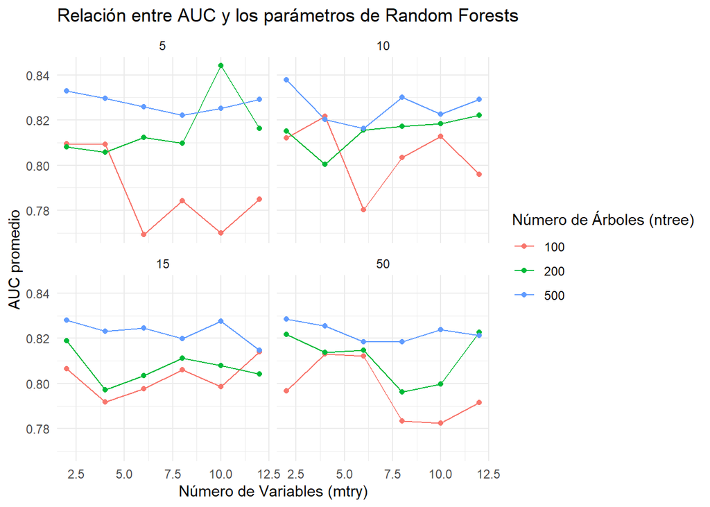

```r
# Generar gráficos ilustrativos
ggplot(results_summary, aes(x = mtry, y = AUC, color = as.factor(ntree))) +
  geom_line() +
  geom_point() +
  facet_wrap(~ maxnodes) +
  labs(title = "Relación entre AUC y los parámetros de Random Forests",
       x = "Número de Variables (mtry)",
       y = "AUC promedio",
       color = "Número de Árboles (ntree)") +
  theme_minimal()
```

```r
# Entrenar el modelo final con la mejor combinación de parámetros y variables en todo el conjunto de datos
final_formula <- as.formula(paste("ESTADO_ACTUAL_BIN ~", paste(best_variables, collapse = " + ")))
modelo_final_forest_chi <- randomForest(final_formula, data=datos_cancer_def,
                             ntree=best_params$ntree,
                             mtry=best_params$mtry,
                             maxnodes=best_params$maxnodes)
save(modelo_final_forest_chi, file = "modelo_final_forest_chi.RData")
# Evaluar el modelo final
pred_final <- predict(modelo_final_forest_chi, newdata=datos_cancer_def, type="prob")[,2]
auc_final <- auc(as.numeric(datos_cancer_def$ESTADO_ACTUAL_BIN), pred_final)

print(paste("AUC del modelo final:", auc_final))
```

```
## [1] "AUC del modelo final: 0.943520090548953"
```

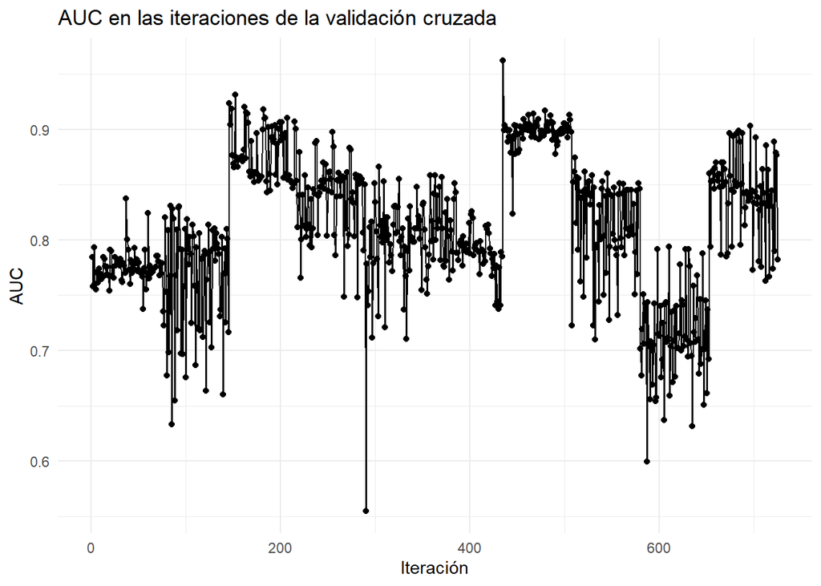

```r
# Generar gráfico del AUC
ggplot(results, aes(x = 1:nrow(results), y = AUC)) +
  geom_line() +
  geom_point() +
  labs(title = "AUC en las iteraciones de la validación cruzada",
       x = "Iteración",
       y = "AUC") +
  theme_minimal()
```

También se esperaba que el mejor modelo saliera con un ntree grande, por lo comentado en la definición de ntree.

Un número muy alto de nodos provoca un sobreajuste, es por eso que es coherente que el mejor resultado tenga maxnode=5. Cuando los árboles son más simples tienen mejores resultados generalmente.

Mejor modelo: ntree=200, mtry=10, maxnodes=5 y AUC=0.84

Este modelo con este filtrado se podría tomar como candidato para la aplicación, ya que ha sido el más consistente brindando el AUC mejor y del modelo final más parecidos hasta ahora.

## 4.15 5x2 Random Forest. stepAIC

```r
library(randomForest)
library(caret)
library(pROC)
library(ggplot2)
library(dplyr)
library(MASS)

# Convertir la variable objetivo a factor si no lo está
datos_cancer_def$ESTADO_ACTUAL_BIN <- as.factor(datos_cancer_def$ESTADO_ACTUAL_BIN)

# Definir el rango de búsqueda de los parámetros
ntree_values <- c(100, 200, 500)
mtry_values <- seq(2, ncol(datos_cancer_def) - 1, by = 2)
maxnodes_values <- c(5, 10, 15, 20)

# Crear las combinaciones de los parámetros
parametros <- expand.grid(ntree = ntree_values, mtry = mtry_values, maxnodes = maxnodes_values)

# Crear las cajas de test y entrenamiento para el outer-loop
set.seed(123)
folds_outer <- createFolds(datos_cancer_def$ESTADO_ACTUAL_BIN, k = 5)

# Inicializar la matriz para almacenar los resultados del outer-loop
results <- data.frame(ntree = integer(), mtry = integer(), maxnodes = integer(), AUC = numeric(), fold = integer(), variables = character())

# Realizar la validación cruzada 5x2
# Outer-loop
for(i in 1:5){
  # Obtener índices para entrenamiento y prueba en el outer-loop
  test_indices_outer <- folds_outer[[i]]
  train_data_outer <- datos_cancer_def[-test_indices_outer, ]
  test_data_outer <- datos_cancer_def[test_indices_outer, ]

  # Selección de variables usando stepAIC (backward)
  full_model <- glm(ESTADO_ACTUAL_BIN ~ ., data = train_data_outer, family = binomial)
  step_model <- stepAIC(full_model, direction = "backward", trace = FALSE)
  top_vars <- names(step_model$model)[-1]  # Seleccionar las mejores variables

  # Crear las cajas de validación y entrenamiento para el inner-loop
  folds_inner <- createFolds(train_data_outer$ESTADO_ACTUAL_BIN, k = 2)

  best_inner_result <- NULL

  # Inner-loop
  for(j in 1:2){
    # Separar los datos en conjuntos de entrenamiento y validación
    val_indices_inner <- folds_inner[[j]]
    train_data_inner <- train_data_outer[-val_indices_inner, ]
    val_data_inner <- train_data_outer[val_indices_inner, ]

    # Crear fórmula con las variables seleccionadas
    formula <- as.formula(paste("ESTADO_ACTUAL_BIN ~", paste(top_vars, collapse = " + ")))

    # Ajustar el modelo para cada combinación de parámetros
    for(k in 1:nrow(parametros)){
      # Entrenar el modelo Random Forest con la combinación de parámetros
      modelo <- randomForest(formula, data = train_data_inner,
                             ntree = parametros$ntree[k],
                             mtry = parametros$mtry[k],
                             maxnodes = parametros$maxnodes[k])

      # Predecir en los datos de validación
      pred <- predict(modelo, newdata = val_data_inner, type = "prob")[,2]

      # Calcular el AUC
      auc_value <- auc(as.numeric(val_data_inner$ESTADO_ACTUAL_BIN), pred)

      # Almacenar los resultados
      results <- rbind(results, data.frame(ntree = parametros$ntree[k],
                                           mtry = parametros$mtry[k],
                                           maxnodes = parametros$maxnodes[k],
                                           AUC = auc_value, fold = i, variables = paste(top_vars, collapse = ", ")))

      # Guardar el mejor resultado del inner-loop
      if (is.null(best_inner_result) || auc_value > best_inner_result$AUC) {
        best_inner_result <- data.frame(ntree = parametros$ntree[k],
                                        mtry = parametros$mtry[k],
                                        maxnodes = parametros$maxnodes[k],
                                        AUC = auc_value, fold = i, variables = paste(top_vars, collapse = ", "))
      }
    }
  }

  # Entrenar el modelo en el outer-loop con los mejores parámetros y variables del inner-loop
  best_vars <- unlist(strsplit(best_inner_result$variables, ", "))
  final_formula <- as.formula(paste("ESTADO_ACTUAL_BIN ~", paste(best_vars, collapse = " + ")))

  modelo_final <- randomForest(final_formula, data=train_data_outer,
                               ntree=best_inner_result$ntree,
                               mtry=best_inner_result$mtry,
                               maxnodes=best_inner_result$maxnodes)

  # Evaluar el modelo en los datos de prueba del outer-loop
  pred_outer <- predict(modelo_final, newdata=test_data_outer, type="prob")[,2]
  auc_outer <- auc(as.numeric(test_data_outer$ESTADO_ACTUAL_BIN), pred_outer)

  # Almacenar el AUC del outer-loop
  results <- rbind(results, data.frame(ntree = best_inner_result$ntree,
                                       mtry = best_inner_result$mtry,
                                       maxnodes = best_inner_result$maxnodes,
                                       AUC = auc_outer,
                                       fold = i, variables = best_inner_result$variables))
}

# Calcular el promedio del AUC para cada combinación de parámetros
results_summary <- aggregate(AUC ~ ntree + mtry + maxnodes, data = results, FUN = mean)

# Mostrar la tabla de resumen
print(results_summary)
```

```
##    ntree mtry maxnodes       AUC
## 1    100    2        5 0.7660426
## 2    200    2        5 0.7681836
## 3    500    2        5 0.7840486
## 4    100    4        5 0.7677659
## 5    200    4        5 0.8106087
## 6    500    4        5 0.7844706
## 7    100    6        5 0.7580383
## 8    200    6        5 0.7730847
## 9    500    6        5 0.7901114
## 10   100    8        5 0.7625336
## 11   200    8        5 0.7775298
## 12   500    8        5 0.7989007
## 13   100   10        5 0.7647753
## 14   200   10        5 0.7716350
```

[output cut: 58 more lines]

```r
# Identificar la mejor combinación de parámetros
best_params <- results_summary[which.max(results_summary$AUC), ]
print(best_params)
```

```
##    ntree mtry maxnodes       AUC
## 39   500    2       15 0.8154426
```

```r
# Obtener las mejores variables asociadas a los mejores parámetros
best_result <- results[which.max(results$AUC), ]
best_iteration <- best_result$fold
best_variables <- strsplit(best_result$variables, ", ")[[1]]

print(paste("Mejores variables:", paste(best_variables, collapse = ", ")))
```

```
## [1] "Mejores variables: MENOP, FENOTIPO, YEAR_DIAG, ESTADIO_CAT"
```

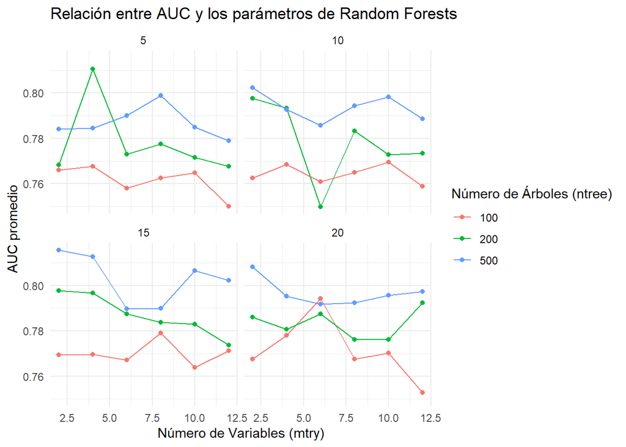

```r
# Generar gráficos ilustrativos
ggplot(results_summary, aes(x = mtry, y = AUC, color = as.factor(ntree))) +
  geom_line() +
  geom_point() +
  facet_wrap(~ maxnodes) +
  labs(title = "Relación entre AUC y los parámetros de Random Forests",
       x = "Número de Variables (mtry)",
       y = "AUC promedio",
       color = "Número de Árboles (ntree)") +
  theme_minimal()
```

```r
# Entrenar el modelo final con la mejor combinación de parámetros y variables en todo el conjunto de datos
final_formula <- as.formula(paste("ESTADO_ACTUAL_BIN ~", paste(best_variables, collapse = " + ")))
modelo_final <- randomForest(final_formula, data=datos_cancer_def,
                             ntree=best_params$ntree,
                             mtry=best_params$mtry,
                             maxnodes=best_params$maxnodes)

# Evaluar el modelo final
pred_final <- predict(modelo_final, newdata=datos_cancer_def, type="prob")[,2]
auc_final <- auc(as.numeric(datos_cancer_def$ESTADO_ACTUAL_BIN), pred_final)

print(paste("AUC del modelo final:", auc_final))
```

```
## [1] "AUC del modelo final: 0.967741935483871"
```

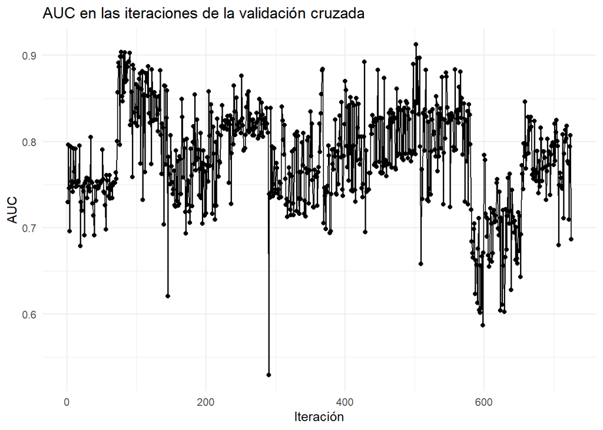

```r
# Generar gráfico del AUC
ggplot(results, aes(x = 1:nrow(results), y = AUC)) +
  geom_line() +
  geom_point() +
  labs(title = "AUC en las iteraciones de la validación cruzada",
       x = "Iteración",
       y = "AUC") +
  theme_minimal()
```

En este caso los resultados del mejor modelo era lo que nos podríamos llegar a esperar sobre mtry y ntree, pero maxnodes no debería ser tan alto, ya que puede capturar demasiado ruido del conjunto de datos. El rendimiento con stepAIC disminuye con respecto a chi_cuadrado, por lo que escogeremos chi_cuadrado en este caso. Los resultados respecto a todas las combinaciones son similares y tendrían la misma justificación que los anteriores, por lo que la diferencia radica en las variables, que no aportan información suficiente al modelo como para clasificar mejor que las variables de chi_cuadrado.

Mejor modelo: ntree=500, mtry=2, maxnodes=15 y AUC = 0.81

## 4.16 5x2 Adaboost. chi_squared

Algoritmo de aprendizaje automático que se utiliza principalmente para mejorar la precisión de los modelos de clasificación. Es parte de métodos llamados boosting, que combinan múltiples modelos débiles para crear un modelo fuerte y robusto.

Parámetros utilizados:

- mstop: Es el número de iteraciones de boosting que se realizarán durante el entrenamiento del modelo. Cada iteración implica la adición de un nuevo clasificador débil (en el caso de glmboost, esto sería la adición de un modelo lineal generalizado) que intenta corregir los errores cometidos por los clasificadores anteriores. Cuanto mayor sea el número de iteraciones puede mejorar la precisión, pero también puede acabar sobreajustando el modelo si es demasiado alto.
- learningrate: Controla el nivel de aprendizaje del modelo,reduciendo la contribución de cada clasificador débil. Valores más bajos de learning_rate provoca que se requieran más iteraciones para notar un cambio significativo en su rendimiento para clasificar ESTADO_ACTUAL_BIN.

En este caso utilizamos el modelo de regresión logística (glm) aplicando boosting.

```r
library(mboost)
library(caret)
library(pROC)
library(ggplot2)
library(dplyr)
library(FSelector)

# Convertir la variable objetivo a factor si no lo está
datos_cancer_def$ESTADO_ACTUAL_BIN <- as.factor(datos_cancer_def$ESTADO_ACTUAL_BIN)

# Definir el rango de búsqueda de los parámetros
mstop_values <- c(1, 50, 100, 150)
learning_rate_values <- c(0.001,0.01, 0.1, 0.5)

# Crear las combinaciones de los parámetros
parametros <- expand.grid(mstop = mstop_values, learning_rate = learning_rate_values)

# Crear las cajas de test y entrenamiento para el outer-loop
set.seed(123)
folds_outer <- createFolds(datos_cancer_def$ESTADO_ACTUAL_BIN, k = 5)

# Inicializar la matriz para almacenar los resultados del outer-loop
results <- data.frame(mstop = integer(), learning_rate = numeric(), AUC = numeric(), fold = integer(), variables = character())

# Realizar la validación cruzada 5x2
# Outer-loop
for(i in 1:5){
  # Obtener índices para entrenamiento y prueba en el outer-loop
  test_indices_outer <- folds_outer[[i]]
  train_data_outer <- datos_cancer_def[-test_indices_outer, ]
  test_data_outer <- datos_cancer_def[test_indices_outer, ]

  # Crear las cajas de validación y entrenamiento para el inner-loop
  folds_inner <- createFolds(train_data_outer$ESTADO_ACTUAL_BIN, k = 2)

  best_inner_result <- NULL
  # Selección de variables usando el método de chi-cuadrado
  weights <- chi.squared(ESTADO_ACTUAL_BIN ~ ., data = train_data_outer)
  top_vars <- cutoff.k(weights, 5)  # Seleccionar las 5 mejores variables
  # Inner-loop
  for(j in 1:2){
    # Separar los datos en conjuntos de entrenamiento y validación
    val_indices_inner <- folds_inner[[j]]
    train_data_inner <- train_data_outer[-val_indices_inner, ]
    val_data_inner <- train_data_outer[val_indices_inner, ]



    # Crear fórmula con las variables seleccionadas
    formula <- as.formula(paste("ESTADO_ACTUAL_BIN ~", paste(top_vars, collapse = " + ")))

    # Ajustar el modelo para cada combinación de parámetros
    for(k in 1:nrow(parametros)){
      # Entrenar el modelo AdaBoost con la combinación de parámetros
      modelo <- glmboost(formula, data = train_data_inner,
                         family = Binomial(),
                         control = boost_control(mstop = parametros$mstop[k], nu = parametros$learning_rate[k]))

      # Predecir en los datos de validación
      pred <- predict(modelo, newdata = val_data_inner, type = "response")

      # Calcular el AUC
      auc_value <- auc(as.numeric(val_data_inner$ESTADO_ACTUAL_BIN), pred)

      # Almacenar los resultados
      results <- rbind(results, data.frame(mstop = parametros$mstop[k],
                                           learning_rate = parametros$learning_rate[k],
                                           AUC = auc_value, fold = i, variables = paste(top_vars, collapse = ", ")))

      # Guardar el mejor resultado del inner-loop
      if (is.null(best_inner_result) || auc_value > best_inner_result$AUC) {
        best_inner_result <- data.frame(mstop = parametros$mstop[k],
                                        learning_rate = parametros$learning_rate[k],
                                        AUC = auc_value, fold = i, variables = paste(top_vars, collapse = ", "))
      }
    }
  }

  # Entrenar el modelo en el outer-loop con los mejores parámetros y variables del inner-loop
  best_vars <- unlist(strsplit(best_inner_result$variables, ", "))
  final_formula <- as.formula(paste("ESTADO_ACTUAL_BIN ~", paste(best_vars, collapse = " + ")))

  modelo_final <- glmboost(final_formula, data=train_data_outer,
                           family = Binomial(),
                           control = boost_control(mstop = best_inner_result$mstop, nu = best_inner_result$learning_rate))

  # Evaluar el modelo en los datos de prueba del outer-loop
  pred_outer <- predict(modelo_final, newdata=test_data_outer, type="response")
  auc_outer <- auc(as.numeric(test_data_outer$ESTADO_ACTUAL_BIN), pred_outer)

  # Almacenar el AUC del outer-loop
  results <- rbind(results, data.frame(mstop = best_inner_result$mstop,
                                       learning_rate = best_inner_result$learning_rate,
                                       AUC = auc_outer, fold = i, variables = best_inner_result$variables))
}

# Calcular el promedio del AUC para cada combinación de parámetros
results_summary <- aggregate(AUC ~ mstop + learning_rate, data = results, FUN = mean)

# Mostrar la tabla de resumen
print(results_summary)
```

```
##    mstop learning_rate       AUC
## 1      1         0.001 0.5224366
## 2     50         0.001 0.5188412
## 3    100         0.001 0.5354407
## 4    150         0.001 0.5354407
## 5      1         0.010 0.5224366
## 6     50         0.010 0.5333669
## 7    100         0.010 0.5372168
## 8    150         0.010 0.5678571
## 9      1         0.100 0.5224366
## 10    50         0.100 0.6486415
## 11   100         0.100 0.6868136
## 12   150         0.100 0.7081733
## 13     1         0.500 0.5224366
## 14    50         0.500 0.7127976
## 15   100         0.500 0.7184707
## 16   150         0.500 0.7375919
```

```r
# Identificar la mejor combinación de parámetros
best_params <- results_summary[which.max(results_summary$AUC), ]
print(best_params)
```

```
##    mstop learning_rate       AUC
## 16   150           0.5 0.7375919
```

```r
# Obtener las mejores variables asociadas a los mejores parámetros
best_result <- results[which.max(results$AUC), ]
best_iteration <- best_result$fold
best_variables <- strsplit(best_result$variables, ", ")[[1]]

print(paste("Mejores variables:", paste(best_variables, collapse = ", ")))
```

```
## [1] "Mejores variables: YEAR_DIAG, EDAD_DCO_CAT, ESTADIO_CAT, FENOTIPO, GANGLIOS"
```

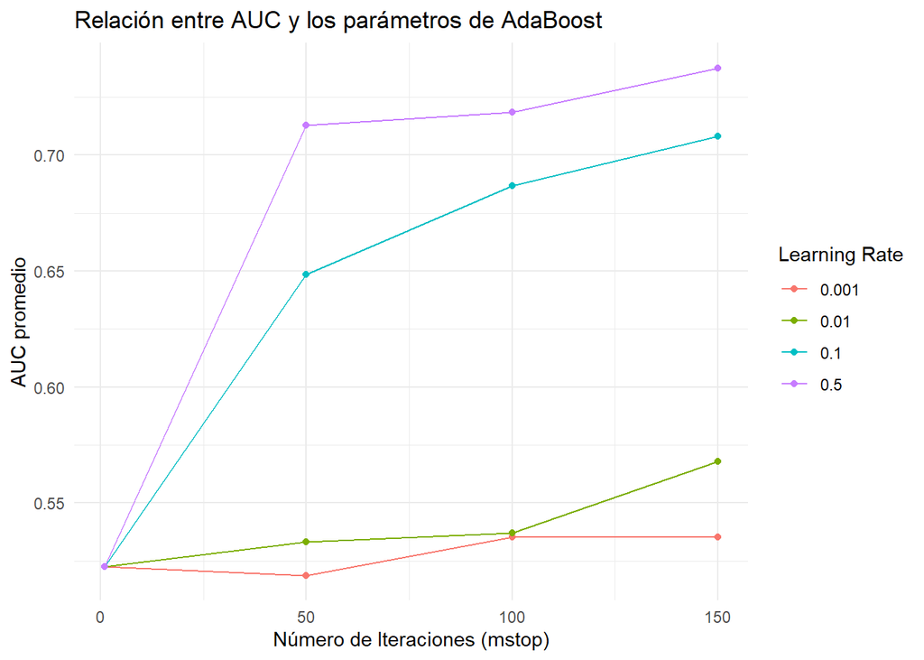

```r
# Generar gráficos ilustrativos
ggplot(results_summary, aes(x = mstop, y = AUC, color = as.factor(learning_rate))) +
  geom_line() +
  geom_point() +
  labs(title = "Relación entre AUC y los parámetros de AdaBoost",
       x = "Número de Iteraciones (mstop)",
       y = "AUC promedio",
       color = "Learning Rate") +
  theme_minimal()
```

```r
# Entrenar el modelo final con la mejor combinación de parámetros y variables en todo el conjunto de datos
final_formula <- as.formula(paste("ESTADO_ACTUAL_BIN ~", paste(best_variables, collapse = " + ")))
modelo_final_adaboost_chi <- glmboost(final_formula, data=datos_cancer_def,
                         family = Binomial(),
                         control = boost_control(mstop = best_params$mstop, nu = best_params$learning_rate))
save(modelo_final_adaboost_chi, file = "modelo_final_adaboost_chi.RData")
# Evaluar el modelo final
pred_final <- predict(modelo_final_adaboost_chi, newdata=datos_cancer_def, type="response")
auc_final <- auc(as.numeric(datos_cancer_def$ESTADO_ACTUAL_BIN), pred_final)

print(paste("AUC del modelo final:", auc_final))
```

```
## [1] "AUC del modelo final: 0.932258064516129"
```

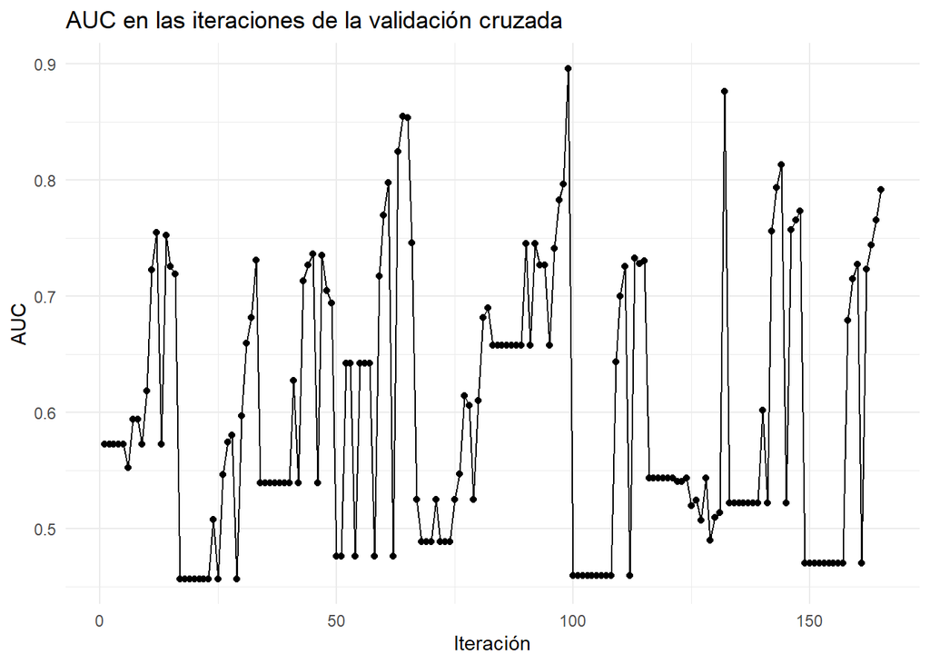

```r
# Generar gráfico del AUC
ggplot(results, aes(x = 1:nrow(results), y = AUC)) +
  geom_line() +
  geom_point() +
  labs(title = "AUC en las iteraciones de la validación cruzada",
       x = "Iteración",
       y = "AUC") +
  theme_minimal()
```

El valor de learning rate del mejor modelo no era el que se esperaba, ya que es el valor menos restrictivo. Y aunque ayude a que el modelo se ajuste más rápidamente a los datos de entrenamiento, corrigiendo errores más efectivamente en cada iteración, también aumenta el riesgo de overfitting.

El mstop también era el esperado. Mayor número de iteraciones suele implicar más robustez y mejor precisión de los datos para que se vayan mejorando mediante la adición de otros modelo débiles del mismo tipo, para corregir errores de los anteriores.

## 4.17 5x2 Adaboost. Wrapper stepAIC

```r
library(mboost)
library(caret)
library(pROC)
library(ggplot2)
library(dplyr)
library(MASS)

# Convertir la variable objetivo a factor si no lo está
datos_cancer_def$ESTADO_ACTUAL_BIN <- as.factor(datos_cancer_def$ESTADO_ACTUAL_BIN)

# Definir el rango de búsqueda de los parámetros
mstop_values <- c(1, 50, 100, 150)
learning_rate_values <- c(0.001,0.01, 0.1, 0.5)

# Crear las combinaciones de los parámetros
parametros <- expand.grid(mstop = mstop_values, learning_rate = learning_rate_values)

# Crear las cajas de test y entrenamiento para el outer-loop
set.seed(123)
folds_outer <- createFolds(datos_cancer_def$ESTADO_ACTUAL_BIN, k = 5)

# Inicializar la matriz para almacenar los resultados del outer-loop
results <- data.frame(mstop = integer(), learning_rate = numeric(), AUC = numeric(), fold = integer(), variables = character())

# Realizar la validación cruzada 5x2
# Outer-loop
for(i in 1:5){
  # Obtener índices para entrenamiento y prueba en el outer-loop
  test_indices_outer <- folds_outer[[i]]
  train_data_outer <- datos_cancer_def[-test_indices_outer, ]
  test_data_outer <- datos_cancer_def[test_indices_outer, ]

  # Selección de variables usando stepAIC (backward)
  full_model <- glm(ESTADO_ACTUAL_BIN ~ ., data = train_data_outer, family = binomial)
  step_model <- stepAIC(full_model, direction = "backward", trace = FALSE)
  top_vars <- names(step_model$model)[-1]  # Seleccionar las mejores variables

  # Crear las cajas de validación y entrenamiento para el inner-loop
  folds_inner <- createFolds(train_data_outer$ESTADO_ACTUAL_BIN, k = 2)

  best_inner_result <- NULL

  # Inner-loop
  for(j in 1:2){
    # Separar los datos en conjuntos de entrenamiento y validación
    val_indices_inner <- folds_inner[[j]]
    train_data_inner <- train_data_outer[-val_indices_inner, ]
    val_data_inner <- train_data_outer[val_indices_inner, ]

    # Crear fórmula con las variables seleccionadas
    formula <- as.formula(paste("ESTADO_ACTUAL_BIN ~", paste(top_vars, collapse = " + ")))

    # Ajustar el modelo para cada combinación de parámetros
    for(k in 1:nrow(parametros)){
      # Entrenar el modelo AdaBoost con la combinación de parámetros
      modelo <- glmboost(formula, data = train_data_inner,
                         family = Binomial(),
                         control = boost_control(mstop = parametros$mstop[k], nu = parametros$learning_rate[k]))

      # Predecir en los datos de validación
      pred <- predict(modelo, newdata = val_data_inner, type = "response")

      # Calcular el AUC
      auc_value <- auc(as.numeric(val_data_inner$ESTADO_ACTUAL_BIN), pred)

      # Almacenar los resultados
      results <- rbind(results, data.frame(mstop = parametros$mstop[k],
                                           learning_rate = parametros$learning_rate[k],
                                           AUC = auc_value, fold = i, variables = paste(top_vars, collapse = ", ")))

      # Guardar el mejor resultado del inner-loop
      if (is.null(best_inner_result) || auc_value > best_inner_result$AUC) {
        best_inner_result <- data.frame(mstop = parametros$mstop[k],
                                        learning_rate = parametros$learning_rate[k],
                                        AUC = auc_value, fold = i, variables = paste(top_vars, collapse = ", "))
      }
    }
  }

  # Entrenar el modelo en el outer-loop con los mejores parámetros y variables del inner-loop
  best_vars <- unlist(strsplit(best_inner_result$variables, ", "))
  final_formula <- as.formula(paste("ESTADO_ACTUAL_BIN ~", paste(best_vars, collapse = " + ")))

  modelo_final <- glmboost(final_formula, data=train_data_outer,
                           family = Binomial(),
                           control = boost_control(mstop = best_inner_result$mstop, nu = best_inner_result$learning_rate))

  # Evaluar el modelo en los datos de prueba del outer-loop
  pred_outer <- predict(modelo_final, newdata=test_data_outer, type="response")
  auc_outer <- auc(as.numeric(test_data_outer$ESTADO_ACTUAL_BIN), pred_outer)

  # Almacenar el AUC del outer-loop
  results <- rbind(results, data.frame(mstop = best_inner_result$mstop,
                                       learning_rate = best_inner_result$learning_rate,
                                       AUC = auc_outer, fold = i, variables = best_inner_result$variables))
}

# Calcular el promedio del AUC para cada combinación de parámetros
results_summary <- aggregate(AUC ~ mstop + learning_rate, data = results, FUN = mean)

# Mostrar la tabla de resumen
print(results_summary)
```

```
##    mstop learning_rate       AUC
## 1      1         0.001 0.5282834
## 2     50         0.001 0.5246880
## 3    100         0.001 0.5412874
## 4    150         0.001 0.5412874
## 5      1         0.010 0.5282834
## 6     50         0.010 0.5487903
## 7    100         0.010 0.5526402
## 8    150         0.010 0.5702093
## 9      1         0.100 0.5282834
## 10    50         0.100 0.6446477
## 11   100         0.100 0.7053964
## 12   150         0.100 0.7028754
## 13     1         0.500 0.5282834
## 14    50         0.500 0.7107623
## 15   100         0.500 0.7531789
## 16   150         0.500 0.7463438
```

```r
# Identificar la mejor combinación de parámetros
best_params <- results_summary[which.max(results_summary$AUC), ]
print(best_params)
```

```
##    mstop learning_rate       AUC
## 15   100           0.5 0.7531789
```

```r
# Obtener las mejores variables asociadas a los mejores parámetros
best_result <- results[which.max(results$AUC), ]
best_iteration <- best_result$fold
best_variables <- strsplit(best_result$variables, ", ")[[1]]

print(paste("Mejores variables:", paste(best_variables, collapse = ", ")))
```

```
## [1] "Mejores variables: RP, GANGLIOS, EDAD_DCO_CAT, YEAR_DIAG, ESTADIO_CAT"
```

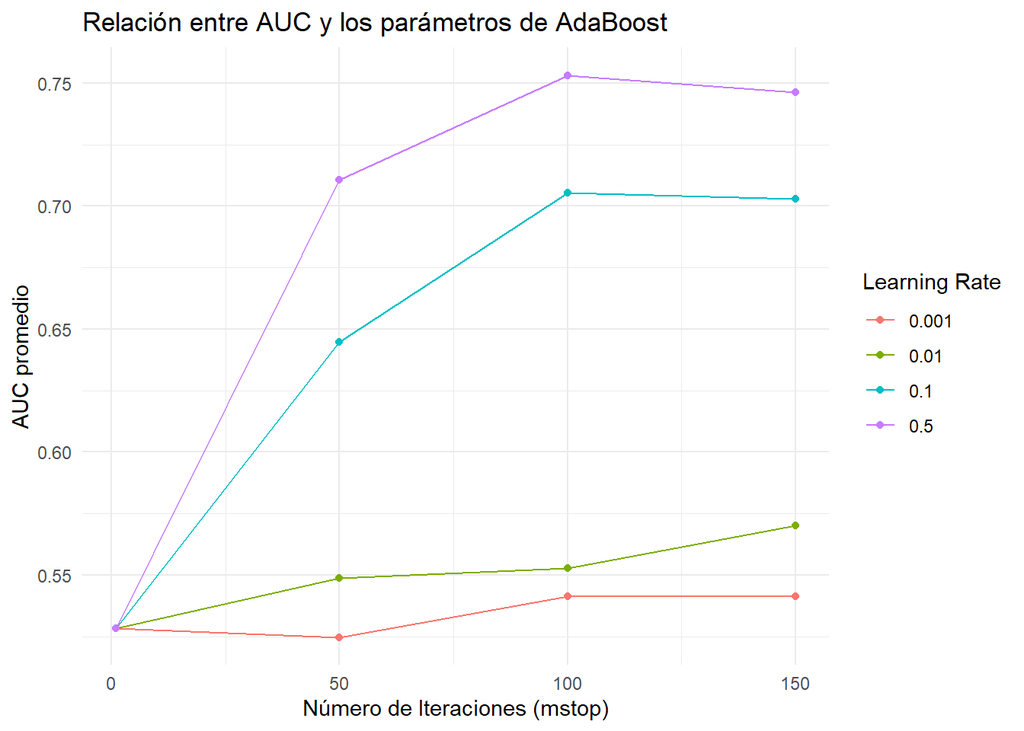

```r
# Generar gráficos ilustrativos
ggplot(results_summary, aes(x = mstop, y = AUC, color = as.factor(learning_rate))) +
  geom_line() +
  geom_point() +
  labs(title = "Relación entre AUC y los parámetros de AdaBoost",
       x = "Número de Iteraciones (mstop)",
       y = "AUC promedio",
       color = "Learning Rate") +
  theme_minimal()
```

```r
# Entrenar el modelo final con la mejor combinación de parámetros y variables en todo el conjunto de datos
final_formula <- as.formula(paste("ESTADO_ACTUAL_BIN ~", paste(best_variables, collapse = " + ")))
modelo_final <- glmboost(final_formula, data=datos_cancer_def,
                         family = Binomial(),
                         control = boost_control(mstop = best_params$mstop, nu = best_params$learning_rate))

# Evaluar el modelo final
pred_final <- predict(modelo_final, newdata=datos_cancer_def, type="response")
auc_final <- auc(as.numeric(datos_cancer_def$ESTADO_ACTUAL_BIN), pred_final)

print(paste("AUC del modelo final:", auc_final))
```

```
## [1] "AUC del modelo final: 0.92450481041313"
```

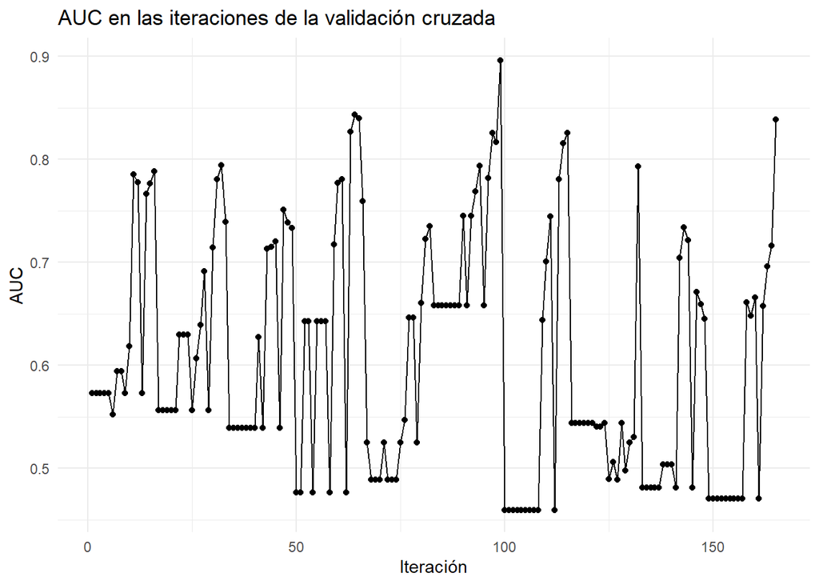

```r
# Generar gráfico del AUC
ggplot(results, aes(x = 1:nrow(results), y = AUC)) +
  geom_line() +
  geom_point() +
  labs(title = "AUC en las iteraciones de la validación cruzada",
       x = "Iteración",
       y = "AUC") +
  theme_minimal()
```

No hay una gran diferencia entre el rendimiento con chi_cuadrado y stepAIC en este caso, ya que la selección de variables es parecida y los parámetros escogidos también lo son.

En este caso stepAIC ofrece mejores resultados que chi_cuadrado.

## 4.18 Conclusión

Tras la ejecución de todos los modelos y analizado sus redimientos, podemos concluir que el dataset es decisivo cuando entrenamos los modelos. Al tratarse de un dataset desbalanceado no podíamos aspirar a grandes rendimientos, porque no tenemos sufiente informacion para hacer una clasificación satisfactoria de ESTADO_ACTUAL_BIN.

De entre todos los modelos ejecutados eligiría randomForest debido a su rendimiento y por como está diseñado el modelo. Cada árbol del bosque se entrena en una muestra diferente del conjunto de datos mediante el método de bootstrap (para cada árbol se proporciona una muestra del dataset y se entrena con esa muestra). Por lo que al promediar las predicciones de los árboles, el modelo reduce la varianza, lo que resulta en un modelo más robusto y menos susceptible a las fluctuaciones de los datos de entrenamiento.

Por lo que será con la que desplequemos la aplicación.

https://z4u3qf-juan0ignacio-soriano0mu0oz.shinyapps.io/aplicacion/